# XGBoost (consolidated version)

This notebook consolidates the evaluation of two fine-tuned XGBoost models for predicting hospital readmission and mortality. It prepares longitudinal data for survival analysis by eliminating immortal time bias. The workflow manages competing outcomes through Cause-Specific Hazard preparations. Finally, it constructs an evaluation grid to assess the model’s predictive capabilities for both events across defined time intervals.

Author

ags

Published

February 27, 2026

# Best predictors based on XGBOOST (combination)

## 0. Package loading and installation

```python
# Commented out IPython magic to ensure Python compatibility.
# For Jupyter/Colab notebooks
%reset -f
import gc
gc.collect()

import numpy as np
import pandas as pd
import time

#conda install -c conda-forge \
#    numpy \
#    scipy \
#    pandas \
#    pyarrow \
#    scikit-survival \
#    spyder \
#    lifelines

# conda install -c conda-forge fastparquet
# conda install -c conda-forge xgboost
# conda install -c conda-forge pytorch cpuonly
# conda install -c pytorch pytorch cpuonly
# conda install -c conda-forge matplotlib
# conda install -c conda-forge seaborn
# conda install spyder-notebook -c spyder-ide
# conda install notebook nbformat nbconvert
# conda install -c conda-forge xlsxwriter
# conda install -c conda-forge shap

# import subprocess, sys

# subprocess.check_call([
#     sys.executable,
#     "-m",
#     "pip",
#     "install",
#     "matplotlib"
# ])

# subprocess.check_call([
#     sys.executable,
#     "-m",
#     "pip",
#     "install",
#     "seaborn"
# ])

print("numpy:", np.__version__)


from sksurv.metrics import (
    concordance_index_ipcw,
    brier_score,
    integrated_brier_score
)
from sksurv.util import Surv

#Dput
def dput_df(df, digits=6):
    data = {
        "columns": list(df.columns),
        "data": [
            [round(x, digits) if isinstance(x, (float, np.floating)) else x
             for x in row]
            for row in df.to_numpy()
        ]
    }
    print(data)


#Glimpse function
def glimpse(df, max_width=80):
    print(f"Rows: {df.shape[0]} | Columns: {df.shape[1]}")
    for col in df.columns:
        dtype = df[col].dtype
        preview = df[col].astype(str).head(5).tolist()
        preview_str = ", ".join(preview)
        if len(preview_str) > max_width:
            preview_str = preview_str[:max_width] + "..."
        print(f"{col:<30} {str(dtype):<15} {preview_str}")
#Tabyl function
def tabyl(series):
    counts = series.value_counts(dropna=False)
    props = series.value_counts(normalize=True, dropna=False)
    return pd.DataFrame({"value": counts.index,
                         "n": counts.values,
                         "percent": props.values})
#clean_names
import re

def clean_names(df):
    """
    Mimic janitor::clean_names for pandas DataFrames.
    - Lowercase
    - Replace spaces and special chars with underscores
    - Remove non-alphanumeric/underscore
    """
    new_cols = []
    for col in df.columns:
        # lowercase
        col = col.lower()
        # replace spaces and special chars with underscore
        col = re.sub(r"[^\w]+", "_", col)
        # strip leading/trailing underscores
        col = col.strip("_")
        new_cols.append(col)
    df.columns = new_cols
    return df
```

## Load data

```python
from pathlib import Path

BASE_DIR = Path(
    r"G:\My Drive\Alvacast\SISTRAT 2023\data\20241015_out\pred1"
)

import pickle

with open(BASE_DIR / "imputations_list_jan26.pkl", "rb") as f:
    imputations_list_jan26 = pickle.load(f)

imputation_1 = pd.read_parquet(
    BASE_DIR / "imputation_1.parquet",
    engine="fastparquet"
)
```

```python
import pandas as pd

for i in range(1, 6):
    globals()[f"imputation_nodum_{i}"] = pd.read_parquet(
        BASE_DIR / f"imputation_nondum_{i}.parquet",
        engine="fastparquet"
    )
```

```python
from IPython.display import display, HTML
import io
import sys

def fold_output(title, func):
    buffer = io.StringIO()
    sys.stdout = buffer
    func()
    sys.stdout = sys.__stdout__

    html = f"""
    <details>
      <summary>{title}</summary>
      <pre>{buffer.getvalue()}</pre>
    </details>
    """
    display(HTML(html))


fold_output(
    "Show imputation_nodum_1 structure",
    lambda: imputation_nodum_1.info()
)

fold_output(
    "Show imputation_1 structure",
    lambda: imputation_1.info()
)
```

**Show imputation_nodum_1 structure**

```
RangeIndex: 88504 entries, 0 to 88503
Data columns (total 43 columns):
 #   Column                         Non-Null Count  Dtype
---  ------                         --------------  -----
 0   readmit_time_from_adm_m        88504 non-null  float64
 1   death_time_from_adm_m          88504 non-null  float64
 2   adm_age_rec3                   88504 non-null  float64
 3   porc_pobr                      88504 non-null  float64
 4   dit_m                          88504 non-null  float64
 5   sex_rec                        88504 non-null  object
 6   tenure_status_household        88504 non-null  object
 7   cohabitation                   88504 non-null  object
 8   sub_dep_icd10_status           88504 non-null  object
 9   any_violence                   88504 non-null  object
 10  prim_sub_freq_rec              88504 non-null  object
```

[output cut: 34 more lines]

**Show imputation_1 structure**

```
RangeIndex: 88504 entries, 0 to 88503
Data columns (total 78 columns):
 #   Column                                                              Non-Null Count  Dtype
---  ------                                                              --------------  -----
 0   readmit_time_from_adm_m                                             88504 non-null  float64
 1   death_time_from_adm_m                                               88504 non-null  float64
 2   adm_age_rec3                                                        88504 non-null  float64
 3   porc_pobr                                                           88504 non-null  float64
 4   dit_m                                                               88504 non-null  float64
 5   national_foreign                                                    88504 non-null  int32
 6   ethnicity                                                           88504 non-null  float64
 7   dg_psiq_cie_10_instudy                                              88504 non-null  bool
 8   dg_psiq_cie_10_dg                                                   88504 non-null  bool
 9   dx_f3_mood                                                          88504 non-null  int32
 10  dx_f6_personality                                                   88504 non-null  int32
```

[output cut: 69 more lines]

```python
from IPython.display import display, Markdown

if isinstance(imputations_list_jan26, list) and len(imputations_list_jan26) > 0:
    display(Markdown(f"**First element type:** `{type(imputations_list_jan26[0])}`"))

    if isinstance(imputations_list_jan26[0], dict):
        display(Markdown(f"**First element keys:** `{list(imputations_list_jan26[0].keys())}`"))

    elif isinstance(imputations_list_jan26[0], (pd.DataFrame, np.ndarray)):
        display(Markdown(f"**First element shape:** `{imputations_list_jan26[0].shape}`"))
```

**First element type:** `<class 'pandas.DataFrame'>`

**First element shape:** `(88504, 56)`

### Format data

Due to inconsistencies and structural heterogeneity across previously merged datasets, we decided not to proceed with a direct inspection and comparison of column names between the first imputed dataset from `imputations_list_jan26` (which likely included dummy-encoded variables) and `imputation_nodum_1` (which likely retained non–dummy-encoded variables).

Instead, we reconstructed the analytic datasets *de novo* using the most recent source files available in the original directory (`BASE_DIR`). Time-to-event variables were re-derived to ensure internal consistency. Variables that could introduce information leakage (e.g., time from admission) were excluded, and the center identifier variable was removed prior to modeling.

```python
#1.2. Build Surv objects from df_final
from IPython.display import display, Markdown
from sksurv.util import Surv

for i in range(1, 6):
    # Get the DataFrame
    df = globals()[f"imputation_nodum_{i}"]

    # Extract time and event arrays
    time_readm  = df["readmit_time_from_disch_m"].to_numpy()
    event_readm = (df["readmit_event"].to_numpy() == 1)
    time_death  = df["death_time_from_disch_m"].to_numpy()
    event_death = (df["death_event"].to_numpy() == 1)

    # Create survival objects
    y_surv_readm = Surv.from_arrays(event=event_readm, time=time_readm)
    y_surv_death = Surv.from_arrays(event=event_death, time=time_death)

    # Store in global variables (optional but matches your pattern)
    globals()[f"y_surv_readm_{i}"]  = y_surv_readm
    globals()[f"y_surv_death_{i}"]  = y_surv_death

    # Print info
    display(Markdown(f"\n--- Imputation {i} ---"))
    display(Markdown(
    f"**y_surv_readm dtype:** {y_surv_readm.dtype}  \n"
    f"**shape:** {y_surv_readm.shape}"
    ))
    display(Markdown(
    f"**y_surv_death dtype:** {y_surv_death.dtype}  \n"
    f"**shape:** {y_surv_death.shape}"
    ))
```

— Imputation 1 —

**y_surv_readm dtype:** [(‘event’, ‘?’), (‘time’, ‘<f8’)]  
**shape:** (88504,)

**y_surv_death dtype:** [(‘event’, ‘?’), (‘time’, ‘<f8’)]  
**shape:** (88504,)

— Imputation 2 —

**y_surv_readm dtype:** [(‘event’, ‘?’), (‘time’, ‘<f8’)]  
**shape:** (88504,)

**y_surv_death dtype:** [(‘event’, ‘?’), (‘time’, ‘<f8’)]  
**shape:** (88504,)

— Imputation 3 —

**y_surv_readm dtype:** [(‘event’, ‘?’), (‘time’, ‘<f8’)]  
**shape:** (88504,)

**y_surv_death dtype:** [(‘event’, ‘?’), (‘time’, ‘<f8’)]  
**shape:** (88504,)

— Imputation 4 —

**y_surv_readm dtype:** [(‘event’, ‘?’), (‘time’, ‘<f8’)]  
**shape:** (88504,)

**y_surv_death dtype:** [(‘event’, ‘?’), (‘time’, ‘<f8’)]  
**shape:** (88504,)

— Imputation 5 —

**y_surv_readm dtype:** [(‘event’, ‘?’), (‘time’, ‘<f8’)]  
**shape:** (88504,)

**y_surv_death dtype:** [(‘event’, ‘?’), (‘time’, ‘<f8’)]  
**shape:** (88504,)

```python
fold_output(
    "Show imputation_nodum_1 (newer database) glimpse",
    lambda: glimpse(imputation_nodum_1)
)
fold_output(
    "Show first db of imputations_list_jan26 (older) glimpse",
    lambda: glimpse(imputations_list_jan26[0])
)
```

**Show imputation_nodum_1 (newer database) glimpse**

```
Rows: 88504 | Columns: 43
readmit_time_from_adm_m        float64         84.93548387096774, 12.833333333333334, 13.733333333333333, 11.966666666666667, 1...
death_time_from_adm_m          float64         84.93548387096774, 87.16129032258064, 117.2258064516129, 98.93548387096774, 37.9...
adm_age_rec3                   float64         31.53, 20.61, 42.52, 60.61, 45.08
porc_pobr                      float64         0.175679117441177, 0.187835901975632, 0.130412444472313, 0.133759185671806, 0.08...
dit_m                          float64         15.967741935483872, 5.833333333333334, 0.4752688172043005, 6.966666666666667, 6....
sex_rec                        object          man, man, man, woman, man
tenure_status_household        object          stays temporarily with a relative, owner/transferred dwellings/pays dividends, s...
cohabitation                   object          alone, family of origin, with couple/children, with couple/children, family of o...
sub_dep_icd10_status           object          drug dependence, hazardous consumption, drug dependence, drug dependence, drug d...
any_violence                   object          0.No domestic violence/sex abuse, 0.No domestic violence/sex abuse, 0.No domesti...
prim_sub_freq_rec              object          2.2–6 days/wk, 3.Daily, 3.Daily, 3.Daily, 3.Daily
tr_outcome                     object          referral, dropout, adm discharge - rule violation/undet, dropout, completion
adm_motive                     object          sanitary sector, spontaneous consultation, sanitary sector, sanitary sector, spo...
first_sub_used                 object          alcohol, alcohol, alcohol, cocaine paste, alcohol
primary_sub_mod                object          alcohol, cocaine paste, cocaine paste, cocaine paste, cocaine paste
tipo_de_vivienda_rec2          object          other/unknown, formal housing, formal housing, formal housing, formal housing
national_foreign               int32           0, 0, 0, 0, 0
plan_type_corr                 object          pg-pab, pg-pab, pg-pr, m-pr, pg-pai
occupation_condition_corr24    object          unemployed, employed, employed, inactive, unemployed
marital_status_rec             object          single, single, single, married/cohabiting, single
urbanicity_cat                 object          3.Urban, 3.Urban, 3.Urban, 3.Urban, 3.Urban
ed_attainment_corr             object          2-Completed high school or less, 3-Completed primary school or less, 2-Completed...
evaluacindelprocesoteraputico  object          logro alto, logro minimo, logro minimo, logro minimo, logro alto
eva_consumo                    object          logro alto, logro minimo, logro minimo, logro intermedio, logro alto
eva_fam                        object          logro intermedio, logro minimo, logro minimo, logro intermedio, logro alto
eva_relinterp                  object          logro alto, logro minimo, logro minimo, logro intermedio, logro alto
eva_ocupacion                  object          logro alto, logro minimo, logro minimo, logro minimo, logro intermedio
eva_sm                         object          logro intermedio, logro minimo, logro minimo, logro intermedio, logro minimo
eva_fisica                     object          logro alto, logro minimo, logro intermedio, logro intermedio, logro alto
eva_transgnorma                object          logro alto, logro minimo, logro minimo, logro minimo, logro intermedio
ethnicity                      float64         0.0, 0.0, 0.0, 0.0, 0.0
dg_psiq_cie_10_instudy         bool            False, False, True, False, False
dg_psiq_cie_10_dg              bool            True, False, False, True, False
dx_f3_mood                     int32           0, 0, 0, 0, 0
dx_f6_personality              int32           0, 0, 0, 1, 0
dx_f_any_severe_mental         bool            True, False, False, False, False
any_phys_dx                    bool            False, False, False, True, False
polysubstance_strict           int32           0, 1, 1, 1, 1
readmit_event                  float64         0.0, 1.0, 1.0, 1.0, 1.0
death_event                    int32           0, 0, 0, 0, 0
readmit_time_from_disch_m      float64         68.96774193548387, 7.0, 13.258064516129032, 5.0, 7.354838709677419
death_time_from_disch_m        float64         68.96774193548387, 81.3225806451613, 116.74193548387096, 91.96774193548387, 31.0...
center_id                      object          330, 489, 341, 411, 176
```

**Show first db of imputations_list_jan26 (older) glimpse**

```
Rows: 88504 | Columns: 56
adm_age_rec3                   float64         31.53, 20.61, 42.52, 60.61, 45.08
porc_pobr                      float64         0.175679117441177, 0.187835901975632, 0.130412444472313, 0.133759185671806, 0.08...
dit_m                          float64         15.967741935483872, 5.833333333333334, 0.4752688172043005, 6.966666666666667, 6....
tenure_status_household        int64           3, 0, 3, 0, 3
prim_sub_freq_rec              int64           1, 2, 2, 2, 2
national_foreign               int32           0, 0, 0, 0, 0
urbanicity_cat                 int64           0, 0, 0, 0, 0
ed_attainment_corr             float64         1.0, 2.0, 1.0, 1.0, 2.0
evaluacindelprocesoteraputico  int64           0, 2, 2, 2, 0
eva_consumo                    int64           0, 2, 2, 1, 0
eva_fam                        int64           1, 2, 2, 1, 0
eva_relinterp                  int64           0, 2, 2, 1, 0
eva_ocupacion                  int64           0, 2, 2, 2, 1
eva_sm                         int64           1, 2, 2, 1, 2
eva_fisica                     int64           0, 2, 1, 1, 0
eva_transgnorma                int64           0, 2, 2, 2, 1
ethnicity                      float64         0.0, 0.0, 0.0, 0.0, 0.0
dg_psiq_cie_10_instudy         bool            False, False, True, False, False
dg_psiq_cie_10_dg              bool            True, False, False, True, False
dx_f3_mood                     int32           0, 0, 0, 0, 0
dx_f6_personality              int32           0, 0, 0, 1, 0
dx_f_any_severe_mental         bool            True, False, False, False, False
any_phys_dx                    bool            False, False, False, True, False
polysubstance_strict           int32           0, 1, 1, 1, 1
sex_rec_woman                  float64         0.0, 0.0, 0.0, 1.0, 0.0
cohabitation_family_of_origin  float64         0.0, 1.0, 0.0, 0.0, 1.0
cohabitation_with_couple_children float64         0.0, 0.0, 1.0, 1.0, 0.0
cohabitation_others            float64         0.0, 0.0, 0.0, 0.0, 0.0
sub_dep_icd10_status_drug_dependence float64         1.0, 0.0, 1.0, 1.0, 1.0
any_violence_1_domestic_violence_sex_abuse float64         0.0, 0.0, 0.0, 0.0, 0.0
tr_outcome_referral            float64         1.0, 0.0, 0.0, 0.0, 0.0
tr_outcome_dropout             float64         0.0, 1.0, 0.0, 1.0, 0.0
tr_outcome_adm_discharge_rule_violation_undet float64         0.0, 0.0, 1.0, 0.0, 0.0
tr_outcome_adm_discharge_adm_reasons float64         0.0, 0.0, 0.0, 0.0, 0.0
tr_outcome_other               float64         0.0, 0.0, 0.0, 0.0, 0.0
adm_motive_sanitary_sector     float64         1.0, 0.0, 1.0, 1.0, 0.0
adm_motive_another_sud_facility_fonodrogas_senda_previene float64         0.0, 0.0, 0.0, 0.0, 0.0
adm_motive_justice_sector      float64         0.0, 0.0, 0.0, 0.0, 0.0
adm_motive_other               float64         0.0, 0.0, 0.0, 0.0, 0.0
first_sub_used_alcohol         float64         1.0, 1.0, 1.0, 0.0, 1.0
first_sub_used_cocaine_paste   float64         0.0, 0.0, 0.0, 1.0, 0.0
first_sub_used_cocaine_powder  float64         0.0, 0.0, 0.0, 0.0, 0.0
primary_sub_mod_cocaine_powder float64         0.0, 0.0, 0.0, 0.0, 0.0
primary_sub_mod_alcohol        float64         1.0, 0.0, 0.0, 0.0, 0.0
primary_sub_mod_marijuana      float64         0.0, 0.0, 0.0, 0.0, 0.0
primary_sub_mod_others         float64         0.0, 0.0, 0.0, 0.0, 0.0
tipo_de_vivienda_rec2_other_unknown float64         1.0, 0.0, 0.0, 0.0, 0.0
plan_type_corr_pg_pr           float64         0.0, 0.0, 1.0, 0.0, 0.0
plan_type_corr_m_pr            float64         0.0, 0.0, 0.0, 1.0, 0.0
plan_type_corr_pg_pai          float64         0.0, 0.0, 0.0, 0.0, 1.0
plan_type_corr_m_pai           float64         0.0, 0.0, 0.0, 0.0, 0.0
occupation_condition_corr24_unemployed float64         1.0, 0.0, 0.0, 0.0, 1.0
occupation_condition_corr24_inactive float64         0.0, 0.0, 0.0, 1.0, 0.0
marital_status_rec_single      float64         1.0, 1.0, 1.0, 0.0, 1.0
marital_status_rec_separated_divorced_annulled_widowed float64         0.0, 0.0, 0.0, 0.0, 0.0
first_sub_used_other           float64         0.0, 0.0, 0.0, 0.0, 0.0
```

For each imputed dataset (1–5), we identified and removed predictors with zero variance, as they provide no useful information and can destabilize models. We printed the dropped variables and produced a cleaned version of each design matrix. This ensures that all downstream analyses use only informative predictors.

```python
# Keep only these objects
objects_to_keep = {
    "objects_to_keep",
    "imputation_nodum_1",
    "imputation_nodum_2",
    "imputation_nodum_3",
    "imputation_nodum_4",
    "imputation_nodum_5",
    "y_surv_readm",
    "y_surv_death",
    "imputations_list_jan26"
}

import types

for name in list(globals().keys()):
    obj = globals()[name]
    if (
        name not in objects_to_keep
        and not name.startswith("_")
        and not callable(obj)
        and not isinstance(obj, types.ModuleType)  # <- protects ALL modules
    ):
        del globals()[name]
```

```python
from IPython.display import display, Markdown

# 1. Define columns to exclude (same as before)
target_cols = [
    "readmit_time_from_disch_m",
    "readmit_event",
    "death_time_from_disch_m",
    "death_event",
]

leak_time_cols = [
    "readmit_time_from_adm_m",
    "death_time_from_adm_m",
]

center_id = ["center_id"]

cols_to_exclude = target_cols + center_id  + leak_time_cols

# 2. Create list of your EXISTING imputation DataFrames (1-5)
imputed_dfs = [
    imputation_nodum_1,
    imputation_nodum_2,
    imputation_nodum_3,
    imputation_nodum_4,
    imputation_nodum_5
]

# 3. Preprocessing loop
X_reduced_list = []

for d, df in enumerate(imputed_dfs):
    imputation_num = d + 1  # Convert 0-index to 1-index for display

    display(Markdown(f"\n=== Imputation dataset {imputation_num} ==="))

    # a) Identify and drop constant predictors
    const_mask = (df.nunique(dropna=False) <= 1)
    dropped_const = df.columns[const_mask].tolist()
    display(Markdown(f"**Constant predictors dropped ({len(dropped_const)}):**"))
    display(Markdown(f"{dropped_const if dropped_const else 'None'}"))

    # b) Remove constant columns
    X_reduced = df.loc[:, ~const_mask]

    # c) Drop target/leakage columns (if present)
    cols_to_drop = [col for col in cols_to_exclude if col in X_reduced.columns]
    if cols_to_drop:
        X_reduced = X_reduced.drop(columns=cols_to_drop)
        display(Markdown(f"**Dropped target/leakage columns:** {cols_to_drop}"))
    else:
        display(Markdown("No target/leakage columns found to drop"))

    # d) Store cleaned DataFrame
    X_reduced_list.append(X_reduced)

    # e) Report shapes
    display(Markdown(f"**Original shape:** {df.shape}"))
    display(Markdown(
        f"**Cleaned shape:** {X_reduced.shape} "
        f"(removed {df.shape[1] - X_reduced.shape[1]} columns)"
    ))

display(Markdown("\n✅ **Preprocessing complete! X_reduced_list contains 5 cleaned DataFrames.**"))
```

=== Imputation dataset 1 ===

**Constant predictors dropped (0):**

None

**Dropped target/leakage columns:** [‘readmit_time_from_disch_m’, ‘readmit_event’, ‘death_time_from_disch_m’, ‘death_event’, ‘center_id’, ‘readmit_time_from_adm_m’, ‘death_time_from_adm_m’]

**Original shape:** (88504, 43)

**Cleaned shape:** (88504, 36) (removed 7 columns)

=== Imputation dataset 2 ===

**Constant predictors dropped (0):**

None

**Dropped target/leakage columns:** [‘readmit_time_from_disch_m’, ‘readmit_event’, ‘death_time_from_disch_m’, ‘death_event’, ‘center_id’, ‘readmit_time_from_adm_m’, ‘death_time_from_adm_m’]

**Original shape:** (88504, 43)

**Cleaned shape:** (88504, 36) (removed 7 columns)

=== Imputation dataset 3 ===

**Constant predictors dropped (0):**

None

**Dropped target/leakage columns:** [‘readmit_time_from_disch_m’, ‘readmit_event’, ‘death_time_from_disch_m’, ‘death_event’, ‘center_id’, ‘readmit_time_from_adm_m’, ‘death_time_from_adm_m’]

**Original shape:** (88504, 43)

**Cleaned shape:** (88504, 36) (removed 7 columns)

=== Imputation dataset 4 ===

**Constant predictors dropped (0):**

None

**Dropped target/leakage columns:** [‘readmit_time_from_disch_m’, ‘readmit_event’, ‘death_time_from_disch_m’, ‘death_event’, ‘center_id’, ‘readmit_time_from_adm_m’, ‘death_time_from_adm_m’]

**Original shape:** (88504, 43)

**Cleaned shape:** (88504, 36) (removed 7 columns)

=== Imputation dataset 5 ===

**Constant predictors dropped (0):**

None

**Dropped target/leakage columns:** [‘readmit_time_from_disch_m’, ‘readmit_event’, ‘death_time_from_disch_m’, ‘death_event’, ‘center_id’, ‘readmit_time_from_adm_m’, ‘death_time_from_adm_m’]

**Original shape:** (88504, 43)

**Cleaned shape:** (88504, 36) (removed 7 columns)

✅ **Preprocessing complete! X_reduced_list contains 5 cleaned DataFrames.**

### Dummify

A structured preprocessing pipeline was implemented prior to modeling. Ordered categorical variables (e.g., housing status, educational attainment, clinical evaluations, and substance use frequency) were manually mapped to numeric scales reflecting their natural ordering. For nominal categorical variables, prespecified reference categories were enforced to ensure consistent baseline comparisons across imputations. All remaining categorical predictors were then converted to dummy variables using one-hot encoding with the first category dropped to prevent multicollinearity. The procedure was applied consistently across all imputed datasets to ensure harmonized model inputs.

```python
import pandas as pd
import numpy as np
from sklearn.preprocessing import OrdinalEncoder
import pandas as pd
import numpy as np
from pandas.api.types import CategoricalDtype

def preprocess_features_robust(df):
    df_clean = df.copy()

    # ---------------------------------------------------------
    # 1. Ordinal encoding (your existing code)
    # ---------------------------------------------------------
    ordered_mappings = {
        # --- NEW: Housing & Urbanicity ---
        "tenure_status_household": {
            "illegal settlement": 4,                       # Situación Calle
            "stays temporarily with a relative": 3,        # Allegado
            "others": 2,                                   # En pensión / Otros
            "renting": 1,                                  # Arrendando
            "owner/transferred dwellings/pays dividends": 0 # Vivienda Propia
        },
        "urbanicity_cat": {
            "1.Rural": 2,
            "2.Mixed": 1,
            "3.Urban": 0
        },

        # --- Clinical Evaluations (Minimo -> Intermedio -> Alto) ---
        "evaluacindelprocesoteraputico": {"logro minimo": 2, "logro intermedio": 1, "logro alto": 0},
        "eva_consumo":      {"logro minimo": 2, "logro intermedio": 1, "logro alto": 0},
        "eva_fam":          {"logro minimo": 2, "logro intermedio": 1, "logro alto": 0},
        "eva_relinterp":    {"logro minimo": 2, "logro intermedio": 1, "logro alto": 0},
        "eva_ocupacion":    {"logro minimo": 2, "logro intermedio": 1, "logro alto": 0},
        "eva_sm":           {"logro minimo": 2, "logro intermedio": 1, "logro alto": 0},
        "eva_fisica":       {"logro minimo": 2, "logro intermedio": 1, "logro alto": 0},
        "eva_transgnorma":  {"logro minimo": 2, "logro intermedio": 1, "logro alto": 0},

        # --- Frequency (Less freq -> More freq) ---
        "prim_sub_freq_rec": {
            "1.≤1 day/wk": 0,
            "2.2–6 days/wk": 1,
            "3.Daily": 2
        },

        # --- Education (Less -> More) ---
        "ed_attainment_corr": {
            "3-Completed primary school or less": 2,
            "2-Completed high school or less": 1,
            "1-Completed higher education": 0
        }
    }

    for col, mapping in ordered_mappings.items():
        if col in df_clean.columns:
            df_clean[col] = df_clean[col].astype(str).str.strip()
            df_clean[col] = df_clean[col].map(mapping)

            n_missing = df_clean[col].isnull().sum()
            if n_missing > 0:
                if n_missing == len(df_clean):
                    print(f"⚠️ WARNING: Mapping failed completely for '{col}'.")
                mode_val = df_clean[col].mode()[0]
                df_clean[col] = df_clean[col].fillna(mode_val)

    # ---------------------------------------------------------
    # 2. FORCE reference categories for dummies
    # ---------------------------------------------------------
    dummy_reference = {
        "sex_rec": "man",
        "plan_type_corr": "ambulatory",
        "marital_status_rec": "married/cohabiting",
        "cohabitation": "alone",
        "sub_dep_icd10_status": "hazardous consumption",
        "tr_outcome": "completion",
        "adm_motive": "spontaneous consultation",
        "tipo_de_vivienda_rec2": "formal housing",
        "plan_type_corr": "pg-pab",
        "occupation_condition_corr24": "employed",
        "any_violence": "0.No domestic violence/sex abuse",
        "first_sub_used": "marijuana",
        }

    for col, ref in dummy_reference.items():
        if col in df_clean.columns:
            df_clean[col] = df_clean[col].astype(str).str.strip()
            cats = df_clean[col].unique().tolist()

            if ref in cats:
                new_order = [ref] + [c for c in cats if c != ref]
                cat_type = CategoricalDtype(categories=new_order, ordered=False)
                df_clean[col] = df_clean[col].astype(cat_type)
            else:
                print(f"⚠️ Reference '{ref}' not found in {col}")

    # ---------------------------------------------------------
    # 3. One-hot encoding
    # ---------------------------------------------------------
    df_final = pd.get_dummies(df_clean, drop_first=True, dtype=float)

    return df_final

X_encoded_list_final = [preprocess_features_robust(X) for X in X_reduced_list]
X_encoded_list_final = [clean_names(X) for X in X_encoded_list_final]
```

```python
from IPython.display import display, Markdown

# 1. DIAGNOSTIC: Check exact string values
display(Markdown("### --- Diagnostic Check ---"))
sample_df = X_encoded_list_final[0]

if 'tenure_status_household' in sample_df.columns:
    display(Markdown("**Unique values in 'tenure_status_household':**"))
    display(Markdown(str(sample_df['tenure_status_household'].unique())))
else:
    display(Markdown("❌ 'tenure_status_household' is missing entirely from input data!"))

if 'urbanicity_cat' in sample_df.columns:
    display(Markdown("**Unique values in 'urbanicity_cat':**"))
    display(Markdown(str(sample_df['urbanicity_cat'].unique())))
```

— Diagnostic Check —

**Unique values in ‘tenure_status_household’:**

[3 0 1 2 4]

**Unique values in ‘urbanicity_cat’:**

[0 1 2]

We recoded first substance use so small categories are grouped into Others

```python
# Columns to combine
cols_to_group = [
    "first_sub_used_opioids",
    "first_sub_used_others",
    "first_sub_used_hallucinogens",
    "first_sub_used_inhalants",
    "first_sub_used_tranquilizers_hypnotics",
    "first_sub_used_amphetamine_type_stimulants",
]

# Loop over datasets 0–4 and modify in place
for i in range(5):
    df = X_encoded_list_final[i].copy()
    # Collapse into one dummy: if any of these == 1, mark as 1
    df["first_sub_used_other"] = df[cols_to_group].max(axis=1)
    # Drop the rest except the new combined column
    df = df.drop(columns=[c for c in cols_to_group if c != "first_sub_used_other"])
    # Replace the dataset in the original list
    X_encoded_list_final[i] = df
```

```python
import sys
fold_output(
    "Show first db of X_encoded_list_final (newer) glimpse",
    lambda: glimpse(X_encoded_list_final[0])
)
```

**Show first db of X_encoded_list_final (newer) glimpse**

```
Rows: 88504 | Columns: 56
adm_age_rec3                   float64         31.53, 20.61, 42.52, 60.61, 45.08
porc_pobr                      float64         0.175679117441177, 0.187835901975632, 0.130412444472313, 0.133759185671806, 0.08...
dit_m                          float64         15.967741935483872, 5.833333333333334, 0.4752688172043005, 6.966666666666667, 6....
tenure_status_household        int64           3, 0, 3, 0, 3
prim_sub_freq_rec              int64           1, 2, 2, 2, 2
national_foreign               int32           0, 0, 0, 0, 0
urbanicity_cat                 int64           0, 0, 0, 0, 0
ed_attainment_corr             float64         1.0, 2.0, 1.0, 1.0, 2.0
evaluacindelprocesoteraputico  int64           0, 2, 2, 2, 0
eva_consumo                    int64           0, 2, 2, 1, 0
eva_fam                        int64           1, 2, 2, 1, 0
eva_relinterp                  int64           0, 2, 2, 1, 0
eva_ocupacion                  int64           0, 2, 2, 2, 1
eva_sm                         int64           1, 2, 2, 1, 2
eva_fisica                     int64           0, 2, 1, 1, 0
eva_transgnorma                int64           0, 2, 2, 2, 1
ethnicity                      float64         0.0, 0.0, 0.0, 0.0, 0.0
dg_psiq_cie_10_instudy         bool            False, False, True, False, False
dg_psiq_cie_10_dg              bool            True, False, False, True, False
dx_f3_mood                     int32           0, 0, 0, 0, 0
dx_f6_personality              int32           0, 0, 0, 1, 0
dx_f_any_severe_mental         bool            True, False, False, False, False
any_phys_dx                    bool            False, False, False, True, False
polysubstance_strict           int32           0, 1, 1, 1, 1
sex_rec_woman                  float64         0.0, 0.0, 0.0, 1.0, 0.0
cohabitation_family_of_origin  float64         0.0, 1.0, 0.0, 0.0, 1.0
cohabitation_with_couple_children float64         0.0, 0.0, 1.0, 1.0, 0.0
cohabitation_others            float64         0.0, 0.0, 0.0, 0.0, 0.0
sub_dep_icd10_status_drug_dependence float64         1.0, 0.0, 1.0, 1.0, 1.0
any_violence_1_domestic_violence_sex_abuse float64         0.0, 0.0, 0.0, 0.0, 0.0
tr_outcome_referral            float64         1.0, 0.0, 0.0, 0.0, 0.0
tr_outcome_dropout             float64         0.0, 1.0, 0.0, 1.0, 0.0
tr_outcome_adm_discharge_rule_violation_undet float64         0.0, 0.0, 1.0, 0.0, 0.0
tr_outcome_adm_discharge_adm_reasons float64         0.0, 0.0, 0.0, 0.0, 0.0
tr_outcome_other               float64         0.0, 0.0, 0.0, 0.0, 0.0
adm_motive_sanitary_sector     float64         1.0, 0.0, 1.0, 1.0, 0.0
adm_motive_another_sud_facility_fonodrogas_senda_previene float64         0.0, 0.0, 0.0, 0.0, 0.0
adm_motive_justice_sector      float64         0.0, 0.0, 0.0, 0.0, 0.0
adm_motive_other               float64         0.0, 0.0, 0.0, 0.0, 0.0
first_sub_used_alcohol         float64         1.0, 1.0, 1.0, 0.0, 1.0
first_sub_used_cocaine_paste   float64         0.0, 0.0, 0.0, 1.0, 0.0
first_sub_used_cocaine_powder  float64         0.0, 0.0, 0.0, 0.0, 0.0
primary_sub_mod_cocaine_paste  float64         0.0, 1.0, 1.0, 1.0, 1.0
primary_sub_mod_cocaine_powder float64         0.0, 0.0, 0.0, 0.0, 0.0
primary_sub_mod_marijuana      float64         0.0, 0.0, 0.0, 0.0, 0.0
primary_sub_mod_others         float64         0.0, 0.0, 0.0, 0.0, 0.0
tipo_de_vivienda_rec2_other_unknown float64         1.0, 0.0, 0.0, 0.0, 0.0
plan_type_corr_pg_pr           float64         0.0, 0.0, 1.0, 0.0, 0.0
plan_type_corr_m_pr            float64         0.0, 0.0, 0.0, 1.0, 0.0
plan_type_corr_pg_pai          float64         0.0, 0.0, 0.0, 0.0, 1.0
plan_type_corr_m_pai           float64         0.0, 0.0, 0.0, 0.0, 0.0
occupation_condition_corr24_unemployed float64         1.0, 0.0, 0.0, 0.0, 1.0
occupation_condition_corr24_inactive float64         0.0, 0.0, 0.0, 1.0, 0.0
marital_status_rec_single      float64         1.0, 1.0, 1.0, 0.0, 1.0
marital_status_rec_separated_divorced_annulled_widowed float64         0.0, 0.0, 0.0, 0.0, 0.0
first_sub_used_other           float64         0.0, 0.0, 0.0, 0.0, 0.0
```

### Create bins for followup (landmarks)

We extracted the observed event times and corresponding event indicators directly from the structured survival objects (`y_surv_readm` and `y_surv_death`). Using the observed event times, we constructed evaluation grids based on the 5th to 95th percentiles of the event-time distribution. These grids define standardized time points at which model performance is assessed for both readmission and mortality outcomes.

```python
import numpy as np
from IPython.display import display, Markdown

# Extract event times directly from structured arrays
event_times_readm = y_surv_readm["time"][y_surv_readm["event"]]
event_times_death = y_surv_death["time"][y_surv_death["event"]]

# Build evaluation grids (5th–95th percentiles, 50 points)
times_eval_readm = np.unique(
    np.quantile(event_times_readm, np.linspace(0.05, 0.95, 50))
)

times_eval_death = np.unique(
    np.quantile(event_times_death, np.linspace(0.05, 0.95, 50))
)

# Display only final result
display(Markdown(
    f"**Eval times (readmission):** `{times_eval_readm[:5]}` ... `{times_eval_readm[-5:]}`"
))

display(Markdown(
    f"**Eval times (death):** `{times_eval_death[:5]}` ... `{times_eval_death[-5:]}`"
))
```

**Eval times (readmission):** `[0.38709677 0.67741935 1.03225806 1.41935484 1.76666667]` … `[46.81833443 50.96030612 55.16129032 60.84848585 67.08322581]`

**Eval times (death):** `[0. 0.09677419 1.06666667 2.1691691 3.34812377]` … `[74.72632653 78.4516129 82.39472203 86.41935484 92.36311828]`

### Correct inmortal time bias

First, we eliminated inmortal time bias (dead patients look like without readmission).

This correction is essentially the Cause-Specific Hazard preparation. It is the correct way to handle Aim 3 unless you switch to a Fine-Gray model (which treats death as a specific type of event 2, rather than censoring 0). For RSF/Coxnet, censoring 0 is the correct approach.

```python
import numpy as np

# Step 3. Replicate across imputations (safe copies)
n_imputations = len(X_encoded_list_final)
y_surv_readm_list = [y_surv_readm.copy() for _ in range(n_imputations)]
y_surv_death_list = [y_surv_death.copy() for _ in range(n_imputations)]

def correct_competing_risks(y_readm_list, y_death_list):
    corrected = []
    for y_readm, y_death in zip(y_readm_list, y_death_list):
        y_corr = y_readm.copy()

        # death observed and occurs before (or at) readmission/censoring time
        mask = (y_death["event"]) & (y_death["time"] < y_corr["time"])

        y_corr["event"][mask] = False
        y_corr["time"][mask] = y_death["time"][mask]

        corrected.append(y_corr)
    return corrected

# Step 4. Apply correction
y_surv_readm_list_corrected = correct_competing_risks(
    y_surv_readm_list,
    y_surv_death_list
)
```

```python
# Check type and length
type(y_surv_readm_list_corrected), len(y_surv_readm_list_corrected)

# Look at the first element
y_surv_readm_list_corrected[0][:5]   # first 5 rows
```

```
array([(False, 68.96774194), ( True,  7.        ), ( True, 13.25806452), ( True,  5.        ), ( True,  7.35483871)],
      dtype=[('event', '?'), ('time', '<f8')])
```

```python
from IPython.display import display, HTML
import html

def nb_print(*args, sep=" "):
    msg = sep.join(str(a) for a in args)
    display(HTML(f"<pre style='margin:0'>{html.escape(msg)}</pre>"))
```

The fully preprocessed and encoded feature matrices were renamed from `X_encoded_list_final` to `imputations_list_feb26` to reflect the finalized February 2026 analytic version of the imputed datasets.

This object contains the harmonized, ordinal-encoded, and one-hot encoded predictor matrices for all five imputations and will serve as the definitive input for subsequent modeling procedures.

```python
imputations_list_feb26 = X_encoded_list_final
del X_encoded_list_final
```

## Train / test split (80/20)

1. **Sets a fixed random seed** to make the 80/20 split exactly reproducible.
2. **Verifies required datasets exist** (features and survival outcomes) before doing anything.
3. **Creates a “death-corrected” outcome list** if it was not already available.
4. **Derives stratification labels** from treatment plan and completion categories plus readmission/death events.
5. **Uses a step-down strategy** if some strata are too rare, simplifying the stratification to keep it feasible.
6. **Caches a “full snapshot”** of all imputations and outcomes so reruns don’t silently change the split.
7. **Checks row alignment** so every imputation and every outcome has the same number of observations.
8. **Optionally checks stability across imputations** for plan/completion columns (should not vary much).
9. **Loads split indices from disk when available**, ensuring the exact same train/test split across sessions.
10. **Builds train/test datasets consistently for all imputations**, then runs strict diagnostics to confirm balance.

```python
#@title 🧪 / 🎓 Reproducible 80/20 split before ML (integrated + idempotent + persisted)
# Stratification hierarchy:
#   1) plan + completion + readm_event + death_event
#   2) mixed fallback for rare full strata (<2) -> plan + readm + death
#   3) full fallback -> plan + readm + death

import numpy as np
import pandas as pd
from pathlib import Path
from sklearn.model_selection import train_test_split
from IPython.display import display, Markdown

SEED = 2125
TEST_SIZE = 0.20
FORCE_RESPLIT = False          # True to force new split
STRICT_SPLIT_CHECKS = True     # CI-style hard checks
MAX_EVENT_GAP = 0.01           # 1% tolerance
PERSIST_SPLIT_INDICES = True

PROJECT_ROOT = Path.cwd().resolve()      # resolve Google Drive mount cleanly
OUT_DIR = (PROJECT_ROOT / "_out").resolve()

SPLIT_FILE = OUT_DIR / f"readm_split_seed{SEED}_test{int(TEST_SIZE*100)}.npz"
SPLIT_FILE.parent.mkdir(parents=True, exist_ok=True)

def nb_print_md(msg):
    display(Markdown(str(msg)))

# ---------- Requirements ----------
required = [
    "imputations_list_feb26",
    "y_surv_readm_list",
    "y_surv_readm_list_corrected",
    "y_surv_death_list",
]
missing = [v for v in required if v not in globals()]
if missing:
    raise ValueError(f"Missing required objects: {missing}")

if "y_surv_death_list_corrected" not in globals():
    y_surv_death_list_corrected = [y.copy() for y in y_surv_death_list]

# ---------- Helpers ----------
def get_plan_labels(df):
    labels = np.zeros(len(df), dtype=int)  # 0 = reference
    if "plan_type_corr_pg_pr" in df.columns:
        labels[pd.to_numeric(df["plan_type_corr_pg_pr"], errors="coerce").fillna(0).to_numpy() == 1] = 1
    if "plan_type_corr_m_pr" in df.columns:
        labels[pd.to_numeric(df["plan_type_corr_m_pr"], errors="coerce").fillna(0).to_numpy() == 1] = 2
    if "plan_type_corr_pg_pai" in df.columns:
        labels[pd.to_numeric(df["plan_type_corr_pg_pai"], errors="coerce").fillna(0).to_numpy() == 1] = 3
    if "plan_type_corr_m_pai" in df.columns:
        labels[pd.to_numeric(df["plan_type_corr_m_pai"], errors="coerce").fillna(0).to_numpy() == 1] = 4
    return labels

def get_completion_labels(df):
    labels = np.zeros(len(df), dtype=int)  # 0 = completion/reference (all listed dummies = 0)
    if "tr_outcome_referral" in df.columns:
        labels[pd.to_numeric(df["tr_outcome_referral"], errors="coerce").fillna(0).to_numpy() == 1] = 1
    if "tr_outcome_dropout" in df.columns:
        labels[pd.to_numeric(df["tr_outcome_dropout"], errors="coerce").fillna(0).to_numpy() == 1] = 2
    if "tr_outcome_adm_discharge_rule_violation_undet" in df.columns:
        labels[pd.to_numeric(df["tr_outcome_adm_discharge_rule_violation_undet"], errors="coerce").fillna(0).to_numpy() == 1] = 3
    if "tr_outcome_adm_discharge_adm_reasons" in df.columns:
        labels[pd.to_numeric(df["tr_outcome_adm_discharge_adm_reasons"], errors="coerce").fillna(0).to_numpy() == 1] = 4
    if "tr_outcome_other" in df.columns:
        labels[pd.to_numeric(df["tr_outcome_other"], errors="coerce").fillna(0).to_numpy() == 1] = 5
    return labels

def build_strata(X0, y_readm0, y_death0):
    """
    Build stratification labels with progressive fallback:

    1) full: plan + completion + readmission_event + death_event
    2) mixed: only rare full strata (<2 rows) are replaced by fallback labels
       (plan + readmission_event + death_event)
    3) fallback: plan + readmission_event + death_event for all rows

    Returns:
        strata (np.ndarray), mode (str), readm_evt (np.ndarray), death_evt (np.ndarray)
    """
    plan = get_plan_labels(X0)
    comp = get_completion_labels(X0)
    readm_evt = y_readm0["event"].astype(int)
    death_evt = y_death0["event"].astype(int)

    full = pd.Series(plan.astype(str) + "_" + comp.astype(str) + "_" + readm_evt.astype(str) + "_" + death_evt.astype(str))
    if full.value_counts().min() >= 2:
        return full.to_numpy(), "full(plan+completion+readm+death)", readm_evt, death_evt

    fb = pd.Series(plan.astype(str) + "_" + readm_evt.astype(str) + "_" + death_evt.astype(str))
    mixed = full.copy()
    rare = mixed.map(mixed.value_counts()) < 2
    mixed[rare] = fb[rare]  # merge rare rows into existing fallback strata
    if mixed.value_counts().min() >= 2:
        return mixed.to_numpy(), "mixed(rare->plan+readm+death)", readm_evt, death_evt

    if fb.value_counts().min() >= 2:
        return fb.to_numpy(), "fallback(plan+readm+death)", readm_evt, death_evt

    raise ValueError("Could not build stratification labels with >=2 rows per stratum.")

def split_df_list(df_list, tr_idx, te_idx):
    tr = [df.iloc[tr_idx].reset_index(drop=True).copy() for df in df_list]
    te = [df.iloc[te_idx].reset_index(drop=True).copy() for df in df_list]
    return tr, te

def split_surv_list(y_list, tr_idx, te_idx):
    tr = [y[tr_idx].copy() for y in y_list]
    te = [y[te_idx].copy() for y in y_list]
    return tr, te

# ---------- Cache full data once (idempotent re-runs) ----------
if "_split_cache_readm_feb26" not in globals():
    _split_cache_readm_feb26 = {}
cache = _split_cache_readm_feb26

if FORCE_RESPLIT:
    cache.pop("idx", None)

if FORCE_RESPLIT or "full" not in cache:
    cache["full"] = {
        "X": [df.reset_index(drop=True).copy() for df in imputations_list_feb26],
        "y_readm": [y.copy() for y in y_surv_readm_list],
        "y_readm_corr": [y.copy() for y in y_surv_readm_list_corrected],
        "y_death": [y.copy() for y in y_surv_death_list],
        "y_death_corr": [y.copy() for y in y_surv_death_list_corrected],
    }

full = cache["full"]

# ---------- Consistency checks ----------
n_imp = len(full["X"])
n = len(full["X"][0])

if any(len(df) != n for df in full["X"]):
    raise ValueError("Row mismatch inside full X list.")

for name, obj in [
    ("y_readm", full["y_readm"]),
    ("y_readm_corr", full["y_readm_corr"]),
    ("y_death", full["y_death"]),
    ("y_death_corr", full["y_death_corr"]),
]:
    if len(obj) != n_imp:
        raise ValueError(f"{name} length ({len(obj)}) != n_imputations ({n_imp})")
    if any(len(y) != n for y in obj):
        raise ValueError(f"Row mismatch between X and {name}.")
```

```python
# ---------- Optional diagnostic: plan/completion consistency across imputations ----------
plan_comp_cols = [
    c for c in [
        "plan_type_corr_pg_pr",
        "plan_type_corr_m_pr",
        "plan_type_corr_pg_pai",
        "plan_type_corr_m_pai",
        "tr_outcome_referral",
        "tr_outcome_dropout",
        "tr_outcome_adm_discharge_rule_violation_undet",
        "tr_outcome_adm_discharge_adm_reasons",
        "tr_outcome_other",
    ] if c in full["X"][0].columns
]

max_diff_rows = 0
if plan_comp_cols:
    base_pc = full["X"][0][plan_comp_cols].astype("string").fillna("__NA__").reset_index(drop=True)
    for i in range(1, n_imp):
        cur_pc = full["X"][i][plan_comp_cols].astype("string").fillna("__NA__").reset_index(drop=True)
        diff_rows = int((base_pc != cur_pc).any(axis=1).sum())
        max_diff_rows = max(max_diff_rows, diff_rows)

# ---------- Try loading indices from disk ----------
loaded_from_disk = False
if PERSIST_SPLIT_INDICES and (not FORCE_RESPLIT) and SPLIT_FILE.exists() and ("idx" not in cache):
    z = np.load(SPLIT_FILE, allow_pickle=False)
    tr = z["train_idx"].astype(int)
    te = z["test_idx"].astype(int)
    n_disk = int(z["n_full"][0]) if "n_full" in z else n
    if n_disk == n and tr.max() < n and te.max() < n:
        cache["idx"] = (np.sort(tr), np.sort(te))
        cache["strat_mode"] = str(z["strat_mode"][0]) if "strat_mode" in z else "loaded_from_disk"
        loaded_from_disk = True

# ---------- Compute or reuse split indices ----------
if FORCE_RESPLIT or "idx" not in cache:
    strata_used, strat_mode, readm_evt_all, death_evt_all = build_strata(
        full["X"][0], full["y_readm"][0], full["y_death"][0]
    )
    idx = np.arange(n)
    train_idx, test_idx = train_test_split(
        idx, test_size=TEST_SIZE, random_state=SEED, shuffle=True, stratify=strata_used
    )
    train_idx = np.sort(train_idx)
    test_idx = np.sort(test_idx)
    cache["idx"] = (train_idx, test_idx)
    cache["strat_mode"] = strat_mode

    if PERSIST_SPLIT_INDICES:
        np.savez_compressed(
            SPLIT_FILE,
            train_idx=train_idx,
            test_idx=test_idx,
            n_full=np.array([n], dtype=int),
            seed=np.array([SEED], dtype=int),
            test_size=np.array([TEST_SIZE], dtype=float),
            strat_mode=np.array([strat_mode], dtype="U64"),
        )
else:
    train_idx, test_idx = cache["idx"]
    train_idx = np.sort(train_idx)
    test_idx = np.sort(test_idx)
    readm_evt_all = full["y_readm"][0]["event"].astype(int)
    death_evt_all = full["y_death"][0]["event"].astype(int)

# ---------- Build train/test from full snapshot every run ----------
imputations_list_feb26_train, imputations_list_feb26_test = split_df_list(full["X"], train_idx, test_idx)

y_surv_readm_list_train, y_surv_readm_list_test = split_surv_list(full["y_readm"], train_idx, test_idx)
y_surv_readm_list_corrected_train, y_surv_readm_list_corrected_test = split_surv_list(full["y_readm_corr"], train_idx, test_idx)

y_surv_death_list_train, y_surv_death_list_test = split_surv_list(full["y_death"], train_idx, test_idx)
y_surv_death_list_corrected_train, y_surv_death_list_corrected_test = split_surv_list(full["y_death_corr"], train_idx, test_idx)

# Downstream code uses TRAIN only
imputations_list_feb26 = imputations_list_feb26_train
y_surv_readm_list = y_surv_readm_list_train
y_surv_readm_list_corrected = y_surv_readm_list_corrected_train
y_surv_death_list = y_surv_death_list_train
y_surv_death_list_corrected = y_surv_death_list_corrected_train

# ---------- Diagnostics + strict checks ----------
strata_diag, strat_mode_diag, _, _ = build_strata(full["X"][0], full["y_readm"][0], full["y_death"][0])
sdiag = pd.Series(strata_diag)
train_strata = set(sdiag.iloc[train_idx].unique())
test_strata = set(sdiag.iloc[test_idx].unique())
missing_in_test = sorted(train_strata - test_strata)
missing_in_train = sorted(test_strata - train_strata)

readm_gap = abs(readm_evt_all[train_idx].mean() - readm_evt_all[test_idx].mean())
death_gap = abs(death_evt_all[train_idx].mean() - death_evt_all[test_idx].mean())

# full-strata rarity report (before fallback)
strata_full = pd.Series(
    get_plan_labels(full["X"][0]).astype(str) + "_" +
    get_completion_labels(full["X"][0]).astype(str) + "_" +
    full["y_readm"][0]["event"].astype(int).astype(str) + "_" +
    full["y_death"][0]["event"].astype(int).astype(str)
)
vc_full = strata_full.value_counts()
rare_rows = int((strata_full.map(vc_full) < 2).sum())

if STRICT_SPLIT_CHECKS:
    assert len(np.intersect1d(train_idx, test_idx)) == 0, "Train/Test index overlap detected."
    assert (len(train_idx) + len(test_idx)) == n, "Train/Test sizes do not sum to n."
    assert len(missing_in_test) == 0, f"Strata missing in test: {missing_in_test}"
    assert len(missing_in_train) == 0, f"Strata missing in train: {missing_in_train}"
    assert readm_gap < MAX_EVENT_GAP, f"Readmission rate imbalance > {MAX_EVENT_GAP:.0%} (gap={readm_gap:.4f})"
    assert death_gap < MAX_EVENT_GAP, f"Death rate imbalance > {MAX_EVENT_GAP:.0%} (gap={death_gap:.4f})"

# ---------- Summary ----------
nb_print_md(f"**Loaded indices from disk:** `{loaded_from_disk}`")
nb_print_md(f"**Split file:** `{SPLIT_FILE}`")
nb_print_md(f"**Split mode used:** `{cache.get('strat_mode', strat_mode_diag)}`")
nb_print_md(f"**Plan/completion diff rows across imputations (max vs imp0):** `{max_diff_rows}`")
nb_print_md(f"**Full strata count:** `{vc_full.size}` | **Min full stratum size:** `{int(vc_full.min())}` | **Rows in rare full strata (<2):** `{rare_rows}`")
nb_print_md(f"**Train/Test sizes:** `{len(train_idx)}` ({len(train_idx)/n:.1%}) / `{len(test_idx)}` ({len(test_idx)/n:.1%})")
nb_print_md(
    "**Readmission rate all/train/test:** "
    f"`{readm_evt_all.mean():.3%}` / `{readm_evt_all[train_idx].mean():.3%}` / `{readm_evt_all[test_idx].mean():.3%}`"
)
nb_print_md(
    "**Death rate all/train/test:** "
    f"`{death_evt_all.mean():.3%}` / `{death_evt_all[train_idx].mean():.3%}` / `{death_evt_all[test_idx].mean():.3%}`"
)
nb_print_md(
    f"**Strata in train/test:** `{len(train_strata)}` / `{len(test_strata)}` | "
    f"**Missing train→test:** `{len(missing_in_test)}` | **Missing test→train:** `{len(missing_in_train)}`"
)
```

**Loaded indices from disk:** `False`

**Split file:** `G:\My Drive\Alvacast\SISTRAT 2023\cons\_out\readm_split_seed2125_test20.npz`

**Split mode used:** `fallback(plan+readm+death)`

**Plan/completion diff rows across imputations (max vs imp0):** `0`

**Full strata count:** `107` | **Min full stratum size:** `1` | **Rows in rare full strata (<2):** `4`

**Train/Test sizes:** `70803` (80.0%) / `17701` (20.0%)

**Readmission rate all/train/test:** `21.547%` / `21.547%` / `21.547%`

**Death rate all/train/test:** `4.460%` / `4.459%` / `4.463%`

**Strata in train/test:** `20` / `20` | **Missing train→test:** `0` | **Missing test→train:** `0`

```python
# counts per stratum in train/test
train_counts = sdiag.iloc[train_idx].value_counts()
test_counts  = sdiag.iloc[test_idx].value_counts()

min_train = int(train_counts.min())
min_test  = int(test_counts.min())

nb_print_md(f"**Min stratum count in TRAIN (used strata):** `{min_train}`")
nb_print_md(f"**Min stratum count in TEST (used strata):** `{min_test}`")

# strata that got 0 in test or 0 in train
zero_in_test = sorted(set(train_counts.index) - set(test_counts.index))
zero_in_train = sorted(set(test_counts.index) - set(train_counts.index))

nb_print_md(f"**Strata with 0 in TEST:** `{len(zero_in_test)}`")
nb_print_md(f"**Strata with 0 in TRAIN:** `{len(zero_in_train)}`")

# show examples with their full-data counts
if len(zero_in_test) > 0:
    ex = zero_in_test[:10]
    nb_print_md(f"**Examples 0 in TEST (up to 10):** `{ex}`")
    nb_print_md(f"**Full-data counts:** `{[int(sdiag.value_counts()[k]) for k in ex]}`")
```

**Min stratum count in TRAIN (used strata):** `18`

**Min stratum count in TEST (used strata):** `5`

**Strata with 0 in TEST:** `0`

**Strata with 0 in TRAIN:** `0`

```python
strata_full = pd.Series(
    get_plan_labels(full["X"][0]).astype(str) + "_" +
    get_completion_labels(full["X"][0]).astype(str) + "_" +
    full["y_readm"][0]["event"].astype(int).astype(str) + "_" +
    full["y_death"][0]["event"].astype(int).astype(str)
)

vc = strata_full.value_counts()
display(Markdown(f"**# full strata:** `{vc.size}`"))
display(Markdown(f"**Min stratum size (full):** `{int(vc.min())}`"))
display(Markdown(f"**# strata with count < 2:** `{int((vc < 2).sum())}`"))
```

**# full strata:** `107`

**Min stratum size (full):** `1`

**# strata with count < 2:** `4`

```python
plan = get_plan_labels(full["X"][0])
readm_evt = full["y_readm"][0]["event"].astype(int)
death_evt = full["y_death"][0]["event"].astype(int)

fb = pd.Series(plan.astype(str) + "_" + readm_evt.astype(str) + "_" + death_evt.astype(str))

rare_mask = strata_full.map(strata_full.value_counts()) < 2
n_rare = int(rare_mask.sum())

display(Markdown(f"**Rows in rare full-strata (<2):** `{n_rare}`"))
if n_rare > 0:
    display(Markdown(
        f"**Rare rows proportion:** `{n_rare/len(strata_full):.3%}`"
    ))
```

**Rows in rare full-strata (<2):** `4`

**Rare rows proportion:** `0.005%`

```python
# Use the actual stratification mode that was used to split
strata_used, strat_mode, _, _ = build_strata(full["X"][0], full["y_readm"][0], full["y_death"][0])

s = pd.Series(strata_used)
train_strata = set(s.iloc[train_idx].unique())
test_strata = set(s.iloc[test_idx].unique())

missing_in_test = sorted(train_strata - test_strata)
missing_in_train = sorted(test_strata - train_strata)

display(Markdown(f"**Strata used:** `{strat_mode}`"))
display(Markdown(f"**# strata in train:** `{len(train_strata)}` | **# strata in test:** `{len(test_strata)}`"))
display(Markdown(f"**Strata present in train but missing in test:** `{len(missing_in_test)}`"))
display(Markdown(f"**Strata present in test but missing in train:** `{len(missing_in_train)}`"))
```

**Strata used:** `fallback(plan+readm+death)`

**# strata in train:** `20` | **# strata in test:** `20`

**Strata present in train but missing in test:** `0`

**Strata present in test but missing in train:** `0`

```python
from pathlib import Path
import pandas as pd
import numpy as np
from IPython.display import display, Markdown

# Absolute directory
OUT_DIR = Path(r"G:\My Drive\Alvacast\SISTRAT 2023\cons\_out")
OUT_DIR.mkdir(parents=True, exist_ok=True)

SPLIT_PARQUET = OUT_DIR / f"comb_split_seed{SEED}_test{int(TEST_SIZE*100)}.parquet"

split_df = pd.DataFrame({
    "row_id": np.arange(n),
    "is_train": np.isin(np.arange(n), train_idx)
})

split_df.to_parquet(SPLIT_PARQUET, index=False)

display(Markdown(f"**Saved split to:** `{SPLIT_PARQUET}`"))
```

**Saved split to:** `G:\My Drive\Alvacast\SISTRAT 2023\cons\_out\comb_split_seed2125_test20.parquet`

We cleaned our environment safely so that:

- Old models
- Temporary objects
- Large intermediate datasets

do not interfere with the next modeling block.

```python
# Safe cleanup before Readmission XGBoost blocks
import types
import gc

# Ensure logger exists (some target cells expect it)
if "nb_print" not in globals():
    def nb_print(*args, **kwargs):
        print(*args, **kwargs)

# Compatibility: one Optuna/Bootstrap block checks jan26 naming
#if "imputations_list_jan26" not in globals() and "imputations_list_feb26" in globals():
#    imputations_list_jan26 = imputations_list_feb26

KEEP = {
    "nb_print", "study",
    "imputations_list_feb26", #"imputations_list",#"imputations_list_jan26"
    "X_train", "y_surv_readm_list_corrected", "y_surv_readm_list", "y_surv_death_list",
    # Optional plot config objects:
    "plt", "sns", "matplotlib", "mpl", "rcParams",
}

for name, obj in list(globals().items()):
    if name in KEEP or name.startswith("_"):
        continue
    if isinstance(obj, types.ModuleType):   # keep imports
        continue
    if callable(obj):                        # keep functions/classes
        continue
    del globals()[name]

gc.collect()

required = ["y_surv_readm_list_corrected", "y_surv_readm_list", "y_surv_death_list"]
missing = [x for x in required if x not in globals()]
print("Missing required objects:", missing)
```

```python
def fold_output(title, func):
    buffer = io.StringIO()
    sys.stdout = buffer
    func()
    sys.stdout = sys.__stdout__

    html = f"""
    <details>
      <summary>{title}</summary>
      <pre>{buffer.getvalue()}</pre>
    </details>
    """
    display(HTML(html))
import sys
fold_output(
    "Show first db of imputations_list_feb26 (newer) glimpse",
    lambda: glimpse(imputations_list_feb26[0])
)
```

**Show first db of imputations_list_feb26 (newer) glimpse**

```
Rows: 70803 | Columns: 56
adm_age_rec3                   float64         31.53, 20.61, 42.52, 60.61, 45.08
porc_pobr                      float64         0.175679117441177, 0.187835901975632, 0.130412444472313, 0.133759185671806, 0.08...
dit_m                          float64         15.967741935483872, 5.833333333333334, 0.4752688172043005, 6.966666666666667, 6....
tenure_status_household        int64           3, 0, 3, 0, 3
prim_sub_freq_rec              int64           1, 2, 2, 2, 2
national_foreign               int32           0, 0, 0, 0, 0
urbanicity_cat                 int64           0, 0, 0, 0, 0
ed_attainment_corr             float64         1.0, 2.0, 1.0, 1.0, 2.0
evaluacindelprocesoteraputico  int64           0, 2, 2, 2, 0
eva_consumo                    int64           0, 2, 2, 1, 0
eva_fam                        int64           1, 2, 2, 1, 0
eva_relinterp                  int64           0, 2, 2, 1, 0
eva_ocupacion                  int64           0, 2, 2, 2, 1
eva_sm                         int64           1, 2, 2, 1, 2
eva_fisica                     int64           0, 2, 1, 1, 0
eva_transgnorma                int64           0, 2, 2, 2, 1
ethnicity                      float64         0.0, 0.0, 0.0, 0.0, 0.0
dg_psiq_cie_10_instudy         bool            False, False, True, False, False
dg_psiq_cie_10_dg              bool            True, False, False, True, False
dx_f3_mood                     int32           0, 0, 0, 0, 0
dx_f6_personality              int32           0, 0, 0, 1, 0
dx_f_any_severe_mental         bool            True, False, False, False, False
any_phys_dx                    bool            False, False, False, True, False
polysubstance_strict           int32           0, 1, 1, 1, 1
sex_rec_woman                  float64         0.0, 0.0, 0.0, 1.0, 0.0
cohabitation_family_of_origin  float64         0.0, 1.0, 0.0, 0.0, 1.0
cohabitation_with_couple_children float64         0.0, 0.0, 1.0, 1.0, 0.0
cohabitation_others            float64         0.0, 0.0, 0.0, 0.0, 0.0
sub_dep_icd10_status_drug_dependence float64         1.0, 0.0, 1.0, 1.0, 1.0
any_violence_1_domestic_violence_sex_abuse float64         0.0, 0.0, 0.0, 0.0, 0.0
tr_outcome_referral            float64         1.0, 0.0, 0.0, 0.0, 0.0
tr_outcome_dropout             float64         0.0, 1.0, 0.0, 1.0, 0.0
tr_outcome_adm_discharge_rule_violation_undet float64         0.0, 0.0, 1.0, 0.0, 0.0
tr_outcome_adm_discharge_adm_reasons float64         0.0, 0.0, 0.0, 0.0, 0.0
tr_outcome_other               float64         0.0, 0.0, 0.0, 0.0, 0.0
adm_motive_sanitary_sector     float64         1.0, 0.0, 1.0, 1.0, 0.0
adm_motive_another_sud_facility_fonodrogas_senda_previene float64         0.0, 0.0, 0.0, 0.0, 0.0
adm_motive_justice_sector      float64         0.0, 0.0, 0.0, 0.0, 0.0
adm_motive_other               float64         0.0, 0.0, 0.0, 0.0, 0.0
first_sub_used_alcohol         float64         1.0, 1.0, 1.0, 0.0, 1.0
first_sub_used_cocaine_paste   float64         0.0, 0.0, 0.0, 1.0, 0.0
first_sub_used_cocaine_powder  float64         0.0, 0.0, 0.0, 0.0, 0.0
primary_sub_mod_cocaine_paste  float64         0.0, 1.0, 1.0, 1.0, 1.0
primary_sub_mod_cocaine_powder float64         0.0, 0.0, 0.0, 0.0, 0.0
primary_sub_mod_marijuana      float64         0.0, 0.0, 0.0, 0.0, 0.0
primary_sub_mod_others         float64         0.0, 0.0, 0.0, 0.0, 0.0
tipo_de_vivienda_rec2_other_unknown float64         1.0, 0.0, 0.0, 0.0, 0.0
plan_type_corr_pg_pr           float64         0.0, 0.0, 1.0, 0.0, 0.0
plan_type_corr_m_pr            float64         0.0, 0.0, 0.0, 1.0, 0.0
plan_type_corr_pg_pai          float64         0.0, 0.0, 0.0, 0.0, 1.0
plan_type_corr_m_pai           float64         0.0, 0.0, 0.0, 0.0, 0.0
occupation_condition_corr24_unemployed float64         1.0, 0.0, 0.0, 0.0, 1.0
occupation_condition_corr24_inactive float64         0.0, 0.0, 0.0, 1.0, 0.0
marital_status_rec_single      float64         1.0, 1.0, 1.0, 0.0, 1.0
marital_status_rec_separated_divorced_annulled_widowed float64         0.0, 0.0, 0.0, 0.0, 0.0
first_sub_used_other           float64         0.0, 0.0, 0.0, 0.0, 0.0
```

# ML

### Advanced Survival Modeling: XGBoost & Stratified Evaluation

In this section, we transition to a Gradient Boosted Decision Tree (GBDT) framework using XGBoost. This approach serves as a robust, non-linear benchmark to validate findings from the neural network, specifically optimized for high-imbalance survival data (approx. 4% death rate).

### Full Metrics

The updated pipeline uses a **cause-specific (death-censored) framework** for readmission and reports discrimination/calibration metrics accordingly.

1. Trains two **cause-specific XGBoost survival models** (`survival:cox`): one for death and one for readmission.
2. Uses **5-fold stratified cross-validation across all imputations**, with composite stratification (`event type × treatment plan`).
3. Encodes survival targets for XGBoost as **+time if event, −time if censored**.
4. Uses `output_margin=True`, clips risk scores to **[-15, 15]**, then exponentiates for hazard-scale calculations.
5. Converts fold-level risk scores to survival probabilities using the **Breslow baseline hazard estimator** (for both endpoints).
6. Computes **Global and time-dependent Uno’s C-index** with a safe fallback (tau truncation when needed).
7. Computes **Global IBS** and **time-dependent IBS** (only when at least 2 time points are available), plus horizon-specific point **Brier Score**.
8. For horizon-specific classification metrics, restricts to valid case/control subjects at each horizon and estimates thresholds on training folds only (**F1 for death, Youden for readmission**).
9. Uses pre-encoded plan variables (no re-dummying in this step) and applies early stopping (up to 5000 rounds), logging `best_iteration` per fold.
10. Stores fold artifacts for reproducibility: predictions, baseline hazards, and exact CV train/validation splits.
11. Aggregates out-of-fold SHAP values across folds and imputations by patient index, with index re-alignment before export.
12. Saves a complete artifact set:
13. `xgb6_corr_DUAL_metrics_<timestamp>.csv`
14. `xgb6_corr_DUAL_final_ev_hyp_<timestamp>.pkl`
15. `xgb6_corr_DUAL_BaselineHazards_<timestamp>.pkl`
16. `xgb6_corr_DUAL_CV_Splits_<timestamp>.pkl`
17. `xgb6_corr_DUAL_SHAP_Aggregated_<timestamp>.pkl` (when SHAP is computed)

#### 📌 5 Core Assumptions of This Pipeline (Cause-Specific Framework)

1. **Cause-specific hazard assumption**  
   Death and readmission are modeled separately; competing events are treated as censoring for each endpoint.
2. **Independent censoring assumption**  
   Censoring (including competing-event censoring) is assumed conditionally independent of the event process given covariates.
3. **Cox-type risk structure assumption**  
   `survival:cox` optimizes a Cox partial likelihood, so effects are interpreted on the log-risk scale.
4. **Breslow baseline hazard validity**  
   Absolute survival reconstruction relies on fold-specific Breslow baseline hazard estimation.
5. **Imputation and aggregation assumption**  
   Multiple imputations are analyzed via repeated CV and cross-imputation aggregation (not formal Rubin pooling for every metric).

```python
#@title ⚡ Step 5: Full XGBoost Analysis + Dual CV-SHAP (Fully Audited & 100% Reproducible)

import numpy as np
import pandas as pd
import xgboost as xgb
import pickle
import glob
import time
import gc
import os
import re
import shap

from datetime import datetime
from sklearn.model_selection import StratifiedKFold
from sklearn.metrics import brier_score_loss, f1_score, roc_curve, confusion_matrix
from sksurv.metrics import concordance_index_ipcw, integrated_brier_score

import warnings
warnings.filterwarnings("ignore")

if 'nb_print' not in globals():
    def nb_print(*args, **kwargs):
        print(*args, **kwargs)

nb_print("Starting Full XGBoost Analysis (Cause-Specific Hazard / Death-Censored)...")

# --- 0. CHECK FOR EXISTING FILE (ATOMIC LOAD) ---
existing_shap_files = sorted(glob.glob("_out/xgb6_corr_DUAL_SHAP_Aggregated_*.pkl"))
compute_needed = True
metrics_log = []
cv_splits_log = []

if existing_shap_files:
    latest_shap = existing_shap_files[-1]
    match = re.search(r'_(\d{8}_\d{4})\.pkl', latest_shap)
    if match:
        ts = match.group(1)
        csv_file = f"_out/xgb6_corr_DUAL_metrics_{ts}.csv"
        raw_file = f"_out/xgb6_corr_DUAL_final_ev_hyp_{ts}.pkl"
        hz_file = f"_out/xgb6_corr_DUAL_BaselineHazards_{ts}.pkl"
        split_file = f"_out/xgb6_corr_DUAL_CV_Splits_{ts}.pkl"

        if os.path.exists(csv_file) and os.path.exists(raw_file) and os.path.exists(hz_file) and os.path.exists(split_file):
            nb_print(f"✅ Found complete set of artifacts for timestamp {ts}")
            nb_print("⏭️ Skipping computation and loading artifacts into memory.")
            try:
                with open(latest_shap, "rb") as f: shap_data_dual = pickle.load(f)

                df_results = pd.read_csv(csv_file)
                metrics_log = df_results.to_dict('records')

                with open(raw_file, "rb") as f: raw_data_log = pickle.load(f)
                with open(hz_file, "rb") as f: baseline_hazards_log = pickle.load(f)
                with open(split_file, "rb") as f: cv_splits_log = pickle.load(f)

                nb_print("📦 Successfully loaded all artifacts, including CV Splits.")
                compute_needed = False
            except Exception as e:
                nb_print(f"⚠️ Error loading artifacts: {e}. Will recompute.")
        else:
            nb_print(f"⚠️ Partial artifacts found for {ts} (missing CSV, Raw, Hz, or Splits). Recomputing...")

if compute_needed:
    start_time = time.time()

    # --- 1. CONFIGURATION ---
    N_IMPUTATIONS = len(imputations_list_feb26)
    K_FOLDS = 5
    TIMES_EVAL = [3, 6, 9, 12, 24, 36, 48, 60, 72, 84, 96, 108]
    # --- 2026-02-24 ADD: pooled multi-horizon SHAP export ---
    SAVE_MULTIH_POOLED_SHAP = False # raw TreeSHAP by horizon does not make sense.
    TARGET_HORIZONS_EXPORT = [3, 6, 12, 36, 60, 96]
    COMPUTE_SHAP_ALL_IMPS = True
    SHAP_IMP_IDX = 0

    BEST_PARAMS_r = {
        'objective': 'survival:cox',
        'eval_metric': 'cox-nloglik',
        'tree_method': 'hist',
        'device': 'cpu',
        'verbosity': 0,
        'nthread': 29,
        'seed': 2125,
        'learning_rate': 0.006313483305769937,
        'max_depth': 8,
        'min_child_weight': 11,
        'reg_alpha': 0.008999260356361154,
        'reg_lambda': 0.5274838858477386,
        'subsample': 0.7438436134421378,
        'colsample_bytree': 0.46287409234435833,
        'gamma': 0.6588010193276451
    }
    BEST_PARAMS_d = {
        'objective': 'survival:cox',
        'eval_metric': 'cox-nloglik',
        'tree_method': 'hist',
        'device': 'cpu',
        'verbosity': 0,
        'nthread': 29,
        'seed': 2125,
        'learning_rate': 0.005353949090186998,
        'max_depth': 4,
        'min_child_weight': 12,
        'reg_alpha': 0.7355817573181673,
        'reg_lambda': 2.6341106640381655,
        'subsample': 0.7797398007531671,
        'colsample_bytree': 0.5608916580639,
        'gamma': 0.30407875551938246
    }
    # --- 2. SAFE HELPERS ---
    def safe_uno_ipcw(y_tr, y_va, risk, tau=None):
        if tau is not None:
            try:
                return concordance_index_ipcw(y_tr, y_va, risk, tau=tau)[0], tau
            except:
                return np.nan, tau

        try:
            return concordance_index_ipcw(y_tr, y_va, risk)[0], None
        except:
            pass

        max_va = float(np.max(y_va["time"]))
        for q in (0.95, 0.90, 0.85, 0.80):
            try:
                tau_candidate = float(np.quantile(y_tr["time"], q))
                tau_safe = min(tau_candidate, max_va - 1e-8)
                if tau_safe <= 0: continue
                c_idx = concordance_index_ipcw(y_tr, y_va, risk, tau=tau_safe)[0]
                return c_idx, tau_safe
            except:
                continue
        return np.nan, None

    def get_survival_probs_breslow(risk_train, risk_val, y_train_struc, time_grid):
        exp_risk_tr = np.exp(risk_train)
        exp_risk_va = np.exp(risk_val)

        df_base = pd.DataFrame({'time': y_train_struc['time'], 'event': y_train_struc['event'], 'risk_score': exp_risk_tr})
        df_base = df_base.sort_values('time')
        unique_times = df_base['time'].unique()
        risk_sum = df_base['risk_score'][::-1].cumsum()[::-1]
        event_counts = df_base.groupby('time')['event'].sum()

        cum_hazard = 0
        h0_times = []
        h0_vals = []
        for t in unique_times:
            if t in event_counts.index:
                deaths = event_counts.loc[t]
                idx = df_base['time'].searchsorted(t, side='left')
                total_risk = risk_sum.iloc[idx]
                if total_risk > 0: cum_hazard += deaths / total_risk
            h0_times.append(t)
            h0_vals.append(cum_hazard)

        h0_interp = np.interp(time_grid, h0_times, h0_vals)
        surv_probs = np.exp(-np.outer(exp_risk_va, h0_interp))
        return np.nan_to_num(surv_probs, nan=0.0), h0_times, h0_vals

    def get_binary_target_bool(event_bool_va, times_va, t_horizon):
        is_case = (event_bool_va == True) & (times_va <= t_horizon)
        is_control = (times_va > t_horizon)
        valid_mask = is_case | is_control
        return is_case[valid_mask].astype(int), valid_mask
```

```python
    def find_optimal_threshold(y_true, probas, method='youden'):
        if len(np.unique(y_true)) < 2: return 0.5
        fpr, tpr, thresholds = roc_curve(y_true, probas)
        if method == 'youden':
            idx = np.argmax(tpr - fpr)
        elif method == 'f1':
            f1_scores = [f1_score(y_true, (probas >= th).astype(int), zero_division=0) for th in thresholds]
            idx = np.argmax(f1_scores)
        return thresholds[idx]

    def evaluate_with_threshold(y_true, probas, threshold):
        y_pred = (probas >= threshold).astype(int)
        tn, fp, fn, tp = confusion_matrix(y_true, y_pred, labels=[0,1]).ravel()
        with np.errstate(divide='ignore', invalid='ignore'):
            return {
                'Sens': tp/(tp+fn) if (tp+fn)>0 else 0.0,
                'Spec': tn/(tn+fp) if (tn+fp)>0 else 0.0,
                'PPV': tp/(tp+fp) if (tp+fp)>0 else 0.0,
                'NPV': tn/(tn+fn) if (tn+fn)>0 else 0.0,
                'F1': f1_score(y_true, y_pred, zero_division=0)
            }

    # --- 3. MAIN PIPELINE ---
    raw_data_log = []
    baseline_hazards_log = []
    cv_shap_r = []; cv_shap_d = []; cv_X_val = []

    for imp_idx in range(N_IMPUTATIONS):
        X_curr = imputations_list_feb26[imp_idx].copy()

        if not X_curr.index.is_unique:
            raise ValueError("X_curr index is not unique. Please ensure patient indices are preserved.")

        plan_cols = [c for c in X_curr.columns if c.startswith("plan_type_corr")]
        X_curr[plan_cols] = X_curr[plan_cols].astype("float32")

        y_d = y_surv_death_list[imp_idx]
        y_r = y_surv_readm_list_corrected[imp_idx]

        t_d_full = y_d['time'] if isinstance(y_d['time'], np.ndarray) else y_d['time'].values
        e_d_full = y_d['event'] if isinstance(y_d['event'], np.ndarray) else y_d['event'].values.astype(bool)
        t_r_full = y_r['time'] if isinstance(y_r['time'], np.ndarray) else y_r['time'].values
        e_r_full = y_r['event'] if isinstance(y_r['event'], np.ndarray) else y_r['event'].values.astype(bool)

        plan_idx = np.zeros(len(X_curr), dtype=int)
        if "plan_type_corr_pg_pr" in X_curr.columns: plan_idx[X_curr["plan_type_corr_pg_pr"] == 1] = 1
        if "plan_type_corr_m_pr" in X_curr.columns: plan_idx[X_curr["plan_type_corr_m_pr"] == 1] = 2
        if "plan_type_corr_pg_pai" in X_curr.columns: plan_idx[X_curr["plan_type_corr_pg_pai"] == 1] = 3
        if "plan_type_corr_m_pai" in X_curr.columns: plan_idx[X_curr["plan_type_corr_m_pai"] == 1] = 4

        events_cr = np.zeros(len(e_d_full), dtype=int)
        mask_death_first = e_d_full & (~e_r_full | (t_d_full < t_r_full))
        events_cr[mask_death_first] = 1
        mask_readm_first = e_r_full & (~e_d_full | (t_r_full < t_d_full))
        events_cr[mask_readm_first] = 2
        strat_labels = (events_cr * 10) + plan_idx

        nb_print(f"📂 Processing Imputation {imp_idx + 1}/{N_IMPUTATIONS}...")

        skf = StratifiedKFold(n_splits=K_FOLDS, shuffle=True, random_state=2125)

        for fold_idx, (train_idx, val_idx) in enumerate(skf.split(X_curr, strat_labels)):
            X_tr, X_va = X_curr.iloc[train_idx], X_curr.iloc[val_idx]

            # --- STORE CV SPLITS ---
            cv_splits_log.append({
                'imp_idx': imp_idx,
                'fold_idx': fold_idx,
                'train_indices': train_idx.tolist(),
                'val_indices': val_idx.tolist(),
                'train_ids': X_curr.index[train_idx].tolist(),
                'val_ids': X_curr.index[val_idx].tolist()
            })

            t_d_tr, e_d_tr = t_d_full[train_idx], e_d_full[train_idx]
            t_d_va, e_d_va = t_d_full[val_idx], e_d_full[val_idx]
            t_r_tr, e_r_tr = t_r_full[train_idx], e_r_full[train_idx]
            t_r_va, e_r_va = t_r_full[val_idx], e_r_full[val_idx]

            # Train Death
            y_xgb_d_tr = np.where(e_d_tr, t_d_tr, -t_d_tr)
            y_xgb_d_va = np.where(e_d_va, t_d_va, -t_d_va)
            dtrain_d = xgb.DMatrix(X_tr, label=y_xgb_d_tr); dval_d = xgb.DMatrix(X_va, label=y_xgb_d_va)
            model_d = xgb.train(BEST_PARAMS_d, dtrain_d, num_boost_round=5000, evals=[(dval_d, 'val')], early_stopping_rounds=100, verbose_eval=False)

            # Train Readmission
            y_xgb_r_tr = np.where(e_r_tr, t_r_tr, -t_r_tr)
            y_xgb_r_va = np.where(e_r_va, t_r_va, -t_r_va)
            dtrain_r = xgb.DMatrix(X_tr, label=y_xgb_r_tr); dval_r = xgb.DMatrix(X_va, label=y_xgb_r_va)
            model_r = xgb.train(BEST_PARAMS_r, dtrain_r, num_boost_round=5000, evals=[(dval_r, 'val')], early_stopping_rounds=100, verbose_eval=False)

            # DUAL SHAP
            if COMPUTE_SHAP_ALL_IMPS or imp_idx == SHAP_IMP_IDX:
                X_va_indexed = X_va.copy()

                explainer_r = shap.TreeExplainer(model_r)
                shap_r_vals = explainer_r.shap_values(X_va)
                df_shap_r = pd.DataFrame(shap_r_vals, index=X_va.index, columns=X_va.columns)
                cv_shap_r.append(df_shap_r)

                explainer_d = shap.TreeExplainer(model_d)
                shap_d_vals = explainer_d.shap_values(X_va)
                df_shap_d = pd.DataFrame(shap_d_vals, index=X_va.index, columns=X_va.columns)
                cv_shap_d.append(df_shap_d)

                cv_X_val.append(X_va_indexed)

            # PREDICTIONS
            risk_d_tr = np.clip(model_d.predict(dtrain_d, output_margin=True), -15, 15)
            risk_d_va = np.clip(model_d.predict(dval_d, output_margin=True), -15, 15)
            risk_r_tr = np.clip(model_r.predict(dtrain_r, output_margin=True), -15, 15)
            risk_r_va = np.clip(model_r.predict(dval_r, output_margin=True), -15, 15)

            y_tr_struc_d, y_va_struc_d = y_d[train_idx], y_d[val_idx]
            y_tr_struc_r, y_va_struc_r = y_r[train_idx], y_r[val_idx]

            # MATRIX CALCULATIONS (Both via Breslow)
            probs_d_tr, _, _ = get_survival_probs_breslow(risk_d_tr, risk_d_tr, y_tr_struc_d, TIMES_EVAL)
            probs_d_va, h0_times_d, h0_vals_d = get_survival_probs_breslow(risk_d_tr, risk_d_va, y_tr_struc_d, TIMES_EVAL)
```

```python
            probs_r_tr, _, _ = get_survival_probs_breslow(risk_r_tr, risk_r_tr, y_tr_struc_r, TIMES_EVAL)
            probs_r_va, h0_times_r, h0_vals_r = get_survival_probs_breslow(risk_r_tr, risk_r_va, y_tr_struc_r, TIMES_EVAL)

            baseline_hazards_log.append({
                'imp_idx': imp_idx, 'fold_idx': fold_idx,
                'times_d': h0_times_d, 'h0_d': h0_vals_d,
                'times_r': h0_times_r, 'h0_r': h0_vals_r
            })

            # --- METRICS: GLOBAL ---
            c_idx_d, used_tau_d = safe_uno_ipcw(y_tr_struc_d, y_va_struc_d, risk_d_va)
            if np.isfinite(c_idx_d):
                metrics_log.append({'Imp': imp_idx, 'Fold': fold_idx, 'Risk': 'Death', 'Metric': "Uno's C-Index", 'Time': 'Global', 'Value': c_idx_d})
                if used_tau_d is not None:
                    nb_print(f"  ⚠️ [Fold {fold_idx}] Death Global Uno truncated to tau={used_tau_d:.1f}")
            else:
                nb_print(f"  ❌ [Fold {fold_idx}] Death Global Uno completely failed.")

            c_idx_r, used_tau_r = safe_uno_ipcw(y_tr_struc_r, y_va_struc_r, risk_r_va)
            if np.isfinite(c_idx_r):
                metrics_log.append({'Imp': imp_idx, 'Fold': fold_idx, 'Risk': 'Readmission', 'Metric': "Uno's C-Index", 'Time': 'Global', 'Value': c_idx_r})
                if used_tau_r is not None:
                    nb_print(f"  ⚠️ [Fold {fold_idx}] Readm Global Uno truncated to tau={used_tau_r:.1f}")
            else:
                nb_print(f"  ❌ [Fold {fold_idx}] Readm Global Uno completely failed.")

            try:
                ibs_d = integrated_brier_score(y_tr_struc_d, y_va_struc_d, probs_d_va, TIMES_EVAL)
                metrics_log.append({'Imp': imp_idx, 'Fold': fold_idx, 'Risk': 'Death', 'Metric': 'IBS', 'Time': 'Global', 'Value': ibs_d})
            except Exception as e:
                nb_print(f"  ❌ [Fold {fold_idx}] Death Global IBS failed: {e}")

            try:
                ibs_r = integrated_brier_score(y_tr_struc_r, y_va_struc_r, probs_r_va, TIMES_EVAL)
                metrics_log.append({'Imp': imp_idx, 'Fold': fold_idx, 'Risk': 'Readmission', 'Metric': 'IBS', 'Time': 'Global', 'Value': ibs_r})
            except Exception as e:
                nb_print(f"  ❌ [Fold {fold_idx}] Readm Global IBS failed: {e}")

            # --- METRICS: TIME-DEPENDENT ---
            for i, t in enumerate(TIMES_EVAL):
                # DEATH
                y_bin_d_tr, mask_d_tr = get_binary_target_bool(e_d_full[train_idx], t_d_tr, t)
                y_bin_d_va, mask_d_va = get_binary_target_bool(e_d_full[val_idx], t_d_va, t)
                prob_d_tr = np.nan_to_num(1 - probs_d_tr[:, i], nan=0.0)
                prob_d_va = np.nan_to_num(1 - probs_d_va[:, i], nan=0.0)

                if mask_d_va.sum() > 0 and mask_d_tr.sum() > 0:
                    opt_thresh_d = find_optimal_threshold(y_bin_d_tr, prob_d_tr[mask_d_tr], method='f1')
                    bs_d = brier_score_loss(y_bin_d_va, prob_d_va[mask_d_va])
                    m_d = evaluate_with_threshold(y_bin_d_va, prob_d_va[mask_d_va], opt_thresh_d)

                    metrics_log.append({'Imp': imp_idx, 'Fold': fold_idx, 'Risk': 'Death', 'Metric': 'Brier Score', 'Time': t, 'Value': bs_d})
                    metrics_log.append({'Imp': imp_idx, 'Fold': fold_idx, 'Risk': 'Death', 'Metric': 'Threshold', 'Time': t, 'Value': opt_thresh_d})
                    for k, v in m_d.items(): metrics_log.append({'Imp': imp_idx, 'Fold': fold_idx, 'Risk': 'Death', 'Metric': k, 'Time': t, 'Value': v})
                else:
                    nb_print(f"⚠️ [Imp {imp_idx}|Fold {fold_idx}|Time {t}] Death Brier/Thresholds failed: Not enough events/controls.")

                # Death Time-Dependent Uno
                uno_d_t, _ = safe_uno_ipcw(y_tr_struc_d, y_va_struc_d, risk_d_va, tau=t)
                if np.isfinite(uno_d_t):
                    metrics_log.append({'Imp': imp_idx, 'Fold': fold_idx, 'Risk': 'Death', 'Metric': "Uno's C-Index", 'Time': t, 'Value': uno_d_t})

                # Death Time-Dependent IBS
                times_up_to_t = [tt for tt in TIMES_EVAL if tt <= t]
                if len(times_up_to_t) >= 2:
                    try:
                        idxs = [j for j, tt in enumerate(TIMES_EVAL) if tt <= t]
                        probs_d_slice = probs_d_va[:, idxs]
                        ibs_d_t = integrated_brier_score(y_tr_struc_d, y_va_struc_d, probs_d_slice, times_up_to_t)
                        metrics_log.append({'Imp': imp_idx, 'Fold': fold_idx, 'Risk': 'Death', 'Metric': 'IBS', 'Time': t, 'Value': ibs_d_t})
                    except Exception as e:
                        nb_print(f"⚠️ [Imp {imp_idx}|Fold {fold_idx}|Time {t}] Death IBS failed: {e}")

                # READMISSION
                y_bin_r_tr, mask_r_tr = get_binary_target_bool(e_r_full[train_idx], t_r_tr, t)
                y_bin_r_va, mask_r_va = get_binary_target_bool(e_r_full[val_idx], t_r_va, t)
                prob_r_tr = np.nan_to_num(1 - probs_r_tr[:, i], nan=0.0)
                prob_r_va = np.nan_to_num(1 - probs_r_va[:, i], nan=0.0)

                if mask_r_va.sum() > 0 and mask_r_tr.sum() > 0:
                    opt_thresh_r = find_optimal_threshold(y_bin_r_tr, prob_r_tr[mask_r_tr], method='youden')
                    bs_r = brier_score_loss(y_bin_r_va, prob_r_va[mask_r_va])
                    m_r = evaluate_with_threshold(y_bin_r_va, prob_r_va[mask_r_va], opt_thresh_r)

                    metrics_log.append({'Imp': imp_idx, 'Fold': fold_idx, 'Risk': 'Readmission', 'Metric': 'Brier Score', 'Time': t, 'Value': bs_r})
                    metrics_log.append({'Imp': imp_idx, 'Fold': fold_idx, 'Risk': 'Readmission', 'Metric': 'Threshold', 'Time': t, 'Value': opt_thresh_r})
                    for k, v in m_r.items(): metrics_log.append({'Imp': imp_idx, 'Fold': fold_idx, 'Risk': 'Readmission', 'Metric': k, 'Time': t, 'Value': v})
                else:
                    nb_print(f"⚠️ [Imp {imp_idx}|Fold {fold_idx}|Time {t}] Readm Brier/Thresholds failed: Not enough events/controls.")
```

```python
                # Readmission Time-Dependent Uno
                uno_r_t, _ = safe_uno_ipcw(y_tr_struc_r, y_va_struc_r, risk_r_va, tau=t)
                if np.isfinite(uno_r_t):
                    metrics_log.append({'Imp': imp_idx, 'Fold': fold_idx, 'Risk': 'Readmission', 'Metric': "Uno's C-Index", 'Time': t, 'Value': uno_r_t})

                # Readmission Time-Dependent IBS
                times_up_to_t_r = [tt for tt in TIMES_EVAL if tt <= t]
                if len(times_up_to_t_r) >= 2:
                    try:
                        idxs_r = [j for j, tt in enumerate(TIMES_EVAL) if tt <= t]
                        probs_r_slice = probs_r_va[:, idxs_r]
                        ibs_r_t = integrated_brier_score(y_tr_struc_r, y_va_struc_r, probs_r_slice, times_up_to_t_r)
                        metrics_log.append({'Imp': imp_idx, 'Fold': fold_idx, 'Risk': 'Readmission', 'Metric': 'IBS', 'Time': t, 'Value': ibs_r_t})
                    except Exception as e:
                        nb_print(f"⚠️ [Imp {imp_idx}|Fold {fold_idx}|Time {t}] Readm IBS failed: {e}")

            raw_data_log.append({
                'imp_idx': imp_idx, 'fold_idx': fold_idx,
                'best_iter_death': model_d.best_iteration,
                'best_iter_readm': model_r.best_iteration,
                'risk_pred_readm': risk_r_va,
                'risk_pred_death': risk_d_va,
                'probs_readm_matrix': probs_r_va,
                'probs_death_matrix': probs_d_va,
                'eval_times': TIMES_EVAL,
                'y_val_r': y_va_struc_r,
                'y_val_d': y_va_struc_d
            })

            del model_d, model_r, dtrain_d, dval_d, dtrain_r, dval_r
            gc.collect()

    # --- CONSOLIDATE & EXPORT ---
    nb_print("\n🔗 Consolidating Analysis Artifacts...")
    os.makedirs("_out", exist_ok=True)
    timestamp = datetime.now().strftime("%Y%m%d_%H%M")
    shap_name = None
    # --- 2026-02-24 ADD ---
    multih_name = None
    multih_summary_name = None

    if cv_X_val:
        X_all = pd.concat(cv_X_val, axis=0)
        df_shap_r_all = pd.concat(cv_shap_r)
        df_shap_d_all = pd.concat(cv_shap_d)

        X_all_avg = X_all.groupby(X_all.index).mean().sort_index()
        shap_r_avg = df_shap_r_all.groupby(df_shap_r_all.index).mean().reindex(X_all_avg.index)
        shap_d_avg = df_shap_d_all.groupby(df_shap_d_all.index).mean().reindex(X_all_avg.index)

        shap_data_dual = {
            'X_all': X_all_avg,
            'shap_r_all': shap_r_avg.values,
            'shap_d_all': shap_d_avg.values,
            'feature_names': X_all_avg.columns.tolist()
        }
        shap_name = f"_out/xgb6_corr_DUAL_SHAP_Aggregated_{timestamp}.pkl"
        with open(shap_name, 'wb') as f: pickle.dump(shap_data_dual, f)
        nb_print(f"💾 Saved Averaged DUAL SHAP data: {shap_name}")
        # --- 2026-02-24 ADD: pooled Multi-Horizon SHAP artifact ---
        if SAVE_MULTIH_POOLED_SHAP:
            target_h = [int(h) for h in TARGET_HORIZONS_EXPORT if h in TIMES_EVAL]
            if not target_h:
                target_h = [3, 6, 12, 36, 60, 96]

            contrib_r = (
                df_shap_r_all.groupby(df_shap_r_all.index).size()
                .reindex(X_all_avg.index).fillna(0).astype(np.int32)
            )
            contrib_d = (
                df_shap_d_all.groupby(df_shap_d_all.index).size()
                .reindex(X_all_avg.index).fillna(0).astype(np.int32)
            )

            # Cox SHAP is on log-hazard margin scale (time-invariant by PH design)
            shap_r_matrix = shap_r_avg.to_numpy(dtype=np.float32, copy=False)
            shap_d_matrix = shap_d_avg.to_numpy(dtype=np.float32, copy=False)

            shap_data_dual_multih = {
                "X_all": X_all_avg,
                "feature_names": X_all_avg.columns.tolist(),
                "horizons": target_h,
                "meta": {
                    "model_objective": "survival:cox",
                    "shap_scale": "log-hazard margin",
                    "time_invariant_by_design": True,
                    "pooling_level": "patient-level pooled over all imputations/folds",
                    "note": "Same pooled SHAP matrix is referenced for each horizon."
                },
                "Readmission": {},
                "Death": {}
            }

            for h in target_h:
                shap_data_dual_multih["Readmission"][h] = {
                    "shap_values": shap_r_matrix,
                    "n_contrib_per_patient": contrib_r.to_numpy(dtype=np.int32),
                    "n_contrib_total": int(len(df_shap_r_all))
                }
                shap_data_dual_multih["Death"][h] = {
                    "shap_values": shap_d_matrix,
                    "n_contrib_per_patient": contrib_d.to_numpy(dtype=np.int32),
                    "n_contrib_total": int(len(df_shap_d_all))
                }

            multih_name = f"_out/xgb6_corr_DUAL_SHAP_MultiH_{timestamp}.pkl"
            with open(multih_name, "wb") as f:
                pickle.dump(shap_data_dual_multih, f, protocol=pickle.HIGHEST_PROTOCOL)

            multih_summary = pd.DataFrame({
                "Outcome": ["Readmission", "Death"],
                "N_patients": [shap_r_matrix.shape[0], shap_d_matrix.shape[0]],
                "N_features": [shap_r_matrix.shape[1], shap_d_matrix.shape[1]],
                "N_contrib_total": [int(len(df_shap_r_all)), int(len(df_shap_d_all))],
                "Horizons_exported": [",".join(map(str, target_h)), ",".join(map(str, target_h))]
            })
            multih_summary_name = f"_out/xgb6_corr_DUAL_SHAP_MultiH_summary_{timestamp}.csv"
            multih_summary.to_csv(multih_summary_name, index=False)

            nb_print(f"💾 Saved pooled Multi-H SHAP data: {multih_name}")
            nb_print(f"💾 Saved pooled Multi-H SHAP summary: {multih_summary_name}")

    df_results = pd.DataFrame(metrics_log)
    csv_name = f"_out/xgb6_corr_DUAL_metrics_{timestamp}.csv"
    df_results.to_csv(csv_name, index=False)
```

```python
    pkl_name = f"_out/xgb6_corr_DUAL_final_ev_hyp_{timestamp}.pkl"
    with open(pkl_name, 'wb') as f: pickle.dump(raw_data_log, f)

    hz_name = f"_out/xgb6_corr_DUAL_BaselineHazards_{timestamp}.pkl"
    with open(hz_name, 'wb') as f: pickle.dump(baseline_hazards_log, f)
    nb_print(f"✅ Saved Cause-Specific Baseline Hazards pickle: {hz_name}")

    splits_name = f"_out/xgb6_corr_DUAL_CV_Splits_{timestamp}.pkl"
    with open(splits_name, 'wb') as f: pickle.dump(cv_splits_log, f)
    nb_print(f"💾 Saved CV splits: {splits_name}")

    total_time = (time.time() - start_time) / 60
    nb_print(f"\n🏁 Complete! Total execution time: {total_time:.2f} minutes.")

    try:
        from google.colab import files
        files.download(csv_name)
        files.download(pkl_name)
        files.download(hz_name)
        files.download(splits_name)
        if shap_name: files.download(shap_name)
        if multih_name: files.download(multih_name)
        if multih_summary_name: files.download(multih_summary_name)
    except: pass
```

```
Starting Full XGBoost Analysis (Cause-Specific Hazard / Death-Censored)...
```

```
📂 Processing Imputation 1/5...
```

```
📂 Processing Imputation 2/5...
```

```
📂 Processing Imputation 3/5...
```

```
📂 Processing Imputation 4/5...
```

```
📂 Processing Imputation 5/5...
```

```
🔗 Consolidating Analysis Artifacts...
```

```
💾 Saved Averaged DUAL SHAP data: _out/xgb6_corr_DUAL_SHAP_Aggregated_20260226_2047.pkl
```

```
✅ Saved Cause-Specific Baseline Hazards pickle: _out/xgb6_corr_DUAL_BaselineHazards_20260226_2047.pkl
```

```
💾 Saved CV splits: _out/xgb6_corr_DUAL_CV_Splits_20260226_2047.pkl
```

```
🏁 Complete! Total execution time: 34.26 minutes.
```

Horizons are exported labels; SHAP values are identical across horizons by PH model design.

```python
(
    pd.DataFrame(metrics_log)
    .loc[lambda d: d['Metric'].isin(["Uno's C-Index", 'IBS'])]
    .loc[lambda d: d['Time'].isin(['Global'])]
    .groupby(['Risk', 'Metric'])['Value']
    .agg(['mean', 'std'])
    .reset_index()
)
```

|  | Risk | Metric | mean | std |
| --- | --- | --- | --- | --- |
| 0 | Death | IBS | 0.037169 | 0.000285 |
| 1 | Death | Uno's C-Index | 0.746172 | 0.014272 |
| 2 | Readmission | IBS | 0.168140 | 0.001297 |
| 3 | Readmission | Uno's C-Index | 0.617537 | 0.007461 |

```python
metrics_log_comb= pd.DataFrame(metrics_log)
metrics_log_comb = (
    metrics_log_comb
    .round(3)
    .sort_values(['Risk', 'Metric', 'Time'])
)
metrics_log_comb
```

|  | Imp | Fold | Risk | Metric | Time | Value |
| --- | --- | --- | --- | --- | --- | --- |
| 4 | 0 | 0 | Death | Brier Score | 3 | 0.007 |
| 222 | 0 | 1 | Death | Brier Score | 3 | 0.006 |
| 440 | 0 | 2 | Death | Brier Score | 3 | 0.006 |
| 658 | 0 | 3 | Death | Brier Score | 3 | 0.007 |
| 876 | 0 | 4 | Death | Brier Score | 3 | 0.007 |
| ... | ... | ... | ... | ... | ... | ... |
| 4361 | 4 | 0 | Readmission | Uno's C-Index | Global | 0.627 |
| 4579 | 4 | 1 | Readmission | Uno's C-Index | Global | 0.605 |
| 4797 | 4 | 2 | Readmission | Uno's C-Index | Global | 0.615 |
| 5015 | 4 | 3 | Readmission | Uno's C-Index | Global | 0.625 |
| 5233 | 4 | 4 | Readmission | Uno's C-Index | Global | 0.612 |

5450 rows × 6 columns

```python
# --- Aggregate metrics + bootstrap CIs (no export) ---

import numpy as np
import pandas as pd
from IPython.display import display, HTML

if "df_results" not in globals():
    df_results = pd.DataFrame(metrics_log_comb)

def bootstrap_ci_non_normal(values, n_boot=2000, alpha=0.05, random_state=2125):
    values = np.asarray(values, dtype=float)
    values = values[np.isfinite(values)]
    if values.size == 0:
        return np.nan, np.nan, np.nan
    if values.size == 1:
        v = float(values[0])
        return v, v, v

    rng = np.random.default_rng(random_state)
    n = values.size
    boot_means = np.empty(n_boot, dtype=float)
    for i in range(n_boot):
        boot_means[i] = rng.choice(values, size=n, replace=True).mean()

    mean_val = float(values.mean())
    lower = float(np.quantile(boot_means, alpha / 2))
    upper = float(np.quantile(boot_means, 1 - alpha / 2))
    return mean_val, lower, upper

summary_stats = []
for (outcome, time_pt, metric), group in df_results.groupby(["Risk", "Time", "Metric"], dropna=False):
    vals = group["Value"].dropna().values
    mean_val, lower, upper = bootstrap_ci_non_normal(vals)
    summary_stats.append({
        "Outcome": outcome,
        "Time": time_pt,
        "Metric": metric,
        "Mean": mean_val,
        "CI_Lower": lower,
        "CI_Upper": upper,
        "Format": f"{mean_val:.3f} [{lower:.3f}-{upper:.3f}]" if np.isfinite(mean_val) else "NA"
    })

df_summary = pd.DataFrame(summary_stats).sort_values(["Outcome", "Metric", "Time"]).reset_index(drop=True)

ds_aj_df_summary = df_summary

display(HTML(f"""
<div style="
    height:500px;
    overflow:auto;
    border:1px solid #ccc;
    padding:10px;
    background-color:white;
    font-family:'Times New Roman';
    font-size:13px;
">
    {ds_aj_df_summary.to_html(index=False)}
</div>
"""))
```

| Outcome | Time | Metric | Mean | CI_Lower | CI_Upper | Format |
| --- | --- | --- | --- | --- | --- | --- |
| Death | 3 | Brier Score | 0.006449 | 0.006296 | 0.006585 | 0.006 [0.006-0.007] |
| Death | 6 | Brier Score | 0.008371 | 0.008174 | 0.008563 | 0.008 [0.008-0.009] |
| Death | 9 | Brier Score | 0.010089 | 0.009884 | 0.010281 | 0.010 [0.010-0.010] |
| Death | 12 | Brier Score | 0.012110 | 0.011856 | 0.012369 | 0.012 [0.012-0.012] |
| Death | 24 | Brier Score | 0.022301 | 0.021891 | 0.022708 | 0.022 [0.022-0.023] |
| Death | 36 | Brier Score | 0.033554 | 0.033153 | 0.034001 | 0.034 [0.033-0.034] |
| Death | 48 | Brier Score | 0.045305 | 0.044768 | 0.045843 | 0.045 [0.045-0.046] |
| Death | 60 | Brier Score | 0.060956 | 0.060519 | 0.061379 | 0.061 [0.061-0.061] |
| Death | 72 | Brier Score | 0.080926 | 0.080162 | 0.081658 | 0.081 [0.080-0.082] |
| Death | 84 | Brier Score | 0.109761 | 0.108619 | 0.110859 | 0.110 [0.109-0.111] |
| Death | 96 | Brier Score | 0.149336 | 0.147730 | 0.151062 | 0.149 [0.148-0.151] |
| Death | 108 | Brier Score | 0.216097 | 0.214728 | 0.217602 | 0.216 [0.215-0.218] |
| Death | 3 | F1 | 0.087871 | 0.079972 | 0.095618 | 0.088 [0.080-0.096] |
| Death | 6 | F1 | 0.118007 | 0.109211 | 0.125100 | 0.118 [0.109-0.125] |
| Death | 9 | F1 | 0.121789 | 0.114237 | 0.128589 | 0.122 [0.114-0.129] |
| Death | 12 | F1 | 0.130456 | 0.123596 | 0.137172 | 0.130 [0.124-0.137] |
| Death | 24 | F1 | 0.178982 | 0.171122 | 0.185806 | 0.179 [0.171-0.186] |
| Death | 36 | F1 | 0.243864 | 0.237592 | 0.250057 | 0.244 [0.238-0.250] |
| Death | 48 | F1 | 0.291774 | 0.284612 | 0.299321 | 0.292 [0.285-0.299] |
| Death | 60 | F1 | 0.351134 | 0.343116 | 0.359975 | 0.351 [0.343-0.360] |
| Death | 72 | F1 | 0.410648 | 0.403089 | 0.417610 | 0.411 [0.403-0.418] |
| Death | 84 | F1 | 0.482618 | 0.476941 | 0.487954 | 0.483 [0.477-0.488] |
| Death | 96 | F1 | 0.555932 | 0.551915 | 0.559751 | 0.556 [0.552-0.560] |
| Death | 108 | F1 | 0.635140 | 0.630441 | 0.639699 | 0.635 [0.630-0.640] |
| Death | 6 | IBS | 0.007275 | 0.007112 | 0.007428 | 0.007 [0.007-0.007] |
| Death | 9 | IBS | 0.008135 | 0.007955 | 0.008303 | 0.008 [0.008-0.008] |
| Death | 12 | IBS | 0.008986 | 0.008794 | 0.009172 | 0.009 [0.009-0.009] |
| Death | 24 | IBS | 0.012883 | 0.012631 | 0.013140 | 0.013 [0.013-0.013] |
| Death | 36 | IBS | 0.016920 | 0.016658 | 0.017188 | 0.017 [0.017-0.017] |
| Death | 48 | IBS | 0.020694 | 0.020461 | 0.020940 | 0.021 [0.020-0.021] |

[output cut: 188 more lines]

✅ metrics_log_comb is already a DataFrame. Using directly.

📊 Data loaded: 5450 rows.

💾 Saved summary stats to local directory: _figs/XGB7_comb_final_summary_20260226_2053.csv

📈 PLOT: Classification Metrics

💾 Saved plot: _figs/XGB7_comb_Classification_Metrics_20260226_2053.png

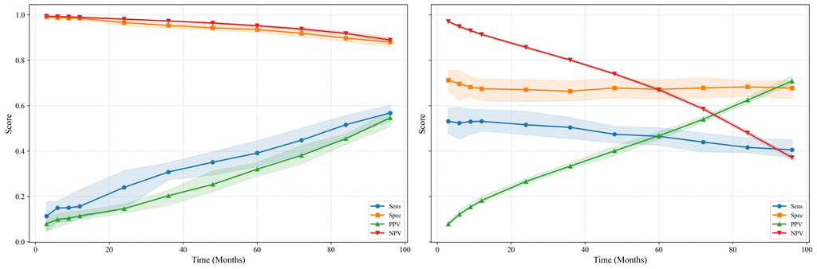

📈 PLOT: Discrimination (Uno’s C-Index)

💾 Saved plot: _figs/XGB7_comb_Uno_CIndex_CI_20260226_2053.png

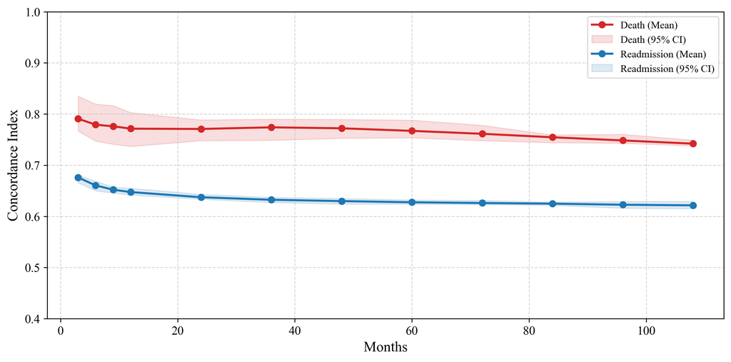

📉 PLOT: Time-Dependent Integrated Brier Score (IBS)

💾 Saved plot: _figs/XGB7_comb_IBS_CI_20260226_2053.png

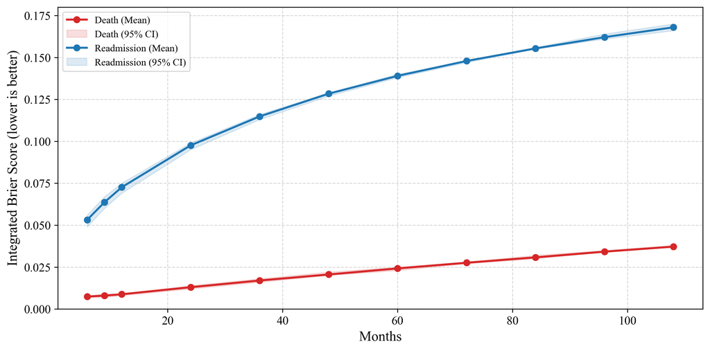

📋 TABLES

> > > GLOBAL PERFORMANCE

|  | Risk | Metric | Display |
| --- | --- | --- | --- |
| 0 | Death | IBS | 0.037 (0.037-0.038) |
| 1 | Death | Uno's C-Index | 0.746 (0.721-0.768) |
| 2 | Readmission | IBS | 0.168 (0.166-0.170) |
| 3 | Readmission | Uno's C-Index | 0.618 (0.607-0.627) |

> > > DETAILED METRICS BY TIME

| Risk | Metric Time_num | Brier Score | F1 | IBS | NPV | PPV | Sens | Spec | Threshold | Uno's C-Index |
| --- | --- | --- | --- | --- | --- | --- | --- | --- | --- | --- |
| Death | 3.0 | 0.007 (0.006-0.007) | 0.088 (0.055-0.123) | NaN | 0.994 (0.993-0.995) | 0.079 (0.048-0.113) | 0.113 (0.046-0.177) | 0.991 (0.984-0.997) | 0.043 (0.034-0.054) | 0.791 (0.767-0.835) |
|  | 6.0 | 0.009 (0.008-0.009) | 0.118 (0.073-0.144) | 0.007 (0.007-0.008) | 0.992 (0.992-0.993) | 0.099 (0.062-0.125) | 0.149 (0.087-0.179) | 0.988 (0.984-0.991) | 0.050 (0.043-0.057) | 0.779 (0.747-0.819) |
|  | 9.0 | 0.010 (0.009-0.011) | 0.122 (0.085-0.153) | 0.008 (0.007-0.009) | 0.991 (0.990-0.992) | 0.104 (0.082-0.135) | 0.150 (0.089-0.205) | 0.986 (0.982-0.990) | 0.057 (0.051-0.069) | 0.776 (0.741-0.816) |
|  | 12.0 | 0.012 (0.011-0.013) | 0.130 (0.105-0.162) | 0.009 (0.008-0.009) | 0.989 (0.988-0.990) | 0.114 (0.097-0.136) | 0.156 (0.103-0.229) | 0.985 (0.979-0.989) | 0.065 (0.059-0.076) | 0.771 (0.737-0.803) |
|  | 24.0 | 0.022 (0.021-0.024) | 0.179 (0.137-0.200) | 0.013 (0.012-0.014) | 0.981 (0.978-0.983) | 0.146 (0.127-0.167) | 0.240 (0.147-0.313) | 0.966 (0.951-0.976) | 0.081 (0.069-0.094) | 0.771 (0.748-0.788) |
|  | 36.0 | 0.034 (0.033-0.036) | 0.244 (0.209-0.264) | 0.017 (0.016-0.018) | 0.973 (0.970-0.975) | 0.203 (0.162-0.228) | 0.307 (0.273-0.349) | 0.953 (0.942-0.960) | 0.097 (0.087-0.102) | 0.774 (0.749-0.790) |
|  | 48.0 | 0.045 (0.044-0.047) | 0.292 (0.257-0.318) | 0.021 (0.020-0.022) | 0.964 (0.960-0.967) | 0.253 (0.221-0.312) | 0.351 (0.294-0.397) | 0.943 (0.930-0.961) | 0.107 (0.098-0.121) | 0.772 (0.753-0.789) |
|  | 60.0 | 0.061 (0.059-0.062) | 0.351 (0.313-0.374) | 0.024 (0.023-0.025) | 0.952 (0.947-0.956) | 0.320 (0.289-0.350) | 0.391 (0.332-0.445) | 0.935 (0.923-0.944) | 0.116 (0.104-0.128) | 0.767 (0.754-0.788) |
|  | 72.0 | 0.081 (0.077-0.083) | 0.411 (0.369-0.429) | 0.028 (0.027-0.028) | 0.937 (0.932-0.944) | 0.381 (0.343-0.426) | 0.448 (0.387-0.501) | 0.919 (0.903-0.935) | 0.115 (0.104-0.126) | 0.761 (0.748-0.778) |
|  | 84.0 | 0.110 (0.105-0.113) | 0.483 (0.450-0.497) | 0.031 (0.030-0.032) | 0.918 (0.911-0.927) | 0.454 (0.429-0.475) | 0.516 (0.460-0.557) | 0.897 (0.882-0.905) | 0.108 (0.099-0.115) | 0.755 (0.744-0.759) |
|  | 96.0 | 0.149 (0.144-0.156) | 0.556 (0.536-0.569) | 0.034 (0.034-0.035) | 0.889 (0.880-0.899) | 0.546 (0.508-0.576) | 0.567 (0.533-0.602) | 0.880 (0.857-0.898) | 0.104 (0.094-0.116) | 0.748 (0.743-0.760) |
|  | 108.0 | 0.216 (0.213-0.223) | 0.635 (0.614-0.655) | 0.037 (0.037-0.038) | 0.838 (0.827-0.845) | 0.637 (0.611-0.673) | 0.633 (0.606-0.650) | 0.840 (0.818-0.860) | 0.094 (0.088-0.102) | 0.742 (0.738-0.749) |
| Readmission | 3.0 | 0.041 (0.038-0.044) | 0.136 (0.125-0.152) | NaN | 0.971 (0.968-0.974) | 0.078 (0.071-0.089) | 0.531 (0.476-0.590) | 0.712 (0.664-0.755) | 0.048 (0.045-0.051) | 0.676 (0.666-0.680) |
|  | 6.0 | 0.066 (0.062-0.069) | 0.197 (0.181-0.214) | 0.053 (0.049-0.056) | 0.948 (0.944-0.952) | 0.121 (0.111-0.139) | 0.523 (0.454-0.594) | 0.696 (0.624-0.757) | 0.080 (0.073-0.085) | 0.661 (0.650-0.669) |
|  | 9.0 | 0.086 (0.083-0.089) | 0.237 (0.226-0.254) | 0.064 (0.060-0.067) | 0.930 (0.927-0.934) | 0.153 (0.145-0.170) | 0.529 (0.472-0.582) | 0.681 (0.637-0.725) | 0.103 (0.098-0.109) | 0.652 (0.646-0.657) |
|  | 12.0 | 0.102 (0.098-0.104) | 0.271 (0.261-0.287) | 0.073 (0.069-0.075) | 0.914 (0.909-0.918) | 0.182 (0.174-0.200) | 0.531 (0.489-0.583) | 0.674 (0.622-0.718) | 0.124 (0.116-0.129) | 0.647 (0.642-0.655) |
|  | 24.0 | 0.147 (0.145-0.148) | 0.351 (0.339-0.359) | 0.098 (0.095-0.099) | 0.857 (0.850-0.861) | 0.266 (0.254-0.281) | 0.516 (0.472-0.575) | 0.670 (0.617-0.714) | 0.182 (0.171-0.190) | 0.637 (0.634-0.643) |
|  | 36.0 | 0.181 (0.180-0.183) | 0.401 (0.386-0.411) | 0.115 (0.113-0.116) | 0.801 (0.795-0.806) | 0.333 (0.321-0.348) | 0.504 (0.455-0.548) | 0.663 (0.622-0.709) | 0.224 (0.214-0.233) | 0.632 (0.627-0.637) |
|  | 48.0 | 0.211 (0.209-0.213) | 0.434 (0.421-0.446) | 0.128 (0.127-0.129) | 0.739 (0.735-0.744) | 0.401 (0.380-0.422) | 0.474 (0.436-0.509) | 0.678 (0.634-0.721) | 0.261 (0.252-0.269) | 0.630 (0.624-0.635) |
|  | 60.0 | 0.241 (0.238-0.243) | 0.465 (0.447-0.479) | 0.139 (0.138-0.140) | 0.670 (0.664-0.677) | 0.467 (0.452-0.486) | 0.465 (0.425-0.503) | 0.672 (0.629-0.713) | 0.285 (0.275-0.293) | 0.628 (0.624-0.632) |
|  | 72.0 | 0.269 (0.267-0.272) | 0.484 (0.457-0.504) | 0.148 (0.147-0.148) | 0.585 (0.579-0.595) | 0.540 (0.526-0.552) | 0.439 (0.396-0.479) | 0.678 (0.634-0.724) | 0.312 (0.301-0.323) | 0.626 (0.623-0.631) |
|  | 84.0 | 0.302 (0.300-0.304) | 0.499 (0.481-0.528) | 0.155 (0.155-0.156) | 0.480 (0.472-0.487) | 0.624 (0.612-0.638) | 0.416 (0.393-0.457) | 0.683 (0.640-0.708) | 0.334 (0.325-0.341) | 0.625 (0.622-0.628) |
|  | 96.0 | 0.330 (0.329-0.332) | 0.515 (0.486-0.551) | 0.162 (0.161-0.164) | 0.371 (0.362-0.380) | 0.708 (0.695-0.732) | 0.405 (0.370-0.450) | 0.678 (0.631-0.711) | 0.352 (0.340-0.365) | 0.623 (0.616-0.629) |
|  | 108.0 | 0.359 (0.358-0.361) | 0.537 (0.503-0.563) | 0.168 (0.166-0.170) | 0.253 (0.246-0.264) | 0.806 (0.789-0.826) | 0.403 (0.363-0.433) | 0.675 (0.631-0.721) | 0.363 (0.353-0.379) | 0.622 (0.615-0.629) |

```python
#@title 📊 Step 7: Final Reporting & Plots (XGB7 Readm Corr - Local/Positron Version)

import matplotlib.pyplot as plt
import seaborn as sns
import pandas as pd
import numpy as np
import matplotlib as mpl
from datetime import datetime
from IPython.display import display, Markdown
import os

# --- 1. CONFIGURATION ---
# Font Settings: Times New Roman (standard scientific publishing style)
mpl.rcParams.update({
    "font.family": "serif",
    "font.serif": ["Times New Roman", "Times", "Nimbus Roman", "DejaVu Serif"],
    "pdf.fonttype": 42,
    "ps.fonttype": 42,
    "axes.labelsize": 14,
    "axes.titlesize": 16,
    "xtick.labelsize": 12,
    "ytick.labelsize": 12,
    "figure.dpi": 300
})

timestamp = datetime.now().strftime("%Y%m%d_%H%M")

# --- 2. ROBUST DATA LOADING ---
try:
    if 'metrics_log_comb' not in locals():
        if 'metrics_log' in locals():
             metrics_log_comb = metrics_log
        else:
            raise NameError("metrics_log_comb not found in memory.")

    if isinstance(metrics_log_comb, pd.DataFrame):
        display(Markdown("✅ metrics_log_comb is already a DataFrame. Using directly."))
        df_res = metrics_log_comb.copy()
    elif isinstance(metrics_log_comb, dict):
        display(Markdown("✅ metrics_log_comb is a dictionary. Converting to DataFrame..."))
        df_res = pd.DataFrame(metrics_log_comb['data'], columns=metrics_log_comb['columns'])
    elif isinstance(metrics_log_comb, list):
         display(Markdown("✅ metrics_log_comb is a list. Converting to DataFrame..."))
         df_res = pd.DataFrame(metrics_log_comb)
    else:
        raise TypeError(f"Unexpected type for metrics_log_comb: {type(metrics_log_comb)}")

    display(Markdown(f"📊 Data loaded: {len(df_res)} rows."))

except NameError:
    display(Markdown("❌ Error: 'metrics_log_comb' variable not found in memory."))
    raise

# --- 3. AGGREGATE STATS (Mean, Std, SE, CI) ---
grouped = df_res.groupby(['Risk', 'Metric', 'Time'])['Value']
df_agg = grouped.agg(['mean', 'std', 'count']).reset_index()
df_agg['Time_num'] = pd.to_numeric(df_agg['Time'], errors='coerce')

cis = []
for name, group in grouped:
    values = group.dropna().values
    if len(values) > 1:
        lower = np.percentile(values, 2.5)
        upper = np.percentile(values, 97.5)
    else:
        val = values[0] if len(values) > 0 else np.nan
        lower = upper = val
    cis.append((name[0], name[1], name[2], lower, upper))

ci_df = pd.DataFrame(cis, columns=['Risk', 'Metric', 'Time', 'lower', 'upper'])
df_agg = df_agg.merge(ci_df, on=['Risk', 'Metric', 'Time'])
df_agg['Display'] = df_agg.apply(lambda x: f"{x['mean']:.3f} ({x['lower']:.3f}-{x['upper']:.3f})", axis=1)

out_dir = "_figs"
os.makedirs(out_dir, exist_ok=True)
summary_filename = f"{out_dir}/XGB7_comb_final_summary_{timestamp}.csv"
df_agg.to_csv(summary_filename, index=False)
display(Markdown(f"💾 Saved summary stats to local directory: {summary_filename}"))

# --- 4. PLOT 1: CLASSIFICATION METRICS ---
print("\n" + "="*80)
display(Markdown("📈 PLOT: Classification Metrics"))
print("="*80)

fig, axes = plt.subplots(1, 2, figsize=(18, 6), sharey=True)
colors = {'Sens': '#1f77b4', 'Spec': '#ff7f0e', 'PPV': '#2ca02c', 'NPV': '#d62728'}
markers = {'Sens': 'o', 'Spec': 's', 'PPV': '^', 'NPV': 'v'}

for i, risk in enumerate(['Death', 'Readmission']):
    ax = axes[i]
    subset = df_agg[(df_agg['Risk'] == risk) & (df_agg['Time_num'] <= 96) & (df_agg['Metric'].isin(colors.keys()))]
    for m in colors.keys():
        d = subset[subset['Metric'] == m]
        if not d.empty:
            ax.plot(d['Time_num'], d['mean'], label=m, color=colors[m], marker=markers[m], linewidth=2)
            ax.fill_between(d['Time_num'], d['lower'], d['upper'], color=colors[m], alpha=0.15)
    ax.set_title(None)#ax.set_title(f"{risk}: Classification Performance", fontsize=14, fontweight='bold')
    ax.set_xlabel("Time (Months)")
    ax.set_ylabel("Score")
    ax.legend(loc='lower right')
    ax.grid(True, linestyle='--', alpha=0.5)

plt.tight_layout()
fname_cls = f"XGB7_comb_Classification_Metrics_{timestamp}"
plt.savefig(os.path.join(out_dir, f"{fname_cls}.pdf"), bbox_inches="tight")
plt.savefig(os.path.join(out_dir, f"{fname_cls}.png"), dpi=300, bbox_inches="tight")
display(Markdown(f"💾 Saved plot: {out_dir}/{fname_cls}.png"))
plt.show()

# --- 5. PLOT 2: UNO'S C-INDEX ---
print("\n" + "="*80)
display(Markdown("📈 PLOT: Discrimination (Uno's C-Index)"))
print("="*80)

plt.figure(figsize=(10, 5))
uno_df = df_agg[df_agg['Metric'] == "Uno's C-Index"].copy()
uno_df['Time_num'] = pd.to_numeric(uno_df['Time'], errors='coerce')
risk_colors = {'Death': '#D62728', 'Readmission': '#1F77B4'}

for risk in ['Death', 'Readmission']:
    d = uno_df[uno_df['Risk'] == risk]
    if not d.empty:
        d = d.sort_values('Time_num')
        d_plot = d.dropna(subset=['Time_num'])
        plt.plot(d_plot['Time_num'], d_plot['mean'], marker='o', label=f"{risk} (Mean)", color=risk_colors[risk], linewidth=2)
        plt.fill_between(d_plot['Time_num'], d_plot['lower'], d_plot['upper'], color=risk_colors[risk], alpha=0.15, label=f"{risk} (95% CI)")

plt.title(None)#plt.title("Time-Dependent Discrimination (Uno's C-Index)", fontsize=14, fontweight='bold')
plt.xlabel("Months")
plt.ylabel("Concordance Index")
plt.ylim(0.4, 1.0)
plt.legend()
plt.grid(True, linestyle='--', alpha=0.5)
plt.tight_layout()

fname_uno = f"XGB7_comb_Uno_CIndex_CI_{timestamp}"
plt.savefig(os.path.join(out_dir, f"{fname_uno}.pdf"), bbox_inches="tight")
plt.savefig(os.path.join(out_dir, f"{fname_uno}.png"), dpi=300, bbox_inches="tight")
display(Markdown(f"💾 Saved plot: {out_dir}/{fname_uno}.png"))
plt.show()

# --- 6. PLOT 3: INTEGRATED BRIER SCORE (IBS) ---
print("\n" + "="*80)
display(Markdown("📉 PLOT: Time-Dependent Integrated Brier Score (IBS)"))
print("="*80)

plt.figure(figsize=(10, 5))
ibs_df = df_agg[df_agg['Metric'] == 'IBS'].copy()
ibs_df['Time_num'] = pd.to_numeric(ibs_df['Time'], errors='coerce')

for risk in ['Death', 'Readmission']:
    d = ibs_df[ibs_df['Risk'] == risk]
    if not d.empty:
        d = d.sort_values('Time_num')
        d_plot = d.dropna(subset=['Time_num'])
        plt.plot(d_plot['Time_num'], d_plot['mean'], marker='o', label=f"{risk} (Mean)", color=risk_colors[risk], linewidth=2)
        plt.fill_between(d_plot['Time_num'], d_plot['lower'], d_plot['upper'], color=risk_colors[risk], alpha=0.15, label=f"{risk} (95% CI)")

plt.title(None)#plt.title("Time-Dependent Integrated Brier Score (IBS)", fontsize=14, fontweight='bold')
ax.set_title(None)
plt.xlabel("Months")
plt.ylabel("Integrated Brier Score (lower is better)")
ymin = max(0.0, ibs_df['lower'].min() - 0.01) if not ibs_df.empty else 0.0
ymax = ibs_df['upper'].max() + 0.01 if not ibs_df.empty else 1.0
plt.ylim(ymin, ymax)
plt.legend()
plt.grid(True, linestyle='--', alpha=0.5)
plt.tight_layout()

fname_ibs = f"XGB7_comb_IBS_CI_{timestamp}"
plt.savefig(os.path.join(out_dir, f"{fname_ibs}.pdf"), bbox_inches="tight")
plt.savefig(os.path.join(out_dir, f"{fname_ibs}.png"), dpi=300, bbox_inches="tight")
display(Markdown(f"💾 Saved plot: {out_dir}/{fname_ibs}.png"))
plt.show()

# --- 7. TABLES ---
print("\n" + "="*80)
display(Markdown("📋 TABLES"))
print("="*80)

display(Markdown("\n>>> GLOBAL PERFORMANCE"))
global_df = df_agg[df_agg['Time'] == 'Global'][['Risk', 'Metric', 'Display']].reset_index(drop=True)
if not global_df.empty:
    display(global_df)
else:
    display(Markdown("No global metrics found in aggregation."))

display(Markdown("\n>>> DETAILED METRICS BY TIME"))
pivot_df = df_agg.pivot_table(index=['Risk', 'Time_num'], columns='Metric', values='Display', aggfunc='first')
display(pivot_df)
```

```python
#@title 📊 Step 5b: Robust Time-to-Event Calibration Plots (Fixed Colors + Timestamp File Pick)

import os, re, glob, pickle
from datetime import datetime
import numpy as np
import pandas as pd
import matplotlib.pyplot as plt
from lifelines import KaplanMeierFitter
from IPython.display import display, Markdown

TARGET_TIMES = [3, 6, 12, 36, 60, 96]
RISK_GROUPS = 10

IN_DIR = "_out"
OUT_DIR = "_figs"
PREFER = "latest"  # change to "earliest" if needed

FILE_PATTERNS = [
    "xgb6_corr_DUAL_final_ev_hyp_*.pkl"#,
    #"xgb6_DUAL_final_ev_hyp_*.pkl",
]

timestamp_now = datetime.now().strftime("%Y%m%d_%H%M")

TS_RE = re.compile(r"_(\d{8}_\d{4})\.pkl$")

def pick_file_by_timestamp(in_dir, patterns, prefer="latest"):
    candidates = []
    for pat in patterns:
        for p in glob.glob(os.path.join(in_dir, pat)):
            m = TS_RE.search(os.path.basename(p))
            if not m:
                continue
            try:
                ts = datetime.strptime(m.group(1), "%Y%m%d_%H%M")
            except ValueError:
                continue
            candidates.append((ts, p))

    if not candidates:
        raise FileNotFoundError(
            f"No valid files found in '{in_dir}' for patterns: {patterns}"
        )

    candidates.sort(key=lambda x: x[0])
    return candidates[-1] if prefer == "latest" else candidates[0]

def get_time_idx(eval_times, t):
    arr = np.asarray(eval_times, dtype=float)
    idx = np.where(np.isclose(arr, float(t)))[0]
    return int(idx[0]) if idx.size else None

def get_calibration_data(raw_log, risk_type, time_point, n_groups=10):
    parts = []

    for entry in raw_log:
        idx = get_time_idx(entry.get("eval_times", []), time_point)
        if idx is None:
            continue

        if risk_type == "Readmission":
            surv = np.asarray(entry["probs_readm_matrix"][:, idx], dtype=float)
            y_val = entry.get("y_val_r")
        else:
            surv = np.asarray(entry["probs_death_matrix"][:, idx], dtype=float)
            y_val = entry.get("y_val_d")

        if y_val is None:
            continue

        prob = 1.0 - np.clip(surv, 0.0, 1.0)
        parts.append(pd.DataFrame({
            "prob": prob,
            "time": np.asarray(y_val["time"], dtype=float),
            "event": np.asarray(y_val["event"], dtype=bool).astype(int),
        }))

    if not parts:
        return None

    df = pd.concat(parts, ignore_index=True).dropna(subset=["prob", "time", "event"])
    uniq = int(df["prob"].nunique())
    bins = min(n_groups, uniq)
    if bins < 2:
        return None


    # rank-based qcut avoids duplicate-edge failures
    df["group"] = pd.qcut(df["prob"].rank(method="first"), q=bins, labels=False)

    kmf = KaplanMeierFitter()
    out = []

    for g in sorted(df["group"].unique()):
        grp = df[df["group"] == g]
        if grp.empty:
            continue

        kmf.fit(durations=grp["time"], event_observed=grp["event"])
        obs = 1.0 - float(kmf.survival_function_at_times([time_point]).iloc[0])

        out.append({
            "group": int(g),
            "n": int(len(grp)),
            "mean_pred": float(grp["prob"].mean()),
            "obs_freq": float(np.clip(obs, 0.0, 1.0)),
        })

    out_df = pd.DataFrame(out).sort_values("mean_pred")
    return out_df if not out_df.empty else None

# ---- Load by timestamp (latest/earliest) ----
picked_ts, picked_file = pick_file_by_timestamp(IN_DIR, FILE_PATTERNS, prefer=PREFER)
with open(picked_file, "rb") as f:
    raw_data_log = pickle.load(f)

os.makedirs(OUT_DIR, exist_ok=True)
display(Markdown(f"Loaded file: `{picked_file}` ({picked_ts:%Y-%m-%d %H:%M})"))

# Fixed, consistent color per horizon across both risk plots
times_sorted = sorted(TARGET_TIMES)
cmap = plt.get_cmap("viridis", len(times_sorted))
time_colors = {t: cmap(i) for i, t in enumerate(times_sorted)}

def plot_calibration(risk_name, time_horizons):
    fig, ax = plt.subplots(figsize=(10, 8))
    any_line = False

    for t in sorted(time_horizons):
        cal = get_calibration_data(raw_data_log, risk_name, t, n_groups=RISK_GROUPS)
        if cal is None or cal.empty:
            continue

        ax.plot(
            cal["mean_pred"], cal["obs_freq"],
            marker="o", linestyle="-", linewidth=2,
            color=time_colors[t], label=f"{t} Months"
        )
        any_line = True

    ax.plot([0, 1], [0, 1], "k--", alpha=0.5, label="Perfect Calibration")
    ax.set_title(None)#ax.set_title(f"Calibration Plot: {risk_name}", fontsize=16, fontweight="bold")
    ax.set_xlabel("Predicted Probability", fontsize=13)
    ax.set_ylabel("Observed Frequency (Kaplan-Meier)", fontsize=13)
    ax.grid(True, alpha=0.3)

    if risk_name == "Death":
        ax.set_xlim(0, 0.35)
        ax.set_ylim(0, 0.45)
    else:
        ax.set_xlim(0, 1.0)
        ax.set_ylim(0, 1.0)

    if any_line:
        ax.legend(fontsize=13, frameon=True, title="Horizon")

    fig.tight_layout()

    stamp = picked_ts.strftime("%Y%m%d_%H%M")
    png = os.path.join(OUT_DIR, f"XGB7_comb_Calibration_{risk_name}_{timestamp_now}.png")
    pdf = png.replace(".png", ".pdf")
    fig.savefig(png, dpi=300, bbox_inches="tight")
    fig.savefig(pdf, bbox_inches="tight")
    display(Markdown(f"Saved: `{png}`"))

    plt.show()
```

Loaded file: `_out\xgb6_corr_DUAL_final_ev_hyp_20260226_2047.pkl` (2026-02-26 20:47)

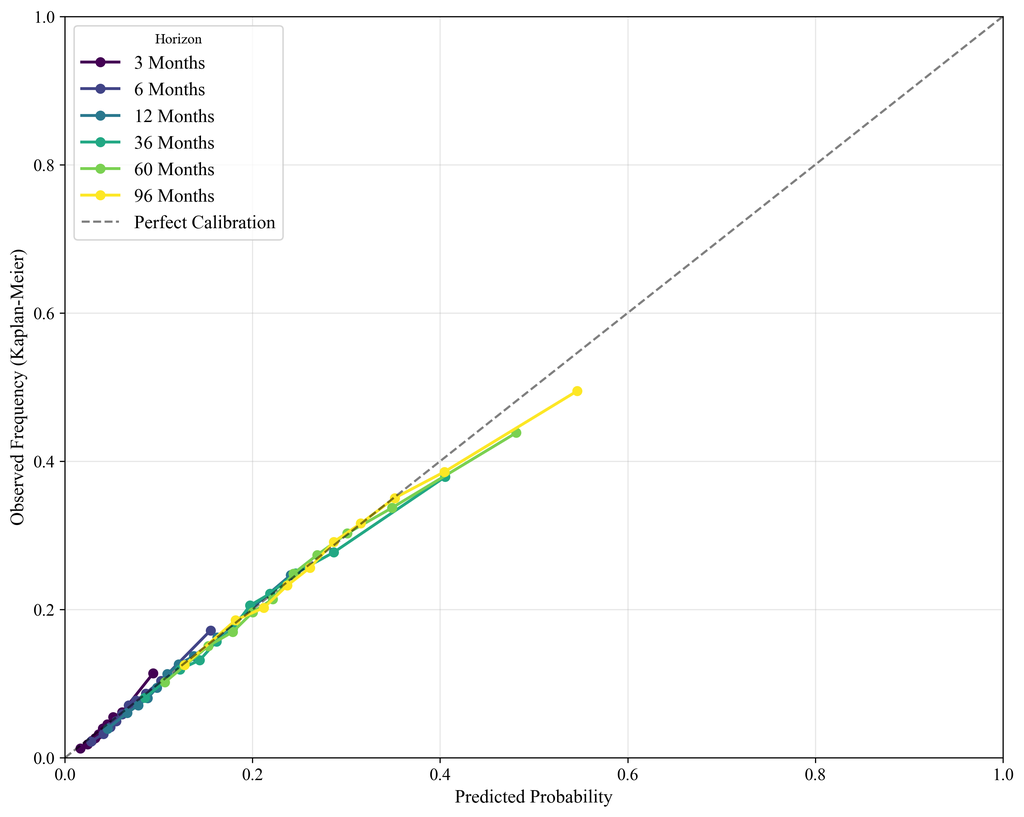

```python
plot_calibration("Readmission", TARGET_TIMES)
```

Saved: `_figs\XGB7_comb_Calibration_Death_20260226_2053.png`

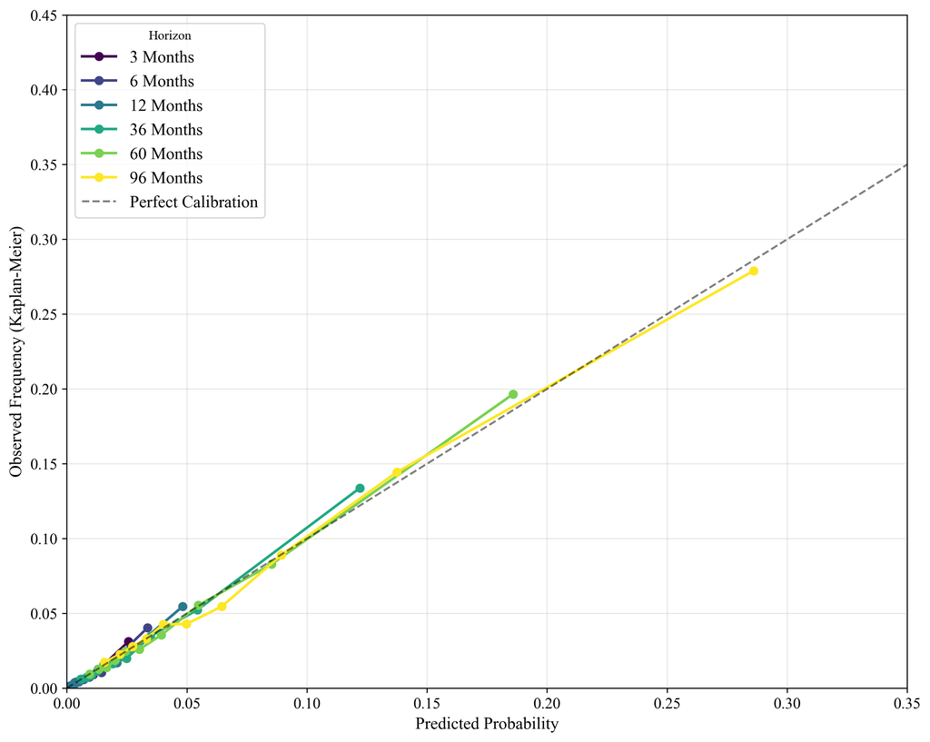

```python
plot_calibration("Death", TARGET_TIMES)
```

#### 10 Take-Home Messages

1. This script produces competing-risk calibration curves for readmission using Aalen-Johansen.
2. Predictions come from cross-validated folds, avoiding optimistic bias.
3. It correctly treats death as a competing event, not simple censoring.
4. Observed risks are estimated using the Aalen-Johansen estimator, which is appropriate for CIF.
5. Predicted risk is defined as: 1 − S_readmission(t) from the cause-specific Cox model.
6. Patients are grouped into quantile-based risk bins (default 10).
7. Calibration is evaluated at multiple time horizons simultaneously.
8. A patient-level master dataset is saved for future bootstrap calibration inference.
9. The pipeline separates modeling and calibration — improving reproducibility.
10. Output figures are publication-ready (PNG 300dpi + PDF).

#### 5 Assumptions of This Code

1. Cause-Specific Hazard Validity  
   The readmission survival probabilities generated via Breslow are correctly specified under a cause-specific Cox model.
2. Independence of Competing Events  
   Death and readmission are assumed to follow the standard competing risks framework (non-informative censoring conditional on covariates).
3. Proper Cross-Validation Aggregation  
   Combining all validation folds into a single master dataset assumes that pooling cross-validated predictions is unbiased.  
   (This is generally acceptable.)
4. Quantile Binning Adequacy  
   Risk binning assumes that quantile groups meaningfully represent calibration strata.  
   Calibration results can change with:
   - Different number of bins
   - Different minimum bin size
5. Aalen-Johansen Stability  
   Observed CIF estimation assumes:
   - Enough events per bin
   - Stable risk sets
   - No extreme sparsity in late follow-up

```python
#@title 📈 Step 7a: Calibration Plot (No boostrap)

import os, re, glob, pickle, time
from datetime import datetime
import numpy as np
import pandas as pd
import matplotlib.pyplot as plt
from lifelines import AalenJohansenFitter
from IPython.display import display, Markdown

TARGET_TIMES = [3, 6, 12, 36, 60, 96]
RISK_GROUPS = 10
IN_DIR = "_out"
OUT_DIR = "_figs"
PREFER = "latest"

# NEW: master calibration data export config
MASTER_SAVE_MODE = "both"   # "parquet", "pkl", or "both"
MASTER_PARQUET_COMPRESSION = "snappy"

FILE_PATTERNS = ["xgb6_corr_DUAL_final_ev_hyp_*.pkl"]
TS_RE = re.compile(r"_(\d{8}_\d{4})\.pkl$")
timestamp_now = datetime.now().strftime("%Y%m%d_%H%M")

def log(msg):
    print(f"[{datetime.now().strftime('%H:%M:%S')}] {msg}", flush=True)

def pick_file_by_timestamp(in_dir, patterns, prefer="latest"):
    candidates = []
    for pat in patterns:
        for p in glob.glob(os.path.join(in_dir, pat)):
            m = TS_RE.search(os.path.basename(p))
            if not m:
                continue
            try:
                ts = datetime.strptime(m.group(1), "%Y%m%d_%H%M")
            except ValueError:
                continue
            candidates.append((ts, p))
    if not candidates:
        raise FileNotFoundError(f"No valid files found in '{in_dir}' for {patterns}")
    candidates.sort(key=lambda x: x[0])
    return candidates[-1] if prefer == "latest" else candidates[0]

def get_time_idx(eval_times, t):
    arr = np.asarray(eval_times, dtype=float)
    idx = np.where(np.isclose(arr, float(t)))[0]
    return int(idx[0]) if idx.size else None

def build_competing_outcome(y_r, y_d):
    # 0=censored, 1=readmission, 2=death(competing)
    tr = np.asarray(y_r["time"], dtype=float)
    td = np.asarray(y_d["time"], dtype=float)
    er = np.asarray(y_r["event"], dtype=bool)
    ed = np.asarray(y_d["event"], dtype=bool)

    t = np.minimum(tr, td)
    ev = np.zeros(len(t), dtype=np.int8)

    readm_first = er & (~ed | (tr < td))
    death_first = ed & (~er | (td <= tr))  # tie -> death
    ev[readm_first] = 1
    ev[death_first] = 2
    return t, ev

def aj_cif_at_time(ajf, t):
    if hasattr(ajf, "cumulative_density_at_times"):
        try:
            vals = ajf.cumulative_density_at_times([t])
            return float(np.asarray(vals).reshape(-1)[0])
        except Exception:
            pass
    try:
        cd = ajf.cumulative_density_
        s = cd.iloc[:, 0] if isinstance(cd, pd.DataFrame) else pd.Series(cd)
        i = s.index.searchsorted(t, side="right") - 1
        return float(s.iloc[i]) if i >= 0 else 0.0
    except Exception:
        return np.nan

def build_master_df(raw_log, target_times):
    parts = []
    tset = sorted(set(int(x) for x in target_times))
    n_total = len(raw_log)

    for k, e in enumerate(raw_log, 1):
        y_r = e.get("y_val_r")
        y_d = e.get("y_val_d")
        if y_r is None or y_d is None:
            continue

        idx_map = {t: get_time_idx(e.get("eval_times", []), t) for t in tset}
        if all(v is None for v in idx_map.values()):
            continue

        t, ev = build_competing_outcome(y_r, y_d)
        pmat = np.asarray(e.get("probs_readm_matrix"), dtype=float)

        if pmat.ndim != 2 or pmat.shape[0] != len(t):
            continue

        block = {
            "time": np.asarray(t, dtype=float),
            "event": np.asarray(ev, dtype=np.int8)
        }

        for tt, idx in idx_map.items():
            if idx is not None and idx < pmat.shape[1]:
                block[f"pred_{tt}"] = 1.0 - np.clip(pmat[:, idx], 0.0, 1.0)

        parts.append(pd.DataFrame(block))

        if (k % 5 == 0) or (k == n_total):
            log(f"Prepared fold-block {k}/{n_total}")

    if not parts:
        return None

    df = pd.concat(parts, ignore_index=True)
    df = df.dropna(subset=["time", "event"])

    if not df["event"].isin([0, 1, 2]).all():
        bad = df.loc[~df["event"].isin([0, 1, 2]), "event"].unique()
        raise ValueError(f"Unexpected event codes: {bad}")

    return df

# NEW: save patient-level master df for later bootstrap
def save_master_df(df_master, out_dir, stamp, mode="both", compression="snappy"):
    os.makedirs(out_dir, exist_ok=True)
    base = os.path.join(out_dir, f"xgb7_calibration_master_{stamp}")
    saved_paths = []

    df_save = df_master.copy()

    # optional size optimization
    if "time" in df_save.columns:
        df_save["time"] = df_save["time"].astype("float32")
    if "event" in df_save.columns:
        df_save["event"] = df_save["event"].astype("int8")
    pred_cols = [c for c in df_save.columns if c.startswith("pred_")]
    for c in pred_cols:
        df_save[c] = df_save[c].astype("float32")

    parquet_ok = False
    if mode in ("parquet", "both"):
        parquet_path = base + ".parquet"
        try:
            df_save.to_parquet(parquet_path, index=False, compression=compression)
            log(f"Saved master df: {parquet_path}")
            saved_paths.append(parquet_path)
            parquet_ok = True
        except Exception as e:
            log(f"Parquet save failed: {e}")

    if mode in ("pkl", "both") or (mode == "parquet" and not parquet_ok):
        pkl_path = base + ".pkl"
        df_save.to_pickle(pkl_path)
        log(f"Saved master df: {pkl_path}")
        saved_paths.append(pkl_path)

    return saved_paths

def get_calibration_data_aj(df_master, time_point, n_groups=5, min_bin_n=30, round_decimals=3):
    col = f"pred_{int(time_point)}"
    if col not in df_master.columns:
        return None

    df = df_master[["time", "event", col]].rename(columns={col: "pred"}).dropna().copy()

    bins = min(n_groups, int(df["pred"].nunique()))
    if bins < 2:
        return None

    # binning by prediction only
    df["bin"] = pd.qcut(
        df["pred"].rank(method="first"),
        q=bins,
        labels=False,
        duplicates="drop"
    )

    n_bins_real = int(df["bin"].nunique())
    if n_bins_real < 2:
        return None

    try:
        ajf = AalenJohansenFitter(calculate_variance=False)  # speed-up
    except TypeError:
        ajf = AalenJohansenFitter()

    rows = []
    t0 = time.perf_counter()

    for j, b in enumerate(sorted(df["bin"].dropna().unique()), 1):
        g = df[df["bin"] == b].copy()
        n = len(g)
        if n < min_bin_n:
            continue

        g["time"] = np.round(g["time"].to_numpy(dtype=float), round_decimals)

        n_readm = int((g["event"] == 1).sum())
        n_death = int((g["event"] == 2).sum())

        if n_readm == 0:
            obs_cif = 0.0
        else:
            try:
                ajf.fit(g["time"], g["event"], event_of_interest=1)
                obs_cif = aj_cif_at_time(ajf, time_point)
            except Exception as ex:
                log(f"[t={time_point}] bin={int(b)} AJ failed: {ex}")
                continue

        rows.append({
            "bin": int(b),
            "n": int(n),
            "n_readm": n_readm,
            "n_death": n_death,
            "mean_pred": float(g["pred"].mean()),
            "obs_cif_aj": float(np.clip(obs_cif, 0.0, 1.0)),
        })

        log(f"[t={time_point}] bin {j}/{n_bins_real} done (n={n}, readm={n_readm}, death={n_death})")

    log(f"[t={time_point}] finished in {time.perf_counter() - t0:.1f}s")

    out = pd.DataFrame(rows).sort_values("mean_pred")
    return out if not out.empty else None

def plot_calibration_aj(raw_log, target_times, stamp, out_dir="_figs"):
    os.makedirs(out_dir, exist_ok=True)
    os.makedirs("_out", exist_ok=True)

    log("Building master dataframe once (for all horizons)...")
    t0 = time.perf_counter()
    df_master = build_master_df(raw_log, target_times)
    if df_master is None or df_master.empty:
        raise RuntimeError("No usable calibration data could be assembled.")
    log(f"Master DF ready: {len(df_master):,} rows in {time.perf_counter() - t0:.1f}s")

    # NEW: save master data for later bootstrap
    save_master_df(
        df_master=df_master,
        out_dir="_out",
        stamp=stamp,
        mode=MASTER_SAVE_MODE,
        compression=MASTER_PARQUET_COMPRESSION
    )

    fig, ax = plt.subplots(figsize=(10, 8))
    cmap = plt.get_cmap("viridis", len(target_times))
    any_line = False

    for i, t in enumerate(sorted(target_times)):
        log(f"Starting horizon t={t}m")
        cal = get_calibration_data_aj(
            df_master, time_point=t, n_groups=RISK_GROUPS, min_bin_n=30, round_decimals=3
        )
        if cal is None or cal.empty:
            log(f"[t={t}] skipped (no valid bins)")
            continue

        cal.to_csv(f"_out/xgb7_calibration_aj_t{t}m_{timestamp_now}.csv", index=False)

        ax.plot(
            cal["mean_pred"], cal["obs_cif_aj"],
            marker="o", linewidth=2, color=cmap(i), label=f"{t} months"
        )
        any_line = True

    ax.plot([0, 1], [0, 1], "k--", alpha=0.5, label="Perfect calibration")
    ax.set_xlim(0, 1)
    ax.set_ylim(0, 1)
    ax.set_xlabel("Predicted probability (raw 1 - S_readmission)")
    ax.set_ylabel("Observed CIF (Aalen-Johansen)")
    ax.grid(True, alpha=0.3)
    if any_line:
        ax.legend()
    fig.tight_layout()

    png = os.path.join(out_dir, f"XGB7_comb_Calibration_AJ_Readmission_{timestamp_now}.png")
    pdf = png.replace(".png", ".pdf")
    fig.savefig(png, dpi=300, bbox_inches="tight")
    fig.savefig(pdf, bbox_inches="tight")
    log(f"Saved: {png}")
    log(f"Saved: {pdf}")
    #plt.show()
    plt.close(fig)

# -------- Load + run --------
picked_ts, picked_file = pick_file_by_timestamp(IN_DIR, FILE_PATTERNS, prefer=PREFER)
with open(picked_file, "rb") as f:
    raw_data_log = pickle.load(f)

log(f"Loaded: {picked_file}")
stamp = picked_ts.strftime("%Y%m%d_%H%M")
plot_calibration_aj(raw_data_log, TARGET_TIMES, stamp, out_dir=OUT_DIR)
```

**Searching for the latest Master Parquet file…**

📦 **Loading Master DF:** `_out\xgb7_calibration_master_20260226_2047.parquet`

🚀 **Starting Bootstrap Calibration** (500 resamples per horizon, CPUs: n-1)…

- t=3: n=354,015, unique_pred=350,664, bins_eff=10, events={0: 264925, 1: 76280, 2: 12810}

- ✅ t=3 plotted

- t=6: n=354,015, unique_pred=350,511, bins_eff=10, events={0: 264925, 1: 76280, 2: 12810}

- ✅ t=6 plotted

- t=12: n=354,015, unique_pred=350,388, bins_eff=10, events={0: 264925, 1: 76280, 2: 12810}

- ✅ t=12 plotted

- t=36: n=354,015, unique_pred=350,268, bins_eff=10, events={0: 264925, 1: 76280, 2: 12810}

- ✅ t=36 plotted

- t=60: n=354,015, unique_pred=350,169, bins_eff=10, events={0: 264925, 1: 76280, 2: 12810}

- ✅ t=60 plotted

- t=96: n=354,015, unique_pred=350,024, bins_eff=10, events={0: 264925, 1: 76280, 2: 12810}

- ✅ t=96 plotted

✅ **Master plot successfully saved at:** `_figs\XGB7_comb_Calibration_AJ_Bootstrap_CI_20260226_2055.png`

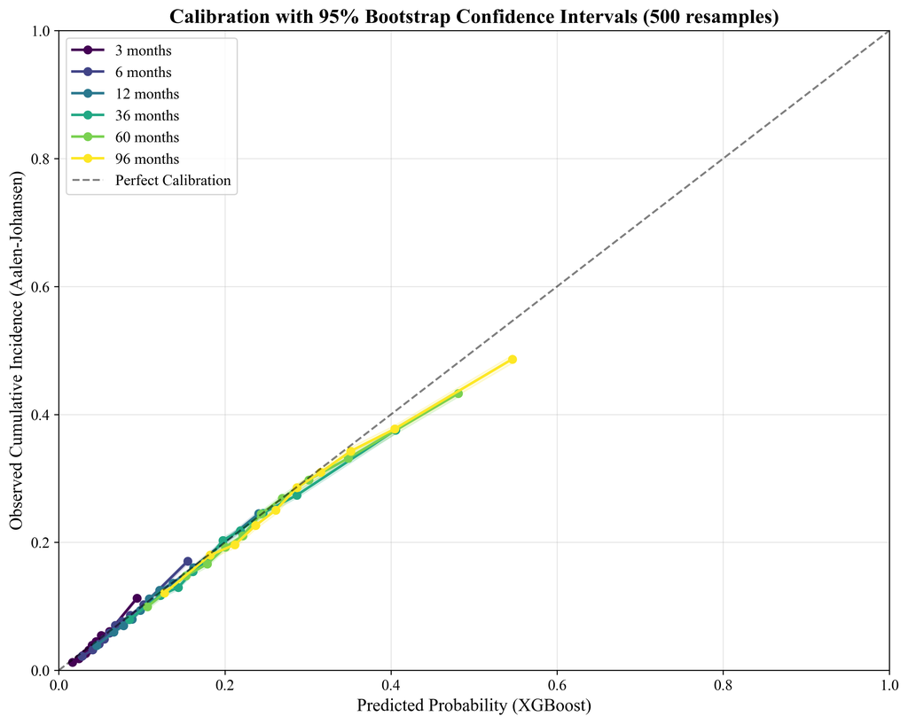

✅ **Calibration table exported:** `_out\xgb7b_calibration_table_20260226_2055.csv`

```python
#@title 📈 Step 7b: Bootstrap Calibration Plot (Aalen-Johansen with 95% CI)

import os, re, glob, time
from datetime import datetime
import numpy as np
import pandas as pd
import matplotlib.pyplot as plt
from lifelines import AalenJohansenFitter
from joblib import Parallel, delayed
from IPython.display import display, Markdown
import warnings

warnings.filterwarnings("ignore")

# --- 1. CONFIGURATION ---
TARGET_TIMES = [3, 6, 12, 36, 60, 96] # Reduced to key horizons to avoid visual clutter
RISK_GROUPS = 10
N_BOOTSTRAPS = 500  # 200 is a good fast standard. For final paper, increase to 500 or 1000.
IN_DIR = "_out"
OUT_DIR = "_figs"

timestamp_now = datetime.now().strftime("%Y%m%d_%H%M")

# --- 2. AJ HELPER FUNCTIONS ---
def aj_cif_at_time(ajf, t):
    """Safely extracts the cumulative incidence at a specific time point."""
    if hasattr(ajf, "cumulative_density_at_times"):
        try:
            vals = ajf.cumulative_density_at_times([t])
            return float(np.asarray(vals).reshape(-1)[0])
        except: pass
    try:
        cd = ajf.cumulative_density_
        s = cd.iloc[:, 0] if isinstance(cd, pd.DataFrame) else pd.Series(cd)
        i = s.index.searchsorted(t, side="right") - 1
        return float(s.iloc[i]) if i >= 0 else 0.0
    except: return np.nan

def calculate_aj_for_sample(df_sample, time_point, n_groups, min_bin_n=30):
    """Calculates observed AJ CIF per bin."""
    bins = min(n_groups, int(df_sample["pred"].nunique()))
    if bins < 2:
        return None

    df = df_sample.copy()
    df["bin"] = pd.qcut(
        df["pred"].rank(method="first"),
        q=bins,
        labels=False,
        duplicates="drop"
    )

    bins_real = sorted(df["bin"].dropna().unique())
    if len(bins_real) < 2:
        return None

    results = {}

    for b in bins_real:
        b = int(b)
        g = df[df["bin"] == b]
        if len(g) < min_bin_n:
            results[b] = np.nan
            continue

        n_readm = int((g["event"] == 1).sum())
        if n_readm == 0:
            results[b] = 0.0
            continue

        try:
            try:
                ajf = AalenJohansenFitter(calculate_variance=False, jitter_level=1e-5)
            except TypeError:
                ajf = AalenJohansenFitter(calculate_variance=False)

            # no rounding of time during bootstrap
            ajf.fit(
                g["time"].to_numpy(dtype=float),
                g["event"].to_numpy(dtype=int),
                event_of_interest=1
            )
            v = aj_cif_at_time(ajf, time_point)
            results[b] = float(np.clip(v, 0.0, 1.0)) if np.isfinite(v) else np.nan
        except Exception:
            results[b] = np.nan

    return results if results else None

def bootstrap_iteration(df_horizon, time_point, n_groups):
    """Performs a single complete bootstrap iteration."""
    df_boot = df_horizon.sample(frac=1.0, replace=True)
    return calculate_aj_for_sample(df_boot, time_point, n_groups)

# --- 3. LOAD MASTER DATAFRAME ---
display(Markdown("**Searching for the latest Master Parquet file...**"))
parquet_files = sorted(glob.glob(os.path.join(IN_DIR, "xgb7_calibration_master_*.parquet")))

if not parquet_files:
    raise FileNotFoundError("No Master Parquet file found. Make sure to run Step 7 first.")

latest_master = parquet_files[-1]
display(Markdown(f"📦 **Loading Master DF:** `{latest_master}`"))
df_master = pd.read_parquet(latest_master)

# --- 4. CALCULATION & PLOTTING ---
os.makedirs(OUT_DIR, exist_ok=True)
fig, ax = plt.subplots(figsize=(10, 8))
cmap = plt.get_cmap("viridis", len(TARGET_TIMES))
any_line = False

display(Markdown(f"<br>🚀 **Starting Bootstrap Calibration** ({N_BOOTSTRAPS} resamples per horizon, CPUs: n-1)..."))

export_rows = []

for i, t in enumerate(sorted(TARGET_TIMES)):
    col = f"pred_{t}"
    if col not in df_master.columns:
        display(Markdown(f"⚠️ Missing `{col}`"))
        continue

    df_h = df_master[["time", "event", col]].rename(columns={col: "pred"}).dropna().copy()
    bins_eff = min(RISK_GROUPS, int(df_h["pred"].nunique()))
    evt = df_h["event"].value_counts().to_dict()
    display(Markdown(f"- t={t}: n={len(df_h):,}, unique_pred={df_h['pred'].nunique():,}, bins_eff={bins_eff}, events={evt}"))

    if bins_eff < 2:
        display(Markdown(f"  - ❌ skipped: <2 unique predictions"))
        continue

    original_results = calculate_aj_for_sample(df_h, time_point=t, n_groups=bins_eff, min_bin_n=30)
    if not original_results:
        display(Markdown(f"  - ❌ skipped: no original AJ results"))
        continue

    df_h["bin"] = pd.qcut(df_h["pred"].rank(method="first"), q=bins_eff, labels=False, duplicates="drop")
    mean_preds = df_h.groupby("bin")["pred"].mean().to_dict()

    # --- Export table rows for this horizon (original sample, not bootstrap) ---
    bin_summary = (
        df_h.groupby("bin", dropna=True)
            .agg(
                n_patients=("event", "size"),
                n_readmissions=("event", lambda s: int((s == 1).sum())),
                n_deaths=("event", lambda s: int((s == 2).sum())),
                mean_pred=("pred", "mean"),
            )
            .reset_index()
    )
    for _, r in bin_summary.iterrows():
        b = int(r["bin"])
        export_rows.append({
            "Time (mo)": int(t),
            "Decile": b + 1,  # 1..10 instead of 0..9
            "N Patients": int(r["n_patients"]),
            "N Readmissions": int(r["n_readmissions"]),
            "N Deaths": int(r["n_deaths"]),
            "Mean Pred": float(r["mean_pred"]),
            "Obs CIF": float(original_results.get(b, np.nan)),  # AJ observed CIF at this horizon
        })

    boot_results = Parallel(n_jobs=-2)(
        delayed(bootstrap_iteration)(df_h, t, bins_eff) for _ in range(N_BOOTSTRAPS)
    )
    for b in sorted(original_results.keys()):
        valid_n = sum(1 for res in boot_results if res and b in res and np.isfinite(res[b]))
        print(f"[t={t}] bin={b} valid={valid_n}/{N_BOOTSTRAPS}, orig={original_results[b]}")

    x_vals, y_vals, y_lower, y_upper = [], [], [], []
    for b in sorted(original_results.keys()):
        if np.isnan(original_results[b]) or b not in mean_preds:
            continue
        b_ests = [res[b] for res in boot_results if res and b in res and not np.isnan(res[b])]
        if len(b_ests) >= int(0.3 * N_BOOTSTRAPS):   # relaxed from 50%
            x_vals.append(mean_preds[b])
            y_vals.append(original_results[b])
            y_lower.append(np.percentile(b_ests, 2.5))
            y_upper.append(np.percentile(b_ests, 97.5))

    if not x_vals:
        display(Markdown(f"  - ❌ skipped: no bins passed CI filter"))
        continue

    ax.plot(x_vals, y_vals, marker="o", linewidth=2, color=cmap(i), label=f"{t} months")
    ax.fill_between(x_vals, y_lower, y_upper, color=cmap(i), alpha=0.15)
    any_line = True
    display(Markdown(f"  - ✅ t={t} plotted"))

# --- 5. FINAL PLOT FORMATTING ---
ax.plot([0, 1], [0, 1], "k--", alpha=0.5, label="Perfect Calibration")

# Restored absolute axis limits
ax.set_xlim(0, 1)
ax.set_ylim(0, 1)

ax.set_xlabel("Predicted Probability (XGBoost)", fontsize=14)
ax.set_ylabel("Observed Cumulative Incidence (Aalen-Johansen)", fontsize=14)
ax.set_title(f"Calibration with 95% Bootstrap Confidence Intervals ({N_BOOTSTRAPS} resamples)", fontsize=16, fontweight='bold')
ax.grid(True, alpha=0.3)

if any_line:
    ax.legend(fontsize=12, loc="upper left")
fig.tight_layout()

# Save figures
png = os.path.join(OUT_DIR, f"XGB7_comb_Calibration_AJ_Bootstrap_CI_{timestamp_now}.png")
pdf = png.replace(".png", ".pdf")
fig.savefig(png, dpi=300, bbox_inches="tight")
fig.savefig(pdf, bbox_inches="tight")

display(Markdown(f"<br>✅ **Master plot successfully saved at:** `{png}`"))

plt.show()
# --- Save calibration table ---
df_export = pd.DataFrame(export_rows).sort_values(["Time (mo)", "Decile"])

# optional rounding for readability
df_export["Mean Pred"] = df_export["Mean Pred"].round(6)
df_export["Obs CIF"] = df_export["Obs CIF"].round(6)

csv_out = os.path.join("_out", f"xgb7b_calibration_table_{timestamp_now}.csv")
df_export.to_csv(csv_out, index=False)

display(Markdown(f"✅ **Calibration table exported:** `{csv_out}`"))
```

```python
display(HTML(f"""
<div style="
    height:400px;
    overflow:auto;
    border:1px solid #ccc;
    padding:10px;
    background-color:white;
    font-family:'Times New Roman';
    font-size:13px;
">
    {df_export.to_html(index=False)}
</div>
"""))
```

| Time (mo) | Decile | N Patients | N Readmissions | N Deaths | Mean Pred | Obs CIF |
| --- | --- | --- | --- | --- | --- | --- |
| 3 | 1 | 35402 | 2492 | 1477 | 0.016474 | 0.012407 |
| 3 | 2 | 35401 | 3972 | 1360 | 0.024109 | 0.018210 |
| 3 | 3 | 35402 | 4746 | 1411 | 0.028532 | 0.022798 |
| 3 | 4 | 35401 | 5761 | 1333 | 0.032312 | 0.026212 |
| 3 | 5 | 35402 | 6625 | 1214 | 0.036103 | 0.031511 |
| 3 | 6 | 35401 | 7906 | 1235 | 0.040205 | 0.039389 |
| 3 | 7 | 35401 | 8858 | 1215 | 0.044986 | 0.044963 |
| 3 | 8 | 35402 | 9979 | 1232 | 0.051254 | 0.054394 |
| 3 | 9 | 35401 | 11223 | 1259 | 0.061086 | 0.060762 |
| 3 | 10 | 35402 | 14718 | 1074 | 0.094192 | 0.112823 |
| 6 | 1 | 35402 | 2493 | 1474 | 0.028042 | 0.021924 |
| 6 | 2 | 35401 | 3979 | 1370 | 0.040931 | 0.032117 |
| 6 | 3 | 35402 | 4749 | 1410 | 0.048363 | 0.041156 |
| 6 | 4 | 35401 | 5754 | 1316 | 0.054692 | 0.048906 |
| 6 | 5 | 35402 | 6642 | 1226 | 0.061024 | 0.058175 |
| 6 | 6 | 35401 | 7894 | 1233 | 0.067853 | 0.070201 |
| 6 | 7 | 35401 | 8871 | 1225 | 0.075785 | 0.076467 |
| 6 | 8 | 35402 | 9954 | 1224 | 0.086146 | 0.086024 |
| 6 | 9 | 35401 | 11206 | 1267 | 0.102301 | 0.102717 |
| 6 | 10 | 35402 | 14738 | 1065 | 0.155309 | 0.170747 |
| 12 | 1 | 35402 | 2483 | 1477 | 0.045591 | 0.038830 |
| 12 | 2 | 35401 | 3974 | 1374 | 0.066285 | 0.059715 |
| 12 | 3 | 35402 | 4742 | 1396 | 0.078133 | 0.070010 |
| 12 | 4 | 35401 | 5773 | 1314 | 0.088183 | 0.079819 |
| 12 | 5 | 35402 | 6629 | 1246 | 0.098181 | 0.093715 |
| 12 | 6 | 35401 | 7922 | 1214 | 0.108907 | 0.111979 |
| 12 | 7 | 35401 | 8881 | 1229 | 0.121318 | 0.125022 |
| 12 | 8 | 35402 | 9922 | 1228 | 0.137422 | 0.136221 |
| 12 | 9 | 35401 | 11191 | 1266 | 0.162286 | 0.160773 |
| 12 | 10 | 35402 | 14763 | 1066 | 0.240844 | 0.245038 |
| 36 | 1 | 35402 | 2487 | 1484 | 0.085066 | 0.079547 |
| 36 | 2 | 35401 | 3962 | 1376 | 0.122626 | 0.117322 |
| 36 | 3 | 35402 | 4758 | 1391 | 0.143762 | 0.129491 |
| 36 | 4 | 35401 | 5791 | 1309 | 0.161496 | 0.154452 |
| 36 | 5 | 35402 | 6580 | 1260 | 0.178941 | 0.172000 |
| 36 | 6 | 35401 | 7960 | 1191 | 0.197465 | 0.203200 |
| 36 | 7 | 35401 | 8878 | 1236 | 0.218653 | 0.218493 |
| 36 | 8 | 35402 | 9939 | 1227 | 0.245726 | 0.245598 |
| 36 | 9 | 35401 | 11160 | 1272 | 0.286603 | 0.273756 |
| 36 | 10 | 35402 | 14765 | 1064 | 0.405397 | 0.375447 |
| 60 | 1 | 35402 | 2489 | 1484 | 0.106639 | 0.099397 |
| 60 | 2 | 35401 | 3965 | 1372 | 0.153008 | 0.147779 |
| 60 | 3 | 35402 | 4756 | 1395 | 0.178831 | 0.166065 |
| 60 | 4 | 35401 | 5792 | 1309 | 0.200365 | 0.192668 |
| 60 | 5 | 35402 | 6584 | 1258 | 0.221423 | 0.210141 |
| 60 | 6 | 35401 | 7949 | 1193 | 0.243655 | 0.244678 |
| 60 | 7 | 35401 | 8875 | 1230 | 0.268910 | 0.269011 |
| 60 | 8 | 35402 | 9930 | 1230 | 0.300909 | 0.297683 |
| 60 | 9 | 35401 | 11179 | 1276 | 0.348600 | 0.331544 |
| 60 | 10 | 35402 | 14761 | 1063 | 0.481162 | 0.432983 |
| 96 | 1 | 35402 | 2487 | 1482 | 0.127459 | 0.120674 |
| 96 | 2 | 35401 | 3966 | 1379 | 0.182014 | 0.179986 |
| 96 | 3 | 35402 | 4746 | 1395 | 0.212095 | 0.196532 |
| 96 | 4 | 35401 | 5784 | 1302 | 0.237041 | 0.226454 |
| 96 | 5 | 35402 | 6605 | 1258 | 0.261282 | 0.250457 |
| 96 | 6 | 35401 | 7973 | 1191 | 0.286719 | 0.285621 |
| 96 | 7 | 35401 | 8864 | 1244 | 0.315435 | 0.309368 |
| 96 | 8 | 35402 | 9935 | 1219 | 0.351521 | 0.342670 |
| 96 | 9 | 35401 | 11152 | 1275 | 0.404640 | 0.377461 |
| 96 | 10 | 35402 | 14768 | 1065 | 0.546029 | 0.486478 |

## SHAP

For XGB Cox, SHAP is on log-hazard scale, so case ranking should use absolute risk from baseline hazard:

Use baseline hazards only to compute absolute risk at horizon for ranking/labeling patients and calibration.

Avoid labeling SHAP axes as “% risk points

SHAP (SHapley Additive exPlanations) values were computed for both readmission and mortality models. To prevent data leakage, SHAP values were calculated on out-of-sample cross-validated predictions: for each patient, explanations were generated from models trained on 4/5 of folds that did not include that patient. SHAP values were averaged across 5-fold cross-validation and 5 multiple imputations, providing internally validated feature importance estimates. However, be honest this is internal validation only, not external.

```python
#@title Step 8: SHAP Analysis & Plots (DUAL, Multi-Horizon, source_tag-traceable)

import os
import re
import glob
import json
import pickle
import numpy as np
import pandas as pd
import shap
import matplotlib.pyplot as plt
import matplotlib as mpl
from IPython.display import display, Markdown

# -----------------------------
# 0) Config
# -----------------------------
IN_DIR = "_out"
OUT_DIR = "_out"
FIG_DIR = "_figs"

# Set None to auto-use all eval_times found in raw logs
TARGET_HORIZONS = [12, 60]
MAX_BEESWARM_N = 90000
RNG = np.random.RandomState(2125)

# CI config (optional but enabled by default)
BOOTSTRAP_CI = True
N_BOOTSTRAP = 500
CI_ALPHA = 0.05
BOOTSTRAP_MAX_N = 90000

# Multicollinearity check
CORR_THRESHOLD = 0.90

# Unified DPI
FIG_DPI = 300

os.makedirs(OUT_DIR, exist_ok=True)
os.makedirs(FIG_DIR, exist_ok=True)

OUTCOME_CFG = {
    "readm": {
        "label": "Readmission",
        "shap_key_candidates": ["shap_r_all", "shap_readm_all"],
        "margin_key_candidates": ["risk_pred_readm", "risk_pred_r", "margin_pred_readm"],
        "probs_key_candidates": ["probs_readm_matrix", "probs_r_matrix", "surv_probs_readm_matrix"],
        "hz_times_candidates": ["times_r", "times_readm"],
        "hz_vals_candidates": ["h0_r", "H0_r", "h0_readm"],
    },
    "death": {
        "label": "Death",
        "shap_key_candidates": ["shap_d_all", "shap_death_all", "shap_mort_all"],
        "margin_key_candidates": ["risk_pred_death", "risk_pred_d", "risk_pred_mort", "margin_pred_death"],
        "probs_key_candidates": ["probs_death_matrix", "probs_d_matrix", "probs_mort_matrix", "surv_probs_death_matrix"],
        "hz_times_candidates": ["times_d", "times_death", "times_mort"],
        "hz_vals_candidates": ["h0_d", "H0_d", "h0_death", "h0_mort"],
    },
}

VAL_ID_KEYS = ["val_ids", "valid_ids", "val_idx", "val_index", "idx_val"]

mpl.rcParams.update({
    "font.family": "serif",
    "font.serif": ["Times New Roman", "Times", "Nimbus Roman", "DejaVu Serif"],
    "pdf.fonttype": 42,
    "ps.fonttype": 42,
    "axes.labelsize": 14,
    "axes.titlesize": 15,
    "xtick.labelsize": 12,
    "ytick.labelsize": 12,
    "figure.dpi": FIG_DPI
})

# -----------------------------
# 1) Pick latest complete Step 5 bundle
# -----------------------------
TS_RE = re.compile(r"_(\d{8}_\d{4})\.pkl$")

def _tag_from_path(path):
    m = TS_RE.search(os.path.basename(path))
    return m.group(1) if m else None

def pick_latest_complete_bundle(in_dir):
    shap_files = glob.glob(os.path.join(in_dir, "xgb6_corr_DUAL_SHAP_Aggregated_*.pkl"))
    candidates = []

    for shapf in shap_files:
        tag = _tag_from_path(shapf)
        if not tag:
            continue
        rawf = os.path.join(in_dir, f"xgb6_corr_DUAL_final_ev_hyp_{tag}.pkl")
        hzf = os.path.join(in_dir, f"xgb6_corr_DUAL_BaselineHazards_{tag}.pkl")
        splitf = os.path.join(in_dir, f"xgb6_corr_DUAL_CV_Splits_{tag}.pkl")

        if all(os.path.exists(p) for p in (rawf, hzf, splitf)):
            dt = pd.to_datetime(tag, format="%Y%m%d_%H%M", errors="coerce")
            if pd.notna(dt):
                candidates.append((dt, tag, shapf, rawf, hzf, splitf))

    if not candidates:
        raise FileNotFoundError("No complete Step 5 bundle found in _out with prefix xgb6_corr_DUAL_*.")

    candidates.sort(key=lambda x: x[0])
    _, tag, shapf, rawf, hzf, splitf = candidates[-1]
    return tag, shapf, rawf, hzf, splitf

source_tag, shap_file, raw_file, hz_file, split_file = pick_latest_complete_bundle(IN_DIR)

# For traceability, use source_tag in filenames
FILE_TAG = source_tag
RUN_TS = pd.Timestamp.now().strftime("%Y%m%d_%H%M")

# -----------------------------
# 2) Load artifacts
# -----------------------------
with open(shap_file, "rb") as f:
    shap_data = pickle.load(f)

with open(raw_file, "rb") as f:
    raw_data_log = pickle.load(f)

with open(hz_file, "rb") as f:
    baseline_hazards_log = pickle.load(f)

with open(split_file, "rb") as f:
    cv_splits_log = pickle.load(f)

required_keys = {"X_all", "feature_names"}
missing = required_keys - set(shap_data.keys())
if missing:
    raise KeyError(f"Missing keys in SHAP file: {missing}")

X_all = shap_data["X_all"]
feature_names = list(shap_data["feature_names"])

if not isinstance(X_all, pd.DataFrame):
    X_all = pd.DataFrame(X_all, columns=feature_names)

if list(X_all.columns) != feature_names:
    X_all = X_all.reindex(columns=feature_names)

if not X_all.index.is_unique:
    raise ValueError("X_all index must be unique.")

# -----------------------------
# 3) Helpers
# -----------------------------
def get_first(dct, keys, default=None):
    for k in keys:
        if k in dct and dct[k] is not None:
            return dct[k]
    return default

def find_first_key(dct, keys):
    for k in keys:
        if k in dct:
            return k
    return None

def h0_at_t(times, h0_vals, t):
    times = np.asarray(times, dtype=float).ravel()
    h0_vals = np.asarray(h0_vals, dtype=float).ravel()
    if times.size == 0 or h0_vals.size == 0:
        return np.nan
    i = np.searchsorted(times, float(t), side="right") - 1
    return 0.0 if i < 0 else float(h0_vals[i])

def fmt_horizon(h):
    h = float(h)
    return str(int(h)) if abs(h - round(h)) < 1e-9 else f"{h:g}"

def horizon_token(h):
    return f"{fmt_horizon(h).replace('.', 'p')}m"

def save_current_figure(stem, outcome, horizon=None):
    fig = plt.gcf()
    hz = f"_{horizon_token(horizon)}" if horizon is not None else ""
    base = f"xgb8_dual_{outcome}_{stem}{hz}_{FILE_TAG}"
    png = os.path.join(FIG_DIR, f"{base}.png")
    pdf = os.path.join(FIG_DIR, f"{base}.pdf")
    fig.savefig(png, dpi=FIG_DPI, bbox_inches="tight")
    fig.savefig(pdf, bbox_inches="tight")
    return [png, pdf]

def discover_horizons(raw_log):
    vals = []
    for rec in raw_log:
        ev = np.asarray(rec.get("eval_times", []), dtype=float).ravel()
        vals.extend([v for v in ev if np.isfinite(v)])
    return sorted(set(vals))

def bootstrap_mean_abs_shap(shap_vals, n_boot=200, alpha=0.05, seed=2026, max_n=None):
    n, p = shap_vals.shape
    rng = np.random.RandomState(seed)
```

```python
    if max_n is not None and n > max_n:
        idx = rng.choice(n, size=max_n, replace=False)
        X = shap_vals[idx]
    else:
        X = shap_vals

    n_eff = X.shape[0]
    point = np.abs(X).mean(axis=0)

    boot = np.empty((n_boot, p), dtype=float)
    for b in range(n_boot):
        ib = rng.choice(n_eff, size=n_eff, replace=True)
        boot[b] = np.abs(X[ib]).mean(axis=0)

    lo = np.quantile(boot, alpha / 2.0, axis=0)
    hi = np.quantile(boot, 1.0 - alpha / 2.0, axis=0)
    return point, lo, hi, n_eff

def collect_margin_by_id(raw_log, split_map, cfg):
    rows = []
    for rec in raw_log:
        if "imp_idx" not in rec or "fold_idx" not in rec:
            continue
        key = (int(rec["imp_idx"]), int(rec["fold_idx"]))
        split_rec = split_map.get(key)
        if split_rec is None:
            continue

        val_ids = get_first(split_rec, VAL_ID_KEYS, [])
        margins = np.asarray(get_first(rec, cfg["margin_key_candidates"], []), dtype=float).ravel()

        if len(val_ids) != len(margins) or len(val_ids) == 0:
            continue

        for i, pid in enumerate(val_ids):
            rows.append((str(pid), float(margins[i])))

    if not rows:
        return pd.DataFrame(columns=["id", "margin"])

    return pd.DataFrame(rows, columns=["id", "margin"]).groupby("id", as_index=False)["margin"].mean()

def collect_risk_by_id(raw_log, split_map, hz_map, cfg, horizon):
    rows = []
    t = float(horizon)

    for rec in raw_log:
        if "imp_idx" not in rec or "fold_idx" not in rec:
            continue
        key = (int(rec["imp_idx"]), int(rec["fold_idx"]))

        split_rec = split_map.get(key)
        hz_rec = hz_map.get(key)

        if split_rec is None:
            continue

        val_ids = get_first(split_rec, VAL_ID_KEYS, [])
        margins = np.asarray(get_first(rec, cfg["margin_key_candidates"], []), dtype=float).ravel()
        if len(val_ids) != len(margins) or len(val_ids) == 0:
            continue

        risk_vec = None
        eval_times = np.asarray(rec.get("eval_times", []), dtype=float).ravel()
        probs_mat = np.asarray(get_first(rec, cfg["probs_key_candidates"], []), dtype=float)

        if eval_times.size > 0 and probs_mat.ndim == 2:
            j = np.where(np.isclose(eval_times, t))[0]
            if j.size > 0:
                jj = int(j[0])
                if probs_mat.shape[0] == len(val_ids) and probs_mat.shape[1] == eval_times.size:
                    risk_vec = 1.0 - probs_mat[:, jj]
                elif probs_mat.shape[1] == len(val_ids) and probs_mat.shape[0] == eval_times.size:
                    risk_vec = 1.0 - probs_mat[jj, :]
                if risk_vec is not None:
                    risk_vec = np.asarray(risk_vec, dtype=float).ravel()

        if risk_vec is None and hz_rec is not None:
            times = get_first(hz_rec, cfg["hz_times_candidates"], [])
            h0_vals = get_first(hz_rec, cfg["hz_vals_candidates"], [])
            H0_t = h0_at_t(times, h0_vals, t)
            if np.isfinite(H0_t):
                surv = np.exp(-np.exp(margins) * H0_t)
                risk_vec = 1.0 - surv

        if risk_vec is not None and len(risk_vec) == len(val_ids):
            risk_vec = np.clip(np.asarray(risk_vec, dtype=float).ravel(), 0.0, 1.0)
            for i, pid in enumerate(val_ids):
                rv = float(risk_vec[i])
                if np.isfinite(rv):
                    rows.append((str(pid), rv))

    if not rows:
        return pd.DataFrame(columns=["id", "risk"])

    return pd.DataFrame(rows, columns=["id", "risk"]).groupby("id", as_index=False)["risk"].mean()

def correlation_pairs_report(X_df, threshold=0.85):
    X_num = X_df.apply(pd.to_numeric, errors="coerce")
    valid_cols = [c for c in X_num.columns if X_num[c].std(skipna=True) > 0]
    X_num = X_num[valid_cols]
    corr = X_num.corr(method="pearson")

    pairs = []
    cols = list(corr.columns)
    for i in range(len(cols)):
        for j in range(i + 1, len(cols)):
            r = corr.iat[i, j]
            if np.isfinite(r) and abs(r) >= threshold:
                pairs.append((cols[i], cols[j], float(r), float(abs(r))))

    pairs_df = pd.DataFrame(pairs, columns=["feature_1", "feature_2", "pearson_r", "abs_r"])
    if len(pairs_df):
        pairs_df = pairs_df.sort_values("abs_r", ascending=False).reset_index(drop=True)
    return pairs_df, corr

# -----------------------------
# 4) Prepare maps/horizons + multicollinearity check
# -----------------------------
split_map = {
    (int(s["imp_idx"]), int(s["fold_idx"])): s
    for s in cv_splits_log
    if "imp_idx" in s and "fold_idx" in s
}
hz_map = {
    (int(h["imp_idx"]), int(h["fold_idx"])): h
    for h in baseline_hazards_log
    if "imp_idx" in h and "fold_idx" in h
}

available_horizons = discover_horizons(raw_data_log)
if TARGET_HORIZONS is None:
    horizons = available_horizons if available_horizons else [12.0]
else:
    horizons = sorted(set(float(h) for h in TARGET_HORIZONS))

corr_pairs_df, corr_mat = correlation_pairs_report(X_all, threshold=CORR_THRESHOLD)
corr_pairs_file = os.path.join(OUT_DIR, f"xgb8_dual_feature_corr_pairs_{FILE_TAG}.csv")
corr_mat_file = os.path.join(OUT_DIR, f"xgb8_dual_feature_corr_matrix_{FILE_TAG}.csv")
corr_pairs_df.to_csv(corr_pairs_file, index=False)
corr_mat.to_csv(corr_mat_file)

display(Markdown(
    f"### Step 8 SHAP (DUAL, Multi-Horizon)\n"
    f"- Source bundle tag: **{source_tag}**\n"
    f"- Run time: **{RUN_TS}**\n"
    f"- Patients: **{X_all.shape[0]}**\n"
    f"- Features: **{X_all.shape[1]}**\n"
    f"- Horizons (months): **{', '.join(fmt_horizon(h) for h in horizons)}**\n"
    f"- SHAP scale: **log-hazard**\n"
    f"- Multicollinearity threshold: **|r| >= {CORR_THRESHOLD:.2f}**"
))

if len(corr_pairs_df) > 0:
    display(Markdown(f"Found **{len(corr_pairs_df)}** correlated feature pairs (|r| >= {CORR_THRESHOLD:.2f})."))
    display(corr_pairs_df.head(20))
else:
    display(Markdown(f"No feature pairs above |r| >= {CORR_THRESHOLD:.2f}."))
```

```python
# -----------------------------
# 5) Run SHAP per outcome and horizon
# -----------------------------
saved_plot_files = []
saved_out_files = [corr_pairs_file, corr_mat_file]
all_case_rows = []
horizon_rows = []
processed_outcomes = []
id_to_row = {str(idx): i for i, idx in enumerate(X_all.index)}

for outcome_name, cfg in OUTCOME_CFG.items():
    shap_key = find_first_key(shap_data, cfg["shap_key_candidates"])
    if shap_key is None:
        print(f"Skipping {cfg['label']}: missing SHAP key among {cfg['shap_key_candidates']}.")
        continue

    shap_vals = np.asarray(shap_data[shap_key], dtype=float)
    if shap_vals.shape != X_all.shape:
        raise ValueError(f"{cfg['label']} SHAP shape mismatch: {shap_vals.shape} vs X_all {X_all.shape}")

    # Recover baseline on margin (log-hazard) scale
    df_margin = collect_margin_by_id(raw_data_log, split_map, cfg)
    df_shap_sum = pd.DataFrame({
        "id": X_all.index.astype(str),
        "shap_sum": shap_vals.sum(axis=1)
    })
    tmp = df_shap_sum.merge(df_margin, on="id", how="inner")
    base_margin = float((tmp["margin"] - tmp["shap_sum"]).mean()) if len(tmp) > 0 else 0.0

    explanation = shap.Explanation(
        values=shap_vals,
        base_values=np.full(X_all.shape[0], base_margin, dtype=float),
        data=X_all.to_numpy(),
        feature_names=feature_names
    )

    # Global mean |SHAP| + CI
    if BOOTSTRAP_CI:
        point, ci_low, ci_high, ci_n = bootstrap_mean_abs_shap(
            shap_vals,
            n_boot=N_BOOTSTRAP,
            alpha=CI_ALPHA,
            seed=2125,
            max_n=BOOTSTRAP_MAX_N
        )
    else:
        point = np.abs(shap_vals).mean(axis=0)
        ci_low = np.full_like(point, np.nan, dtype=float)
        ci_high = np.full_like(point, np.nan, dtype=float)
        ci_n = int(shap_vals.shape[0])

    df_top = pd.DataFrame({
        "outcome": cfg["label"],
        "feature": feature_names,
        "mean_abs_shap_log_hazard": point,
        "ci95_low": ci_low,
        "ci95_high": ci_high,
        "bootstrap_n": int(ci_n),
        "n_bootstrap": int(N_BOOTSTRAP if BOOTSTRAP_CI else 0),
        "ci_alpha": float(CI_ALPHA if BOOTSTRAP_CI else np.nan),
    }).sort_values("mean_abs_shap_log_hazard", ascending=False).reset_index(drop=True)

    top_file = os.path.join(OUT_DIR, f"xgb8_dual_{outcome_name}_shap_top_features_{FILE_TAG}.csv")
    df_top.to_csv(top_file, index=False)
    saved_out_files.append(top_file)

    processed_outcomes.append(outcome_name)

    display(Markdown(f"## {cfg['label']}"))
    display(Markdown("SHAP values and global importance are on the **log-hazard** scale."))
    display(df_top.head(20))

    # Bar plot with CI (log-hazard SHAP)
    df_bar = df_top.head(20).sort_values("mean_abs_shap_log_hazard", ascending=True)

    x = df_bar["mean_abs_shap_log_hazard"].to_numpy()
    has_ci = BOOTSTRAP_CI and np.isfinite(df_bar["ci95_low"]).all() and np.isfinite(df_bar["ci95_high"]).all()

    plt.figure(figsize=(11, 8))
    if has_ci:
        lo = df_bar["ci95_low"].to_numpy()
        hi = df_bar["ci95_high"].to_numpy()
        xerr = np.vstack([np.clip(x - lo, 0.0, None), np.clip(hi - x, 0.0, None)])
        plt.barh(df_bar["feature"], x, xerr=xerr, color="#4C72B0", alpha=0.9, ecolor="black", capsize=2)
        plt.title(f"{cfg['label']} Global mean |SHAP| (log-hazard) with 95% bootstrap CI")
    else:
        plt.barh(df_bar["feature"], x, color="#4C72B0", alpha=0.9)
        plt.title(f"{cfg['label']} Global mean |SHAP| (log-hazard)")
    plt.xlabel("mean |SHAP| (log-hazard)")
    plt.tight_layout()
    saved_plot_files.extend(save_current_figure("bar_ci", outcome_name))
    plt.show()
    plt.close()

    # Beeswarm (distribution on log-hazard SHAP scale)
    if X_all.shape[0] > MAX_BEESWARM_N:
        idx = RNG.choice(X_all.shape[0], MAX_BEESWARM_N, replace=False)
        exp_bee = explanation[idx]
    else:
        exp_bee = explanation

    plt.figure(figsize=(12, 8))
    shap.plots.beeswarm(exp_bee, max_display=20, show=False)
    plt.title(f"{cfg['label']} SHAP Beeswarm (log-hazard scale)")
    plt.tight_layout()
    saved_plot_files.extend(save_current_figure("beeswarm", outcome_name))
    plt.show()
    plt.close()

    # Horizon-specific risk ranking + waterfalls
    for h in horizons:
        df_risk = collect_risk_by_id(raw_data_log, split_map, hz_map, cfg, h)
        df_risk = df_risk[df_risk["id"].isin(id_to_row.keys())]
        n_h = int(len(df_risk))
        n_total = int(X_all.shape[0])

        horizon_rows.append({
            "outcome": cfg["label"],
            "horizon_months": float(h),
            "n_patients_with_risk": n_h,
            "n_total_patients": n_total,
            "coverage_pct": (100.0 * n_h / n_total) if n_total > 0 else np.nan
        })

        if n_h == 0:
            print(f"{cfg['label']} @ {fmt_horizon(h)}m: no absolute risk available; skipping waterfalls.")
            continue

        # Strictly rank by absolute risk (not SHAP score/log-hazard score)
        hi = df_risk.sort_values("risk", ascending=False).iloc[0]
        lo = df_risk.sort_values("risk", ascending=True).iloc[0]

        high_id, high_risk = str(hi["id"]), float(hi["risk"])
        low_id, low_risk = str(lo["id"]), float(lo["risk"])
        high_row = id_to_row[high_id]
        low_row = id_to_row[low_id]

        all_case_rows.append({
            "outcome": cfg["label"],
            "horizon_months": float(h),
            "case": "highest",
            "id": high_id,
            "risk_at_horizon": high_risk,
            "n_patients_with_risk": n_h
        })
        all_case_rows.append({
            "outcome": cfg["label"],
            "horizon_months": float(h),
            "case": "lowest",
            "id": low_id,
            "risk_at_horizon": low_risk,
            "n_patients_with_risk": n_h
        })

        # Waterfall high risk (SHAP still log-hazard contribution)
        plt.figure(figsize=(10, 7))
        shap.plots.waterfall(explanation[high_row], max_display=12, show=False)
        plt.title(
            f"{cfg['label']} highest absolute risk @ {fmt_horizon(h)}m "
            f"(ID {high_id}, risk={high_risk:.3f})\n"
            f"Waterfall shows SHAP contributions on log-hazard scale"
        )
        plt.tight_layout()
        saved_plot_files.extend(save_current_figure("waterfall_high", outcome_name, h))
        plt.show()
        plt.close()
```

Step 8 SHAP (DUAL, Multi-Horizon)

- Source bundle tag: **20260226_2047**

- Run time: **20260226_2117**

- Patients: **70803**

- Features: **56**

- Horizons (months): **12, 60**

- SHAP scale: **log-hazard**

- Multicollinearity threshold: **|r| >= 0.90**

No feature pairs above |r| >= 0.90.

Readmission

SHAP values and global importance are on the **log-hazard** scale.

|  | outcome | feature | mean_abs_shap_log_hazard | ci95_low | ci95_high | bootstrap_n | n_bootstrap | ci_alpha |
| --- | --- | --- | --- | --- | --- | --- | --- | --- |
| 0 | Readmission | primary_sub_mod_cocaine_paste | 0.104617 | 0.104383 | 0.104851 | 70803 | 500 | 0.05 |
| 1 | Readmission | adm_age_rec3 | 0.093939 | 0.092699 | 0.094973 | 70803 | 500 | 0.05 |
| 2 | Readmission | porc_pobr | 0.082166 | 0.081749 | 0.082617 | 70803 | 500 | 0.05 |
| 3 | Readmission | sex_rec_woman | 0.079549 | 0.079220 | 0.079910 | 70803 | 500 | 0.05 |
| 4 | Readmission | plan_type_corr_pg_pr | 0.075779 | 0.075150 | 0.076475 | 70803 | 500 | 0.05 |
| 5 | Readmission | plan_type_corr_m_pr | 0.059398 | 0.058569 | 0.060183 | 70803 | 500 | 0.05 |
| 6 | Readmission | ethnicity | 0.058465 | 0.057808 | 0.059293 | 70803 | 500 | 0.05 |
| 7 | Readmission | dit_m | 0.052301 | 0.051930 | 0.052616 | 70803 | 500 | 0.05 |
| 8 | Readmission | eva_consumo | 0.052080 | 0.051735 | 0.052412 | 70803 | 500 | 0.05 |
| 9 | Readmission | ed_attainment_corr | 0.046187 | 0.045936 | 0.046430 | 70803 | 500 | 0.05 |
| 10 | Readmission | sub_dep_icd10_status_drug_dependence | 0.032733 | 0.032561 | 0.032917 | 70803 | 500 | 0.05 |
| 11 | Readmission | occupation_condition_corr24_unemployed | 0.031077 | 0.030947 | 0.031207 | 70803 | 500 | 0.05 |
| 12 | Readmission | polysubstance_strict | 0.028131 | 0.027951 | 0.028310 | 70803 | 500 | 0.05 |
| 13 | Readmission | primary_sub_mod_cocaine_powder | 0.027178 | 0.027021 | 0.027329 | 70803 | 500 | 0.05 |
| 14 | Readmission | evaluacindelprocesoteraputico | 0.025656 | 0.025502 | 0.025827 | 70803 | 500 | 0.05 |
| 15 | Readmission | dg_psiq_cie_10_dg | 0.024948 | 0.024887 | 0.025019 | 70803 | 500 | 0.05 |
| 16 | Readmission | tr_outcome_adm_discharge_rule_violation_undet | 0.024218 | 0.023958 | 0.024484 | 70803 | 500 | 0.05 |
| 17 | Readmission | adm_motive_justice_sector | 0.020883 | 0.020604 | 0.021167 | 70803 | 500 | 0.05 |
| 18 | Readmission | eva_sm | 0.020787 | 0.020632 | 0.020932 | 70803 | 500 | 0.05 |
| 19 | Readmission | tenure_status_household | 0.019956 | 0.019851 | 0.020059 | 70803 | 500 | 0.05 |

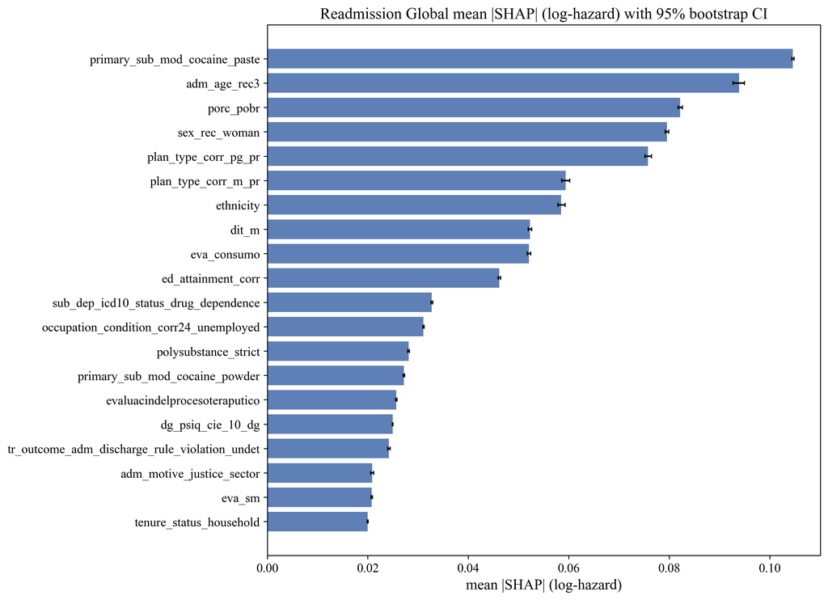

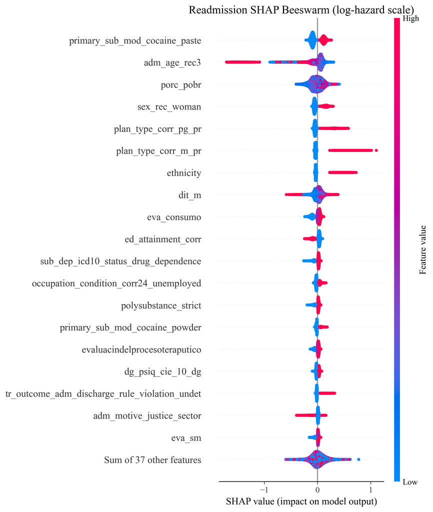

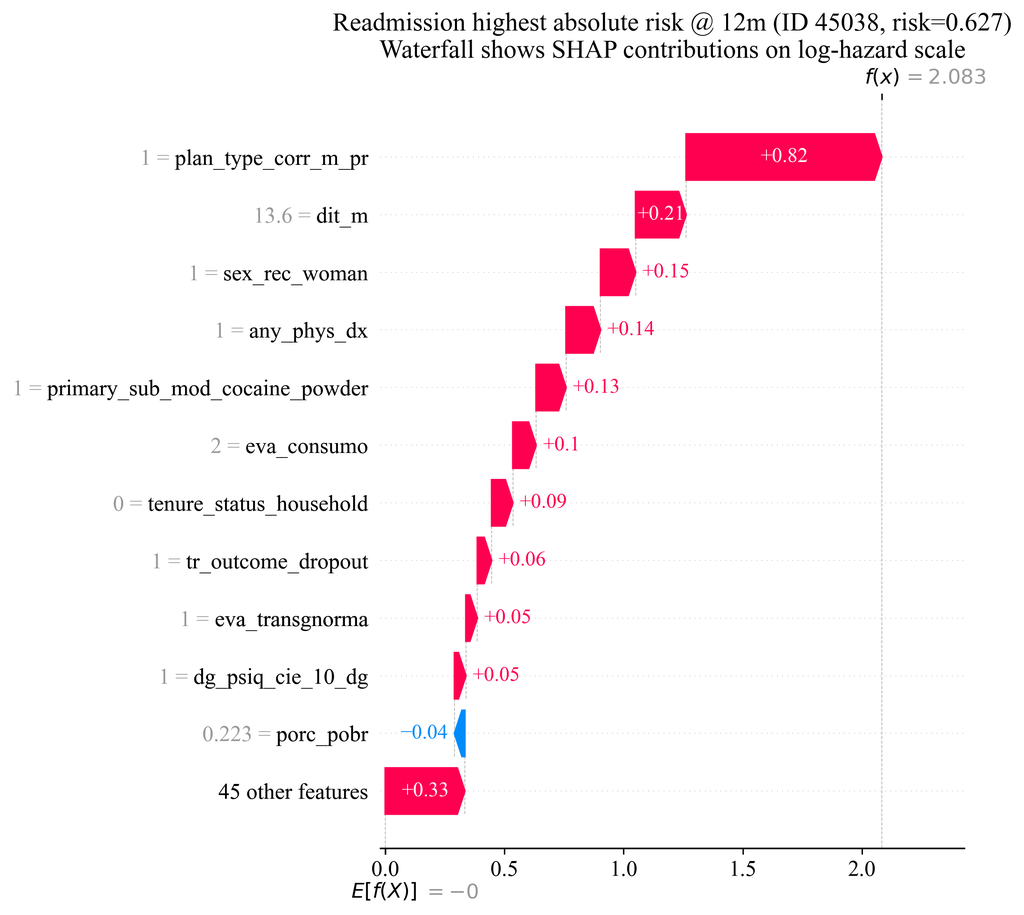

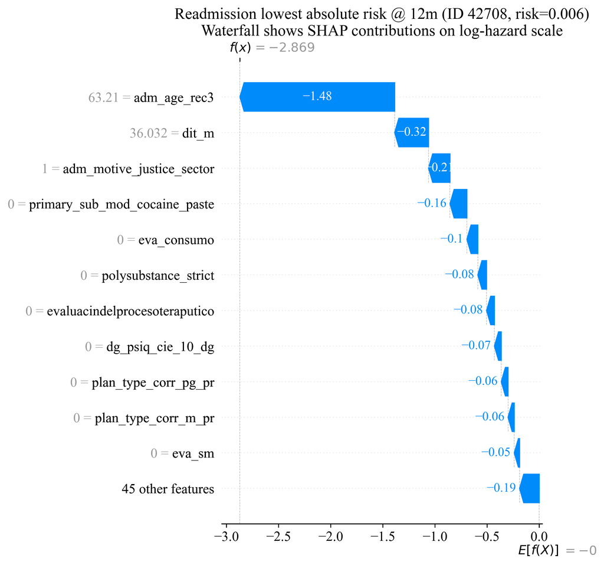

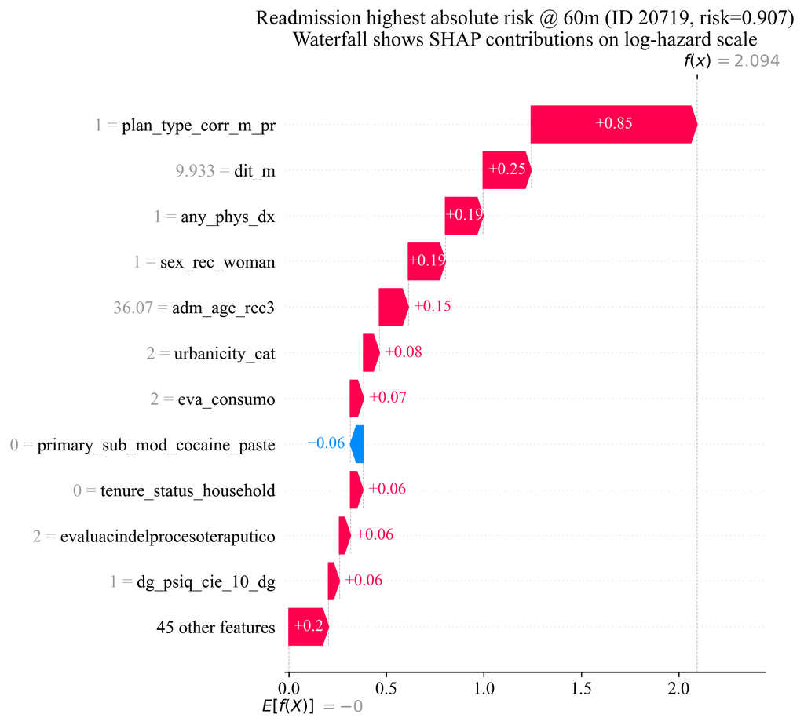

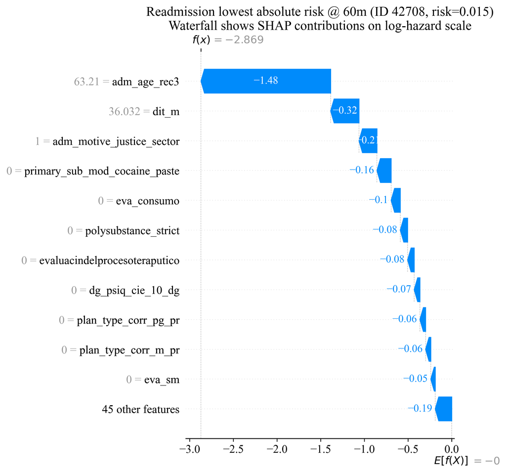

Death

SHAP values and global importance are on the **log-hazard** scale.

|  | outcome | feature | mean_abs_shap_log_hazard | ci95_low | ci95_high | bootstrap_n | n_bootstrap | ci_alpha |
| --- | --- | --- | --- | --- | --- | --- | --- | --- |
| 0 | Death | adm_age_rec3 | 0.543461 | 0.540851 | 0.545926 | 70803 | 500 | 0.05 |
| 1 | Death | primary_sub_mod_cocaine_paste | 0.203252 | 0.202581 | 0.203946 | 70803 | 500 | 0.05 |
| 2 | Death | prim_sub_freq_rec | 0.125585 | 0.125327 | 0.125880 | 70803 | 500 | 0.05 |
| 3 | Death | primary_sub_mod_cocaine_powder | 0.124073 | 0.123091 | 0.124998 | 70803 | 500 | 0.05 |
| 4 | Death | occupation_condition_corr24_unemployed | 0.102125 | 0.101854 | 0.102407 | 70803 | 500 | 0.05 |
| 5 | Death | any_phys_dx | 0.094501 | 0.093688 | 0.095293 | 70803 | 500 | 0.05 |
| 6 | Death | eva_ocupacion | 0.091042 | 0.090608 | 0.091488 | 70803 | 500 | 0.05 |
| 7 | Death | first_sub_used_alcohol | 0.078567 | 0.078349 | 0.078788 | 70803 | 500 | 0.05 |
| 8 | Death | sex_rec_woman | 0.067847 | 0.067479 | 0.068199 | 70803 | 500 | 0.05 |
| 9 | Death | eva_fisica | 0.066499 | 0.066074 | 0.066870 | 70803 | 500 | 0.05 |
| 10 | Death | cohabitation_with_couple_children | 0.061522 | 0.061354 | 0.061688 | 70803 | 500 | 0.05 |
| 11 | Death | adm_motive_sanitary_sector | 0.052548 | 0.052382 | 0.052696 | 70803 | 500 | 0.05 |
| 12 | Death | occupation_condition_corr24_inactive | 0.047408 | 0.047085 | 0.047727 | 70803 | 500 | 0.05 |
| 13 | Death | dit_m | 0.043657 | 0.043370 | 0.043936 | 70803 | 500 | 0.05 |
| 14 | Death | polysubstance_strict | 0.041868 | 0.041681 | 0.042063 | 70803 | 500 | 0.05 |
| 15 | Death | tenure_status_household | 0.040014 | 0.039866 | 0.040170 | 70803 | 500 | 0.05 |
| 16 | Death | primary_sub_mod_marijuana | 0.037308 | 0.036796 | 0.037821 | 70803 | 500 | 0.05 |
| 17 | Death | ed_attainment_corr | 0.035753 | 0.035593 | 0.035906 | 70803 | 500 | 0.05 |
| 18 | Death | tipo_de_vivienda_rec2_other_unknown | 0.032571 | 0.032328 | 0.032864 | 70803 | 500 | 0.05 |
| 19 | Death | plan_type_corr_pg_pr | 0.031736 | 0.031483 | 0.031981 | 70803 | 500 | 0.05 |

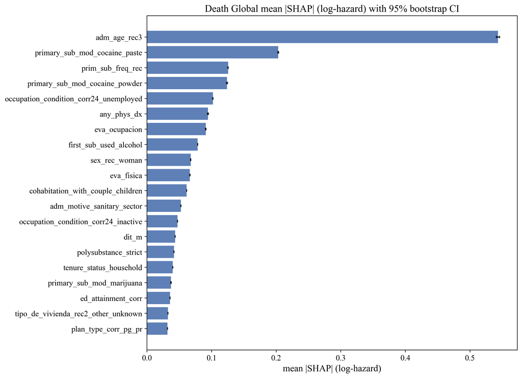

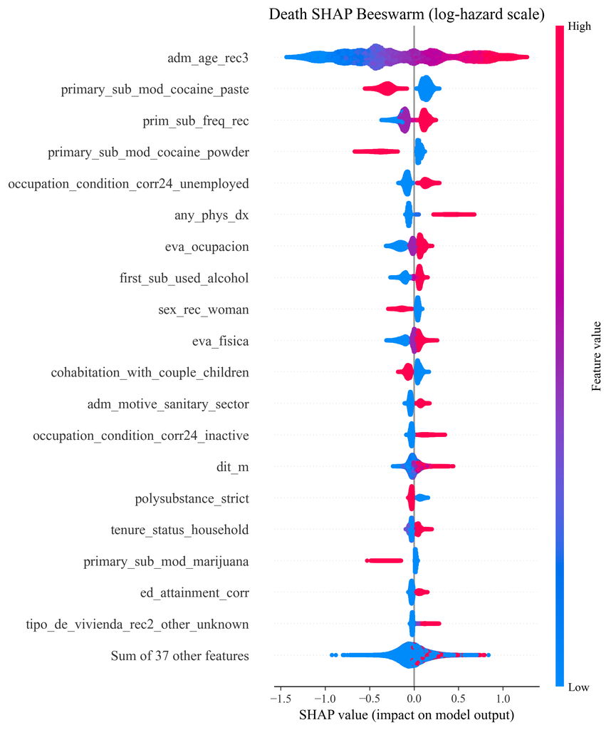

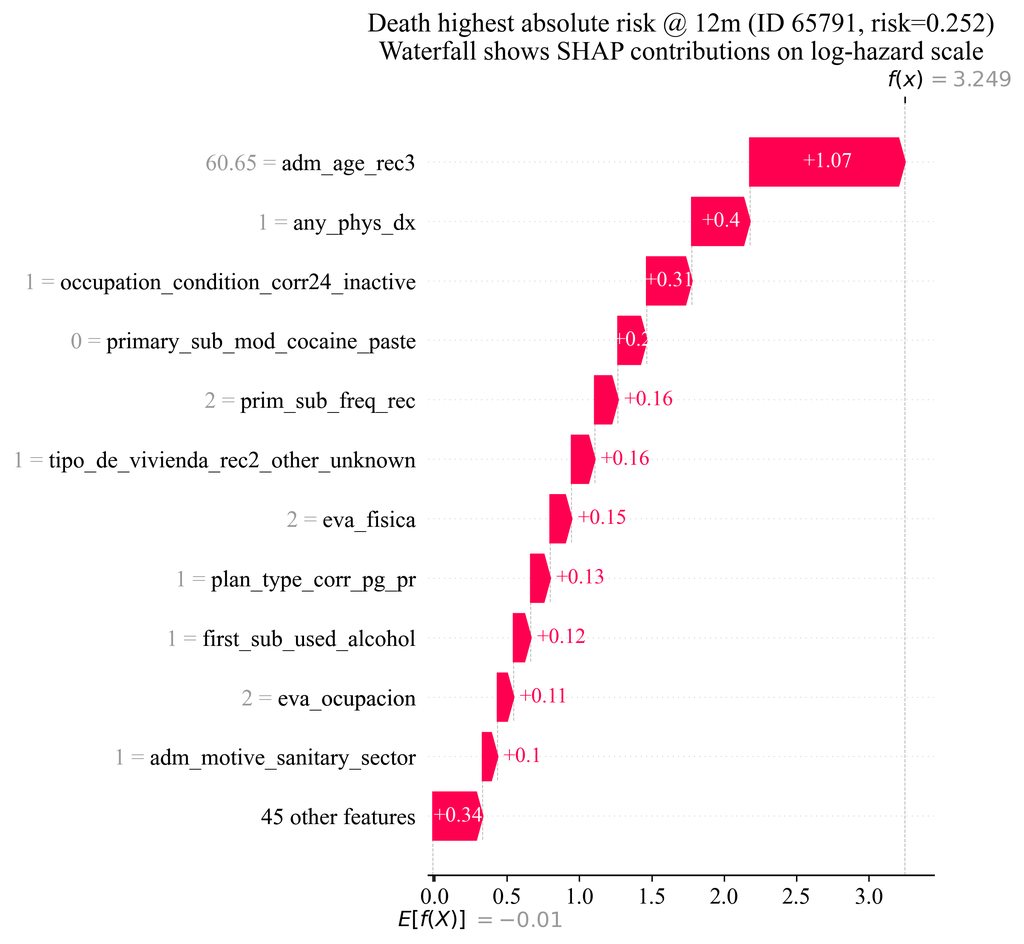

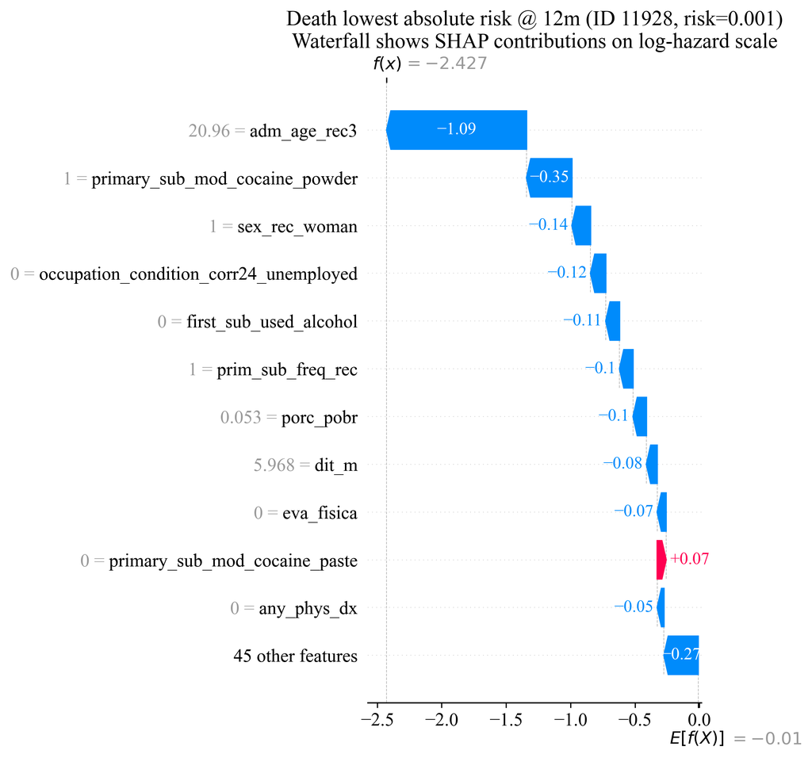

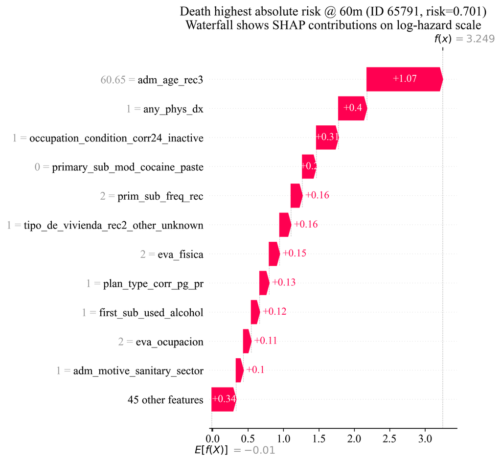

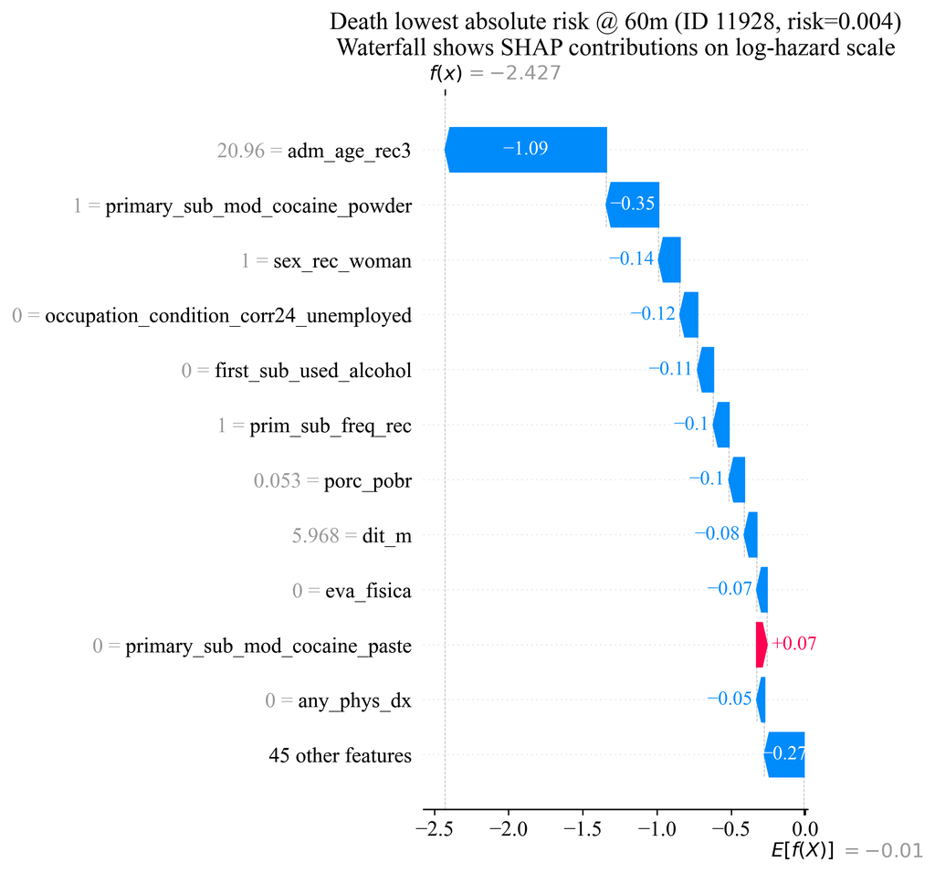

```python
        # Waterfall low risk
        plt.figure(figsize=(10, 7))
        shap.plots.waterfall(explanation[low_row], max_display=12, show=False)
        plt.title(
            f"{cfg['label']} lowest absolute risk @ {fmt_horizon(h)}m "
            f"(ID {low_id}, risk={low_risk:.3f})\n"
            f"Waterfall shows SHAP contributions on log-hazard scale"
        )
        plt.tight_layout()
        saved_plot_files.extend(save_current_figure("waterfall_low", outcome_name, h))
        plt.show()
        plt.close()

# -----------------------------
# 6) Export combined outputs
# -----------------------------
cases_file = os.path.join(OUT_DIR, f"xgb8_dual_shap_extreme_cases_{FILE_TAG}.csv")
horizon_file = os.path.join(OUT_DIR, f"xgb8_dual_horizon_sample_sizes_{FILE_TAG}.csv")
info_file = os.path.join(OUT_DIR, f"xgb8_dual_shap_run_info_{FILE_TAG}.json")

df_cases = pd.DataFrame(all_case_rows)
df_horizon = pd.DataFrame(horizon_rows)

df_cases.to_csv(cases_file, index=False)
df_horizon.to_csv(horizon_file, index=False)

saved_out_files.extend([cases_file, horizon_file])

run_info = {
    "source_bundle_tag": source_tag,
    "run_timestamp": RUN_TS,
    "file_tag_used_for_outputs": FILE_TAG,
    "source_files": {
        "shap": shap_file,
        "raw": raw_file,
        "baseline_hazards": hz_file,
        "cv_splits": split_file
    },
    "n_patients": int(X_all.shape[0]),
    "n_features": int(X_all.shape[1]),
    "horizons_months": [float(h) for h in horizons],
    "available_eval_times_months": [float(h) for h in available_horizons],
    "outcomes_processed": processed_outcomes,
    "shap_scale": "log-hazard",
    "global_importance_metric": "mean absolute SHAP (log-hazard)",
    "bootstrap_ci": {
        "enabled": bool(BOOTSTRAP_CI),
        "n_bootstrap": int(N_BOOTSTRAP) if BOOTSTRAP_CI else 0,
        "alpha": float(CI_ALPHA) if BOOTSTRAP_CI else None,
        "max_n_for_bootstrap": int(BOOTSTRAP_MAX_N) if BOOTSTRAP_CI else None
    },
    "multicollinearity_check": {
        "method": "pairwise Pearson correlation",
        "threshold_abs_r": float(CORR_THRESHOLD),
        "pairs_file": corr_pairs_file,
        "corr_matrix_file": corr_mat_file
    },
    "note": "Absolute risk is used for extreme-case ranking at each horizon. SHAP values remain log-hazard contributions."
}
with open(info_file, "w", encoding="utf-8") as f:
    json.dump(run_info, f, indent=2)

saved_out_files.append(info_file)

print("\nSaved plots to _figs (PNG/PDF):")
for p in saved_plot_files:
    print(" -", p)

print("\nSaved tables/metadata to _out:")
for p in saved_out_files:
    print(" -", p)
```

#### Stability of predictors

1. Assesses SHAP rank stability via bootstrap resampling.
2. Uses mean absolute SHAP for global importance.
3. Re-ranks features across 500 bootstrap samples.
4. Estimates variability of feature ranks.
5. Calculates frequency of inclusion in Top-30.
6. Flags features stable if ≥90% Top-30 frequency.
7. Reports SD, CV, and 95% rank intervals.
8. Applies composite rule for Cox selection.
9. Diagnoses CV denominator artifacts.
10. Exports detailed, summary, and audit files.

##### 5 Key Assumptions

1. Mean |SHAP| reflects true importance.
2. Bootstrap captures rank variability.
3. SHAP values come from unbiased models.
4. Top-30 is meaningful for Cox screening.
5. Rank stability reflects true signal.

```python
#@title Step 8c: SHAP Rank Stability for Cox Candidate Selection (Bootstrap + Top-K Inclusion Frequency)

import os
import json
import numpy as np
import pandas as pd
from IPython.display import display, Markdown

# -----------------------------
# 0) Preconditions + config
# -----------------------------
if "shap_data" not in globals():
    raise RuntimeError("Run Step 8 first (missing `shap_data`).")

OUT_DIR_LOCAL = globals().get("OUT_DIR", "_out")
SOURCE_TAG_LOCAL = globals().get("source_tag", pd.Timestamp.now().strftime("%Y%m%d_%H%M"))
RUN_TS = pd.Timestamp.now().strftime("%Y%m%d_%H%M")
os.makedirs(OUT_DIR_LOCAL, exist_ok=True)

# Your requested settings
N_BOOTSTRAP = 500
BOOT_SEED = 2125
MAX_N = 90000         # cap of patients used in each bootstrap run; if data has <= MAX_N, all are used
TOP_K = 30

# Stability thresholds
FREQ_THRESHOLD_PCT = 90.0
CV_THRESHOLD_PCT = 30.0
SD_THRESHOLD_RANK = 5.0
RANK_CI_UPPER_THRESHOLD = 45.0  # optional stricter upper CI bound for top-30-style stability

OUTCOME_KEYS = {
    "readm": {"label": "Readmission", "keys": ["shap_r_all", "shap_readm_all"]},
    "death": {"label": "Death", "keys": ["shap_d_all", "shap_death_all", "shap_mort_all"]},
}

feature_names = list(shap_data.get("feature_names", []))
if not feature_names and "X_all" in globals() and hasattr(X_all, "columns"):
    feature_names = list(X_all.columns)
if not feature_names:
    raise RuntimeError("Feature names not found (need shap_data['feature_names'] or X_all.columns).")

display(Markdown(
    f"### Step 8c: Bootstrap Rank Stability\n"
    f"- Bootstraps: **{N_BOOTSTRAP}**\n"
    f"- Seed: **{BOOT_SEED}**\n"
    f"- Top-K: **{TOP_K}**\n"
    f"- max_n: **{MAX_N}** (max patients used per bootstrap replicate)\n"
    f"- Primary stability: **freq_in_top_{TOP_K} >= {FREQ_THRESHOLD_PCT:.0f}%**"
))

# -----------------------------
# 1) Helpers
# -----------------------------
def first_existing_key(dct, keys):
    for k in keys:
        if k in dct:
            return k
    return None

def denominator_diagnostic(df, n_bins=5):
    x = df["cv_denominator_mean_rank"]
    bins = min(n_bins, int(x.nunique()))
    if bins < 2:
        return pd.DataFrame([{
            "rank_bin": "all",
            "n_features": int(len(df)),
            "median_mean_rank": float(df["mean_rank"].median()),
            "median_sd_rank": float(df["sd_rank"].median()),
            "median_cv_rank_pct": float(df["cv_rank_pct"].median()),
            f"stable_freq_ge_{int(FREQ_THRESHOLD_PCT)}pct": float(100.0 * df[f"stable_freq_ge_{int(FREQ_THRESHOLD_PCT)}pct"].mean()),
        }])

    tmp = df.copy()
    tmp["rank_bin"] = pd.qcut(tmp["mean_rank"], q=bins, duplicates="drop")
    out = (
        tmp.groupby("rank_bin", as_index=False)
           .agg(
               n_features=("feature", "count"),
               median_mean_rank=("mean_rank", "median"),
               median_sd_rank=("sd_rank", "median"),
               median_cv_rank_pct=("cv_rank_pct", "median"),
               median_freq_topk_pct=(f"freq_in_top_{TOP_K}_pct", "median"),
               stable_freq_pct=(f"stable_freq_ge_{int(FREQ_THRESHOLD_PCT)}pct", lambda s: 100.0 * float(np.mean(s))),
           )
    )
    out["rank_bin"] = out["rank_bin"].astype(str)
    return out

def bootstrap_rank_stability(shap_vals, feature_names, n_boot, seed, max_n, top_k):
    X = np.asarray(shap_vals, dtype=np.float32)
    if X.ndim != 2:
        raise ValueError(f"Expected 2D SHAP array, got shape {X.shape}")

    n, p = X.shape
    if p != len(feature_names):
        raise ValueError(f"SHAP has {p} features but feature_names has {len(feature_names)}.")

    rng = np.random.RandomState(seed)

    # Optional subsample for speed on very large cohorts
    if (max_n is not None) and (n > max_n):
        keep = rng.choice(n, size=max_n, replace=False)
        X = X[keep]
    n_eff = int(X.shape[0])

    absX = np.abs(X)
    point_importance = absX.mean(axis=0)

    point_order = np.argsort(-point_importance, kind="mergesort")
    point_rank = np.empty(p, dtype=np.float32)
    point_rank[point_order] = np.arange(1, p + 1, dtype=np.float32)

    rank_mat = np.empty((n_boot, p), dtype=np.float32)

    for b in range(n_boot):
        idx = rng.randint(0, n_eff, size=n_eff)
        imp_b = absX[idx].mean(axis=0)
        ord_b = np.argsort(-imp_b, kind="mergesort")
        rb = np.empty(p, dtype=np.float32)
        rb[ord_b] = np.arange(1, p + 1, dtype=np.float32)
        rank_mat[b] = rb

    mean_rank = rank_mat.mean(axis=0)
    median_rank = np.median(rank_mat, axis=0)
    sd_rank = rank_mat.std(axis=0, ddof=1 if n_boot > 1 else 0)
    cv_rank_pct = 100.0 * sd_rank / np.clip(mean_rank, 1e-12, None)
    q025 = np.quantile(rank_mat, 0.025, axis=0)
    q975 = np.quantile(rank_mat, 0.975, axis=0)

    # Key metric for Cox candidate stability
    freq_in_top_k = 100.0 * np.mean(rank_mat <= top_k, axis=0)

    df = pd.DataFrame({
        "feature": feature_names,
        "point_importance_mean_abs_shap": point_importance,
        "point_rank": point_rank,
        "mean_rank": mean_rank,
        "median_rank": median_rank,
        "sd_rank": sd_rank,
        "cv_rank_pct": cv_rank_pct,
        "rank_ci2p5": q025,
        "rank_ci97p5": q975,

        f"freq_in_top_{top_k}_pct": freq_in_top_k,

        # Explicit CV components (artifact audit)
        "cv_numerator_sd_rank": sd_rank,
        "cv_denominator_mean_rank": mean_rank,
        "mean_rank_pct_of_feature_count": 100.0 * mean_rank / p,

        # Stability flags
        f"stable_freq_ge_{int(FREQ_THRESHOLD_PCT)}pct": freq_in_top_k >= FREQ_THRESHOLD_PCT,
        "stable_cv_lt_30pct": cv_rank_pct < CV_THRESHOLD_PCT,
        "stable_abs_sd_le_5": sd_rank <= SD_THRESHOLD_RANK,
        "stable_composite_for_cox": (
            (freq_in_top_k >= FREQ_THRESHOLD_PCT) &
            (q975 <= RANK_CI_UPPER_THRESHOLD)
        ),

        "n_bootstrap": int(n_boot),
        "n_patients_used": int(n_eff),
    })

    df = df.sort_values(["mean_rank", "point_rank"], ascending=[True, True]).reset_index(drop=True)
    return df, n_eff

# -----------------------------
# 2) Run for readmission + death
# -----------------------------
details_all = []
diags_all = []
summary_rows = []
saved_files = []

for outcome_code, cfg in OUTCOME_KEYS.items():
    shap_key = first_existing_key(shap_data, cfg["keys"])
    if shap_key is None:
        print(f"Skipping {cfg['label']}: no SHAP key found in {cfg['keys']}")
        continue

    shap_vals = np.asarray(shap_data[shap_key], dtype=np.float32)

    df_detail, n_used = bootstrap_rank_stability(
        shap_vals=shap_vals,
        feature_names=feature_names,
        n_boot=N_BOOTSTRAP,
        seed=BOOT_SEED,
        max_n=MAX_N,
        top_k=TOP_K
    )
    df_detail.insert(0, "outcome", cfg["label"])

    df_diag = denominator_diagnostic(df_detail, n_bins=5)
    df_diag.insert(0, "outcome", cfg["label"])

    # Quantify denominator artifact directly
    pearson_r = float(df_detail["cv_denominator_mean_rank"].corr(df_detail["cv_rank_pct"], method="pearson"))
    spearman_r = float(df_detail["cv_denominator_mean_rank"].corr(df_detail["cv_rank_pct"], method="spearman"))

    summary_rows.append({
        "outcome": cfg["label"],
        "n_features": int(len(df_detail)),
        "n_patients_used": int(n_used),
        f"stable_freq_ge_{int(FREQ_THRESHOLD_PCT)}pct_n": int(df_detail[f"stable_freq_ge_{int(FREQ_THRESHOLD_PCT)}pct"].sum()),
        f"stable_freq_ge_{int(FREQ_THRESHOLD_PCT)}pct_pct": float(100.0 * df_detail[f"stable_freq_ge_{int(FREQ_THRESHOLD_PCT)}pct"].mean()),
        "stable_composite_for_cox_n": int(df_detail["stable_composite_for_cox"].sum()),
        "stable_composite_for_cox_pct": float(100.0 * df_detail["stable_composite_for_cox"].mean()),
        "pearson_meanRank_vs_cvRankPct": pearson_r,
        "spearman_meanRank_vs_cvRankPct": spearman_r
    })

    # Save per outcome
    f_detail = os.path.join(OUT_DIR_LOCAL, f"xgb8_dual_{outcome_code}_rank_stability_{SOURCE_TAG_LOCAL}.csv")
    f_diag = os.path.join(OUT_DIR_LOCAL, f"xgb8_dual_{outcome_code}_rank_denominator_diag_{SOURCE_TAG_LOCAL}.csv")
    df_detail.to_csv(f_detail, index=False)
    df_diag.to_csv(f_diag, index=False)
    saved_files.extend([f_detail, f_diag])

    details_all.append(df_detail)
    diags_all.append(df_diag)

if not details_all:
    raise RuntimeError("No outcome SHAP arrays found in shap_data.")

# -----------------------------
# 3) Save combined
# -----------------------------
df_all = pd.concat(details_all, ignore_index=True)
df_diag_all = pd.concat(diags_all, ignore_index=True)
df_summary = pd.DataFrame(summary_rows)

f_all = os.path.join(OUT_DIR_LOCAL, f"xgb8_dual_rank_stability_all_{SOURCE_TAG_LOCAL}.csv")
f_diag_all = os.path.join(OUT_DIR_LOCAL, f"xgb8_dual_rank_denominator_diag_all_{SOURCE_TAG_LOCAL}.csv")
f_summary = os.path.join(OUT_DIR_LOCAL, f"xgb8_dual_rank_stability_summary_{SOURCE_TAG_LOCAL}.csv")
f_info = os.path.join(OUT_DIR_LOCAL, f"xgb8_dual_rank_stability_run_info_{SOURCE_TAG_LOCAL}.json")

df_all.to_csv(f_all, index=False)
df_diag_all.to_csv(f_diag_all, index=False)
df_summary.to_csv(f_summary, index=False)

info = {
    "source_tag": SOURCE_TAG_LOCAL,
    "run_timestamp": RUN_TS,
    "n_bootstrap": int(N_BOOTSTRAP),
    "seed": int(BOOT_SEED),
    "max_n": int(MAX_N) if MAX_N is not None else None,
    "max_n_definition": "Maximum patients used in bootstrap stability analysis; if dataset size <= max_n, all patients are used.",
    "top_k": int(TOP_K),
    "primary_stability_rule": f"freq_in_top_{TOP_K}_pct >= {FREQ_THRESHOLD_PCT}",
    "secondary_metrics_reported": [
        "cv_rank_pct",
        "rank_ci2p5",
        "rank_ci97p5",
        "cv_numerator_sd_rank",
        "cv_denominator_mean_rank",
        "mean_rank_pct_of_feature_count"
    ]
}
with open(f_info, "w", encoding="utf-8") as f:
    json.dump(info, f, indent=2)

saved_files.extend([f_all, f_diag_all, f_summary, f_info])

# -----------------------------
# 4) Display
# -----------------------------
display(Markdown("### Rank Stability Summary"))
display(df_summary)

for out in df_all["outcome"].unique():
    display(Markdown(f"### {out}: Top {TOP_K} features by mean rank"))
    cols = [
        "feature",
        "point_rank",
        "mean_rank",
        f"freq_in_top_{TOP_K}_pct",
        "sd_rank",
        "rank_ci2p5",
        "rank_ci97p5",
        "cv_rank_pct",
        "cv_denominator_mean_rank",
        f"stable_freq_ge_{int(FREQ_THRESHOLD_PCT)}pct",
        "stable_composite_for_cox"
    ]
    display(
        df_all[df_all["outcome"] == out]
        .sort_values("mean_rank", ascending=True)
        .head(TOP_K)[cols]
    )

print("Saved files:")
for p in saved_files:
    print(" -", p)
```

Step 8c: Bootstrap Rank Stability

- Bootstraps: **500**

- Seed: **2125**

- Top-K: **30**

- max_n: **90000** (max patients used per bootstrap replicate)

- Primary stability: **freq_in_top_30 >= 90%**

Rank Stability Summary

|  | outcome | n_features | n_patients_used | stable_freq_ge_90pct_n | stable_freq_ge_90pct_pct | stable_composite_for_cox_n | stable_composite_for_cox_pct | pearson_meanRank_vs_cvRankPct | spearman_meanRank_vs_cvRankPct |
| --- | --- | --- | --- | --- | --- | --- | --- | --- | --- |
| 0 | Readmission | 56 | 70803 | 29 | 51.785714 | 29 | 51.785714 | -0.256769 | -0.069809 |
| 1 | Death | 56 | 70803 | 29 | 51.785714 | 29 | 51.785714 | 0.046921 | 0.143716 |

Readmission: Top 30 features by mean rank

|  | feature | point_rank | mean_rank | freq_in_top_30_pct | sd_rank | rank_ci2p5 | rank_ci97p5 | cv_rank_pct | cv_denominator_mean_rank | stable_freq_ge_90pct | stable_composite_for_cox |
| --- | --- | --- | --- | --- | --- | --- | --- | --- | --- | --- | --- |
| 0 | primary_sub_mod_cocaine_paste | 1.0 | 1.000000 | 100.0 | 0.000000 | 1.0 | 1.0 | 0.000000 | 1.000000 | True | True |
| 1 | adm_age_rec3 | 2.0 | 2.000000 | 100.0 | 0.000000 | 2.0 | 2.0 | 0.000000 | 2.000000 | True | True |
| 2 | porc_pobr | 3.0 | 3.000000 | 100.0 | 0.000000 | 3.0 | 3.0 | 0.000000 | 3.000000 | True | True |
| 3 | sex_rec_woman | 4.0 | 4.000000 | 100.0 | 0.000000 | 4.0 | 4.0 | 0.000000 | 4.000000 | True | True |
| 4 | plan_type_corr_pg_pr | 5.0 | 5.000000 | 100.0 | 0.000000 | 5.0 | 5.0 | 0.000000 | 5.000000 | True | True |
| 5 | plan_type_corr_m_pr | 6.0 | 6.040000 | 100.0 | 0.196156 | 6.0 | 7.0 | 3.247613 | 6.040000 | True | True |
| 6 | ethnicity | 7.0 | 6.960000 | 100.0 | 0.196156 | 6.0 | 7.0 | 2.818331 | 6.960000 | True | True |
| 7 | dit_m | 8.0 | 8.188000 | 100.0 | 0.391104 | 8.0 | 9.0 | 4.776547 | 8.188000 | True | True |
| 8 | eva_consumo | 9.0 | 8.812000 | 100.0 | 0.391104 | 8.0 | 9.0 | 4.438308 | 8.812000 | True | True |
| 9 | ed_attainment_corr | 10.0 | 10.000000 | 100.0 | 0.000000 | 10.0 | 10.0 | 0.000000 | 10.000000 | True | True |
| 10 | sub_dep_icd10_status_drug_dependence | 11.0 | 11.000000 | 100.0 | 0.000000 | 11.0 | 11.0 | 0.000000 | 11.000000 | True | True |
| 11 | occupation_condition_corr24_unemployed | 12.0 | 12.000000 | 100.0 | 0.000000 | 12.0 | 12.0 | 0.000000 | 12.000000 | True | True |
| 12 | polysubstance_strict | 13.0 | 13.000000 | 100.0 | 0.000000 | 13.0 | 13.0 | 0.000000 | 13.000000 | True | True |
| 13 | primary_sub_mod_cocaine_powder | 14.0 | 14.000000 | 100.0 | 0.000000 | 14.0 | 14.0 | 0.000000 | 14.000000 | True | True |
| 14 | evaluacindelprocesoteraputico | 15.0 | 15.000000 | 100.0 | 0.000000 | 15.0 | 15.0 | 0.000000 | 15.000000 | True | True |
| 15 | dg_psiq_cie_10_dg | 16.0 | 16.000000 | 100.0 | 0.000000 | 16.0 | 16.0 | 0.000000 | 16.000000 | True | True |
| 16 | tr_outcome_adm_discharge_rule_violation_undet | 17.0 | 17.000000 | 100.0 | 0.000000 | 17.0 | 17.0 | 0.000000 | 17.000000 | True | True |
| 17 | adm_motive_justice_sector | 18.0 | 18.260000 | 100.0 | 0.439073 | 18.0 | 19.0 | 2.404560 | 18.260000 | True | True |
| 18 | eva_sm | 19.0 | 18.740000 | 100.0 | 0.439073 | 18.0 | 19.0 | 2.342971 | 18.740000 | True | True |
| 19 | tenure_status_household | 20.0 | 20.000000 | 100.0 | 0.000000 | 20.0 | 20.0 | 0.000000 | 20.000000 | True | True |
| 20 | tr_outcome_referral | 21.0 | 21.000000 | 100.0 | 0.000000 | 21.0 | 21.0 | 0.000000 | 21.000000 | True | True |
| 21 | eva_ocupacion | 22.0 | 22.000000 | 100.0 | 0.000000 | 22.0 | 22.0 | 0.000000 | 22.000000 | True | True |
| 22 | prim_sub_freq_rec | 23.0 | 23.129999 | 100.0 | 0.336639 | 23.0 | 24.0 | 1.455424 | 23.129999 | True | True |
| 23 | eva_transgnorma | 24.0 | 23.870001 | 100.0 | 0.336639 | 23.0 | 24.0 | 1.410304 | 23.870001 | True | True |
| 24 | primary_sub_mod_marijuana | 25.0 | 25.004000 | 100.0 | 0.063182 | 25.0 | 25.0 | 0.252688 | 25.004000 | True | True |
| 25 | cohabitation_with_couple_children | 26.0 | 25.996000 | 100.0 | 0.063182 | 26.0 | 26.0 | 0.243045 | 25.996000 | True | True |
| 26 | eva_relinterp | 27.0 | 27.000000 | 100.0 | 0.000000 | 27.0 | 27.0 | 0.000000 | 27.000000 | True | True |
| 27 | dx_f6_personality | 28.0 | 28.004000 | 100.0 | 0.063182 | 28.0 | 28.0 | 0.225618 | 28.004000 | True | True |
| 28 | any_phys_dx | 29.0 | 28.996000 | 100.0 | 0.063182 | 29.0 | 29.0 | 0.217899 | 28.996000 | True | True |
| 29 | tr_outcome_dropout | 30.0 | 30.330000 | 67.0 | 0.470683 | 30.0 | 31.0 | 1.551874 | 30.330000 | False | False |

Death: Top 30 features by mean rank

|  | feature | point_rank | mean_rank | freq_in_top_30_pct | sd_rank | rank_ci2p5 | rank_ci97p5 | cv_rank_pct | cv_denominator_mean_rank | stable_freq_ge_90pct | stable_composite_for_cox |
| --- | --- | --- | --- | --- | --- | --- | --- | --- | --- | --- | --- |
| 56 | adm_age_rec3 | 1.0 | 1.000000 | 100.0 | 0.000000 | 1.0 | 1.0 | 0.000000 | 1.000000 | True | True |
| 57 | primary_sub_mod_cocaine_paste | 2.0 | 2.000000 | 100.0 | 0.000000 | 2.0 | 2.0 | 0.000000 | 2.000000 | True | True |
| 58 | prim_sub_freq_rec | 3.0 | 3.000000 | 100.0 | 0.000000 | 3.0 | 3.0 | 0.000000 | 3.000000 | True | True |
| 59 | primary_sub_mod_cocaine_powder | 4.0 | 4.000000 | 100.0 | 0.000000 | 4.0 | 4.0 | 0.000000 | 4.000000 | True | True |
| 60 | occupation_condition_corr24_unemployed | 5.0 | 5.000000 | 100.0 | 0.000000 | 5.0 | 5.0 | 0.000000 | 5.000000 | True | True |
| 61 | any_phys_dx | 6.0 | 6.000000 | 100.0 | 0.000000 | 6.0 | 6.0 | 0.000000 | 6.000000 | True | True |
| 62 | eva_ocupacion | 7.0 | 7.000000 | 100.0 | 0.000000 | 7.0 | 7.0 | 0.000000 | 7.000000 | True | True |
| 63 | first_sub_used_alcohol | 8.0 | 8.000000 | 100.0 | 0.000000 | 8.0 | 8.0 | 0.000000 | 8.000000 | True | True |
| 64 | sex_rec_woman | 9.0 | 9.000000 | 100.0 | 0.000000 | 9.0 | 9.0 | 0.000000 | 9.000000 | True | True |
| 65 | eva_fisica | 10.0 | 10.000000 | 100.0 | 0.000000 | 10.0 | 10.0 | 0.000000 | 10.000000 | True | True |
| 66 | cohabitation_with_couple_children | 11.0 | 11.000000 | 100.0 | 0.000000 | 11.0 | 11.0 | 0.000000 | 11.000000 | True | True |
| 67 | adm_motive_sanitary_sector | 12.0 | 12.000000 | 100.0 | 0.000000 | 12.0 | 12.0 | 0.000000 | 12.000000 | True | True |
| 68 | occupation_condition_corr24_inactive | 13.0 | 13.000000 | 100.0 | 0.000000 | 13.0 | 13.0 | 0.000000 | 13.000000 | True | True |
| 69 | dit_m | 14.0 | 14.000000 | 100.0 | 0.000000 | 14.0 | 14.0 | 0.000000 | 14.000000 | True | True |
| 70 | polysubstance_strict | 15.0 | 15.000000 | 100.0 | 0.000000 | 15.0 | 15.0 | 0.000000 | 15.000000 | True | True |
| 71 | tenure_status_household | 16.0 | 16.000000 | 100.0 | 0.000000 | 16.0 | 16.0 | 0.000000 | 16.000000 | True | True |
| 72 | primary_sub_mod_marijuana | 17.0 | 17.000000 | 100.0 | 0.000000 | 17.0 | 17.0 | 0.000000 | 17.000000 | True | True |
| 73 | ed_attainment_corr | 18.0 | 18.000000 | 100.0 | 0.000000 | 18.0 | 18.0 | 0.000000 | 18.000000 | True | True |
| 74 | tipo_de_vivienda_rec2_other_unknown | 19.0 | 19.000000 | 100.0 | 0.000000 | 19.0 | 19.0 | 0.000000 | 19.000000 | True | True |
| 75 | plan_type_corr_pg_pr | 20.0 | 20.000000 | 100.0 | 0.000000 | 20.0 | 20.0 | 0.000000 | 20.000000 | True | True |
| 76 | porc_pobr | 21.0 | 21.000000 | 100.0 | 0.000000 | 21.0 | 21.0 | 0.000000 | 21.000000 | True | True |
| 77 | marital_status_rec_single | 22.0 | 22.000000 | 100.0 | 0.000000 | 22.0 | 22.0 | 0.000000 | 22.000000 | True | True |
| 78 | eva_sm | 23.0 | 23.000000 | 100.0 | 0.000000 | 23.0 | 23.0 | 0.000000 | 23.000000 | True | True |
| 79 | tr_outcome_dropout | 24.0 | 24.011999 | 100.0 | 0.108994 | 24.0 | 24.0 | 0.453916 | 24.011999 | True | True |
| 80 | sub_dep_icd10_status_drug_dependence | 25.0 | 24.988001 | 100.0 | 0.108994 | 25.0 | 25.0 | 0.436187 | 24.988001 | True | True |
| 81 | dx_f_any_severe_mental | 26.0 | 26.122000 | 100.0 | 0.389126 | 26.0 | 27.0 | 1.489650 | 26.122000 | True | True |
| 82 | tr_outcome_adm_discharge_rule_violation_undet | 27.0 | 27.318001 | 100.0 | 0.744301 | 26.0 | 29.0 | 2.724579 | 27.318001 | True | True |
| 83 | marital_status_rec_separated_divorced_annulled... | 28.0 | 27.822001 | 100.0 | 0.703780 | 27.0 | 29.0 | 2.529579 | 27.822001 | True | True |
| 84 | evaluacindelprocesoteraputico | 29.0 | 28.738001 | 100.0 | 0.483552 | 28.0 | 29.0 | 1.682624 | 28.738001 | True | True |
| 85 | eva_fam | 30.0 | 30.177999 | 82.2 | 0.382896 | 30.0 | 31.0 | 1.268793 | 30.177999 | False | False |

1. Shifts focus from rank stability to predictor profiling.
2. Ranks features by mean absolute SHAP.
3. Adds importance tiers (Dominant to Minor).
4. Merges Step 8 stability into ranking table.
5. Flags predictors stable at ≥90% Top-K.
6. Adds exploratory SHAP direction analysis.
7. Uses bootstrap CI to label risk direction.
8. Identifies risk-decreasing predictors separately.
9. Produces structured CSV and Excel outputs.
10. Keeps analysis data-driven, no interpretation.

**Assumptions**:

1. Mean |SHAP| reflects overall influence.
2. Stability from Step 8 remains valid here.
3. Direction via SHAP delta is informative.
4. Quartile contrasts capture numeric effects.
5. Direction labels are exploratory, not causal.

```python
#@title Step 9: Predictor Analysis (No Clinical Interpretation, Step-8 Aligned)

import os
import re
import glob
import json
import pickle
import numpy as np
import pandas as pd
from IPython.display import display, Markdown

# -----------------------------
# 0) Config
# -----------------------------
IN_DIR = "_out"
OUT_DIR = "_out"
os.makedirs(OUT_DIR, exist_ok=True)

TOP_N_KEY = 15
TOP_N_PROTECTIVE = 10
TOP_K_STABILITY = 30
STABILITY_FREQ_THRESHOLD = 90.0

# Direction analysis (exploratory) for top-N by importance only
DIRECTION_TOP_N = 20
DIRECTION_N_BOOT = 300
DIRECTION_SEED = 2125
DIRECTION_MAX_N = 30000
DIRECTION_MIN_VALID_N = 300
DIRECTION_MIN_GROUP_N = 40

OUTCOME_CFG = {
    "readm": {
        "label": "Readmission",
        "shap_key_candidates": ["shap_r_all", "shap_readm_all"],
    },
    "death": {
        "label": "Death",
        "shap_key_candidates": ["shap_d_all", "shap_death_all", "shap_mort_all"],
    },
}

TS_RE = re.compile(r"_(\d{8}_\d{4})\.pkl$")

# -----------------------------
# 1) Helpers
# -----------------------------
def _tag_from_path(path):
    m = TS_RE.search(os.path.basename(path))
    return m.group(1) if m else None

def pick_latest_shap_bundle(in_dir):
    shap_files = glob.glob(os.path.join(in_dir, "xgb6_corr_DUAL_SHAP_Aggregated_*.pkl"))
    candidates = []
    for f in shap_files:
        tag = _tag_from_path(f)
        if not tag:
            continue
        dt = pd.to_datetime(tag, format="%Y%m%d_%H%M", errors="coerce")
        if pd.notna(dt):
            candidates.append((dt, tag, f))
    if not candidates:
        raise FileNotFoundError("No xgb6_corr_DUAL_SHAP_Aggregated_*.pkl found in _out.")
    candidates.sort(key=lambda x: x[0])
    return candidates[-1][1], candidates[-1][2]

def find_first_key(dct, keys):
    for k in keys:
        if k in dct:
            return k
    return None

def assign_importance_tier(rel_pct):
    if rel_pct >= 50.0:
        return "DOMINANT (>=50% max)"
    if rel_pct >= 20.0:
        return "MAJOR (20-50% max)"
    if rel_pct >= 10.0:
        return "MODERATE (10-20% max)"
    return "MINOR (<10% max)"

def pick_freq_col(columns, top_k=30):
    exact = f"freq_in_top_{top_k}_pct"
    if exact in columns:
        return exact
    cands = []
    for c in columns:
        m = re.match(r"^freq_in_top_(\d+)_pct$", str(c))
        if m:
            k = int(m.group(1))
            cands.append((abs(k - top_k), k, c))
    if not cands:
        return None
    cands.sort(key=lambda x: (x[0], x[1]))
    return cands[0][2]

def load_stability_table(outcome_code, source_tag, out_dir):
    exact_paths = [
        os.path.join(out_dir, f"xgb8_dual_{outcome_code}_rank_stability_{source_tag}.csv"),
        os.path.join(out_dir, f"xgb8_dual_{outcome_code}_rank_stability_cv_{source_tag}.csv"),
    ]
    for p in exact_paths:
        if os.path.exists(p):
            return pd.read_csv(p), p

    wildcard_patterns = [
        os.path.join(out_dir, f"xgb8_dual_{outcome_code}_rank_stability_*.csv"),
        os.path.join(out_dir, f"xgb8_dual_{outcome_code}_rank_stability_cv_*.csv"),
    ]
    files = []
    for pat in wildcard_patterns:
        files.extend(glob.glob(pat))
    if not files:
        return None, None

    files = sorted(files, key=os.path.getmtime)
    p = files[-1]
    return pd.read_csv(p), p

def bootstrap_diff_means(group_hi, group_lo, n_boot=300, seed=2125):
    hi = np.asarray(group_hi, dtype=float).ravel()
    lo = np.asarray(group_lo, dtype=float).ravel()
    hi = hi[np.isfinite(hi)]
    lo = lo[np.isfinite(lo)]
    if len(hi) == 0 or len(lo) == 0:
        return np.nan, np.nan, np.nan, 0

    rng = np.random.RandomState(seed)
    point = float(np.mean(hi) - np.mean(lo))
    bvals = np.empty(n_boot, dtype=float)

    n_hi = len(hi)
    n_lo = len(lo)

    for b in range(n_boot):
        s_hi = hi[rng.randint(0, n_hi, size=n_hi)]
        s_lo = lo[rng.randint(0, n_lo, size=n_lo)]
        bvals[b] = np.mean(s_hi) - np.mean(s_lo)

    ci_low, ci_high = np.quantile(bvals, [0.025, 0.975])
    return point, float(ci_low), float(ci_high), int(n_hi + n_lo)

def direction_from_ci(ci_low, ci_high):
    if np.isfinite(ci_low) and ci_low > 0:
        return "Risk-Increasing"
    if np.isfinite(ci_high) and ci_high < 0:
        return "Risk-Decreasing"
    if np.isfinite(ci_low) and np.isfinite(ci_high):
        return "Mixed/Uncertain"
    return "Unknown"

def direction_bootstrap_feature(x_raw, s_raw, n_boot, seed, max_n, min_valid_n, min_group_n):
    x = pd.to_numeric(pd.Series(x_raw), errors="coerce").to_numpy(dtype=float)
    s = np.asarray(s_raw, dtype=float).ravel()
    m = np.isfinite(x) & np.isfinite(s)
    x = x[m]
    s = s[m]

    if len(x) < min_valid_n:
        return {
            "direction_method": "insufficient_n",
            "delta_point": np.nan,
            "delta_ci_low": np.nan,
            "delta_ci_high": np.nan,
            "direction_n": int(len(x)),
            "direction_label": "Unknown",
        }

    rng = np.random.RandomState(seed)
    if (max_n is not None) and (len(x) > max_n):
        keep = rng.choice(len(x), size=max_n, replace=False)
        x = x[keep]
        s = s[keep]

    vals = np.unique(x[np.isfinite(x)])
    vals_round = np.unique(np.round(vals, 10))
    is_binary = (len(vals_round) <= 2) and set(vals_round).issubset({0.0, 1.0})

    if is_binary:
        g_lo = s[x == 0.0]
        g_hi = s[x == 1.0]
        method = "binary_x1_minus_x0"
    else:
        q1 = np.nanquantile(x, 0.25)
        q3 = np.nanquantile(x, 0.75)
        g_lo = s[x <= q1]   # Q1
        g_hi = s[x >= q3]   # Q4
        method = "quartile_q4_minus_q1"

    if (len(g_lo) < min_group_n) or (len(g_hi) < min_group_n):
        return {
            "direction_method": method,
            "delta_point": np.nan,
            "delta_ci_low": np.nan,
            "delta_ci_high": np.nan,
            "direction_n": int(len(x)),
            "direction_label": "Unknown",
        }

    point, lo, hi, n_used = bootstrap_diff_means(g_hi, g_lo, n_boot=n_boot, seed=seed)
    return {
        "direction_method": method,
        "delta_point": point,
        "delta_ci_low": lo,
        "delta_ci_high": hi,
        "direction_n": int(n_used),
        "direction_label": direction_from_ci(lo, hi),
    }
```

```python
def format_key_list(df, n=10, freq_col=None):
    rows = []
    for i, r in enumerate(df.head(n).itertuples(index=False), 1):
        if freq_col and hasattr(r, freq_col) and pd.notna(getattr(r, freq_col)):
            rows.append(f"{i}. {r.feature} (|SHAP|={r.mean_abs_shap_log_hazard:.4f}, freq={getattr(r, freq_col):.1f}%)")
        else:
            rows.append(f"{i}. {r.feature} (|SHAP|={r.mean_abs_shap_log_hazard:.4f})")
    return "\n".join(rows)

# -----------------------------
# 2) Load SHAP source
# -----------------------------
source_tag, shap_file = pick_latest_shap_bundle(IN_DIR)
with open(shap_file, "rb") as f:
    shap_data = pickle.load(f)

if "X_all" not in shap_data or "feature_names" not in shap_data:
    raise KeyError("SHAP file missing X_all and/or feature_names.")

X_all = shap_data["X_all"]
feature_names = list(shap_data["feature_names"])

if not isinstance(X_all, pd.DataFrame):
    X_all = pd.DataFrame(X_all, columns=feature_names)

if list(X_all.columns) != feature_names:
    X_all = X_all.reindex(columns=feature_names)

X_num = X_all.apply(pd.to_numeric, errors="coerce")
X_mat = X_num.to_numpy(dtype=float)
f2i = {f: i for i, f in enumerate(feature_names)}

display(Markdown(
    f"### Step 9 Predictor Analysis\n"
    f"- Source tag: **{source_tag}**\n"
    f"- Patients: **{X_all.shape[0]}**\n"
    f"- Features: **{X_all.shape[1]}**\n"
    f"- Direction method: **bootstrap CI on SHAP delta** (top {DIRECTION_TOP_N} features per outcome)"
))

# -----------------------------
# 3) Build per-outcome predictor tables
# -----------------------------
per_outcome_tables = []
tier_rows = []
summary_rows = []
take_home_rows = []
protective_rows = []
stability_files_used = []

for oc, cfg in OUTCOME_CFG.items():
    shap_key = find_first_key(shap_data, cfg["shap_key_candidates"])
    if shap_key is None:
        print(f"Skipping {cfg['label']}: SHAP key not found ({cfg['shap_key_candidates']}).")
        continue

    S = np.asarray(shap_data[shap_key], dtype=float)
    if S.shape != X_mat.shape:
        raise ValueError(f"{cfg['label']} SHAP shape mismatch: {S.shape} vs {X_mat.shape}")

    imp = np.abs(S).mean(axis=0)
    df = pd.DataFrame({
        "feature": feature_names,
        "mean_abs_shap_log_hazard": imp,
    }).sort_values("mean_abs_shap_log_hazard", ascending=False).reset_index(drop=True)

    df["rank"] = np.arange(1, len(df) + 1, dtype=int)
    max_imp = float(df["mean_abs_shap_log_hazard"].max()) if len(df) else np.nan
    df["rel_to_max_pct"] = 100.0 * df["mean_abs_shap_log_hazard"] / max_imp if np.isfinite(max_imp) and max_imp > 0 else np.nan
    df["importance_tier"] = df["rel_to_max_pct"].apply(assign_importance_tier)

    # Optional stability merge from Step 8c
    stab_df, stab_path = load_stability_table(oc, source_tag, OUT_DIR)
    freq_col = None
    if stab_df is not None and len(stab_df):
        if "outcome_code" in stab_df.columns:
            tmp = stab_df[stab_df["outcome_code"].astype(str).str.lower() == oc]
            if len(tmp):
                stab_df = tmp
        if "outcome" in stab_df.columns:
            tmp = stab_df[stab_df["outcome"].astype(str).str.lower() == cfg["label"].lower()]
            if len(tmp):
                stab_df = tmp

        freq_col = pick_freq_col(stab_df.columns, TOP_K_STABILITY)
        keep = ["feature"]
        for c in ["mean_rank", "cv_rank_pct", "rank_ci2p5", "rank_ci97p5", freq_col]:
            if c and c in stab_df.columns:
                keep.append(c)

        stab_df = stab_df[keep].drop_duplicates("feature")
        df = df.merge(stab_df, on="feature", how="left")

        if freq_col and freq_col in df.columns:
            df[f"stable_freq_ge_{int(STABILITY_FREQ_THRESHOLD)}pct"] = df[freq_col] >= STABILITY_FREQ_THRESHOLD

        stability_files_used.append(stab_path)

    # Direction bootstrap for top-N only (exploratory)
    df["direction_method"] = "not_evaluated"
    df["delta_point"] = np.nan
    df["delta_ci_low"] = np.nan
    df["delta_ci_high"] = np.nan
    df["direction_n"] = np.nan
    df["direction_label"] = "Not evaluated"

    top_features_for_direction = df.head(DIRECTION_TOP_N)["feature"].tolist()
    for feat in top_features_for_direction:
        j = f2i[feat]
        res = direction_bootstrap_feature(
            x_raw=X_mat[:, j],
            s_raw=S[:, j],
            n_boot=DIRECTION_N_BOOT,
            seed=DIRECTION_SEED + j,
            max_n=DIRECTION_MAX_N,
            min_valid_n=DIRECTION_MIN_VALID_N,
            min_group_n=DIRECTION_MIN_GROUP_N,
        )
        idx = df.index[df["feature"] == feat][0]
        df.loc[idx, "direction_method"] = res["direction_method"]
        df.loc[idx, "delta_point"] = res["delta_point"]
        df.loc[idx, "delta_ci_low"] = res["delta_ci_low"]
        df.loc[idx, "delta_ci_high"] = res["delta_ci_high"]
        df.loc[idx, "direction_n"] = res["direction_n"]
        df.loc[idx, "direction_label"] = res["direction_label"]

    # Dominance stats
    top1 = float(df.loc[0, "mean_abs_shap_log_hazard"]) if len(df) > 0 else np.nan
    top2 = float(df.loc[1, "mean_abs_shap_log_hazard"]) if len(df) > 1 else np.nan
    top2_ratio = (top1 / top2) if np.isfinite(top1) and np.isfinite(top2) and top2 > 0 else np.nan

    df.insert(0, "outcome", cfg["label"])
    per_outcome_tables.append(df)

    # Tier summary
    tier_order = ["DOMINANT (>=50% max)", "MAJOR (20-50% max)", "MODERATE (10-20% max)", "MINOR (<10% max)"]
    for t in tier_order:
        dft = df[df["importance_tier"] == t].copy()
        if len(dft) == 0:
            continue
        tier_rows.append({
            "outcome": cfg["label"],
            "tier": t,
            "n_features": int(len(dft)),
            "importance_min": float(dft["mean_abs_shap_log_hazard"].min()),
            "importance_max": float(dft["mean_abs_shap_log_hazard"].max()),
            "features": ", ".join(dft["feature"].tolist()),
        })

    summary_row = {
        "outcome": cfg["label"],
        "n_features": int(len(df)),
        "top1_feature": df.loc[0, "feature"] if len(df) else None,
        "top1_importance": top1,
        "top2_feature": df.loc[1, "feature"] if len(df) > 1 else None,
        "top2_importance": top2,
        "top1_to_top2_ratio": top2_ratio,
    }
```

```python
    if freq_col and freq_col in df.columns:
        summary_row[f"top{TOP_N_KEY}_stable_freq_ge_{int(STABILITY_FREQ_THRESHOLD)}pct_n"] = int(
            df.head(TOP_N_KEY)[f"stable_freq_ge_{int(STABILITY_FREQ_THRESHOLD)}pct"].fillna(False).sum()
        )
    summary_rows.append(summary_row)

    # Take-home list (data only, no interpretation)
    key_txt = format_key_list(df, n=TOP_N_KEY, freq_col=freq_col if freq_col in df.columns else None)
    take_home_rows.append({
        "Risk Profile": cfg["label"],
        "Key Predictors (Ranked; mean |SHAP| on log-hazard scale)": key_txt,
        "Notes": "Purely data-driven ranking from aggregated CV-SHAP."
    })

    # Protective list (direction exploratory only)
    prot = df[df["direction_label"] == "Risk-Decreasing"].sort_values("mean_abs_shap_log_hazard", ascending=False)
    prot_txt = format_key_list(prot, n=TOP_N_PROTECTIVE, freq_col=freq_col if freq_col in prot.columns else None) if len(prot) else "None identified among evaluated features."
    protective_rows.append({
        "Outcome": cfg["label"],
        "Top Risk-Decreasing Predictors (exploratory)": prot_txt,
        "Direction basis": "Bootstrap CI of SHAP delta (Q4-Q1 for numeric, x=1-x=0 for binary)."
    })

# -----------------------------
# 4) Combine + display
# -----------------------------
if not per_outcome_tables:
    raise RuntimeError("No outcome tables created (missing SHAP arrays).")

predictor_table = pd.concat(per_outcome_tables, ignore_index=True)
tier_table = pd.DataFrame(tier_rows)
summary_table = pd.DataFrame(summary_rows)
take_home_msg = pd.DataFrame(take_home_rows)
protective_msg = pd.DataFrame(protective_rows)

display(Markdown("### Predictor Table"))
display(predictor_table)

display(Markdown("### Importance Tier Summary"))
display(tier_table)

display(Markdown("### Outcome Summary"))
display(summary_table)

display(Markdown("### Key Predictors (No Clinical Interpretation)"))
pd.set_option("display.max_colwidth", None)
display(take_home_msg.style.set_properties(**{"text-align": "left", "white-space": "pre-wrap"}))

display(Markdown("### Risk-Decreasing Predictors (Exploratory Direction Only)"))
display(protective_msg.style.set_properties(**{"text-align": "left", "white-space": "pre-wrap"}))

# Quick sanity check for known features (if present)
check_features = ["porc_pobr", "adm_age_rec3", "sex_rec_woman"]
check_df = predictor_table[predictor_table["feature"].isin(check_features)][
    ["outcome", "feature", "rank", "mean_abs_shap_log_hazard", "direction_method", "delta_point", "delta_ci_low", "delta_ci_high", "direction_label"]
].sort_values(["outcome", "rank"])
if len(check_df):
    display(Markdown("### Direction Sanity Check"))
    display(check_df)

# -----------------------------
# 5) Save outputs
# -----------------------------
base = f"xgb9_dual_predictor_analysis_no_clinical_{source_tag}"
f_pred = os.path.join(OUT_DIR, f"{base}.csv")
f_tier = os.path.join(OUT_DIR, f"xgb9_dual_importance_tiers_{source_tag}.csv")
f_sum = os.path.join(OUT_DIR, f"xgb9_dual_predictor_summary_{source_tag}.csv")
f_take = os.path.join(OUT_DIR, f"xgb9_dual_takehome_no_clinical_{source_tag}.csv")
f_prot = os.path.join(OUT_DIR, f"xgb9_dual_protective_no_clinical_{source_tag}.csv")
f_xlsx = os.path.join(OUT_DIR, f"{base}.xlsx")
f_info = os.path.join(OUT_DIR, f"xgb9_dual_predictor_run_info_{source_tag}.json")

predictor_table.to_csv(f_pred, index=False)
tier_table.to_csv(f_tier, index=False)
summary_table.to_csv(f_sum, index=False)
take_home_msg.to_csv(f_take, index=False)
protective_msg.to_csv(f_prot, index=False)

with pd.ExcelWriter(f_xlsx) as writer:
    predictor_table.to_excel(writer, sheet_name="Predictors", index=False)
    tier_table.to_excel(writer, sheet_name="Importance_Tiers", index=False)
    summary_table.to_excel(writer, sheet_name="Summary", index=False)
    take_home_msg.to_excel(writer, sheet_name="TakeHome_NoClinical", index=False)
    protective_msg.to_excel(writer, sheet_name="Protective_NoClinical", index=False)

run_info = {
    "source_tag": source_tag,
    "shap_file": shap_file,
    "stability_files_used": sorted(set([p for p in stability_files_used if p])),
    "top_n_key": int(TOP_N_KEY),
    "top_k_stability": int(TOP_K_STABILITY),
    "stability_freq_threshold_pct": float(STABILITY_FREQ_THRESHOLD),
    "direction_analysis": {
        "top_n_features_per_outcome": int(DIRECTION_TOP_N),
        "n_bootstrap": int(DIRECTION_N_BOOT),
        "seed": int(DIRECTION_SEED),
        "max_n": int(DIRECTION_MAX_N),
        "min_valid_n": int(DIRECTION_MIN_VALID_N),
        "min_group_n": int(DIRECTION_MIN_GROUP_N),
        "rule": "Risk-Increasing if CI_low>0; Risk-Decreasing if CI_high<0; else Mixed/Uncertain."
    },
    "notes": [
        "No clinical interpretation text included.",
        "SHAP magnitude is on log-hazard scale.",
        "Direction labels are exploratory and not causal."
    ]
}
with open(f_info, "w", encoding="utf-8") as f:
    json.dump(run_info, f, indent=2)

print("Saved:")
for p in [f_pred, f_tier, f_sum, f_take, f_prot, f_xlsx, f_info]:
    print(" -", p)
```

Step 9 Predictor Analysis

- Source tag: **20260226_2047**

- Patients: **70803**

- Features: **56**

- Direction method: **bootstrap CI on SHAP delta** (top 20 features per outcome)

Predictor Table

|  | outcome | feature | mean_abs_shap_log_hazard | rank | rel_to_max_pct | importance_tier | mean_rank | cv_rank_pct | rank_ci2p5 | rank_ci97p5 | freq_in_top_30_pct | stable_freq_ge_90pct | direction_method | delta_point | delta_ci_low | delta_ci_high | direction_n | direction_label |
| --- | --- | --- | --- | --- | --- | --- | --- | --- | --- | --- | --- | --- | --- | --- | --- | --- | --- | --- |
| 0 | Readmission | primary_sub_mod_cocaine_paste | 0.104617 | 1 | 100.000000 | DOMINANT (>=50% max) | 1.0 | 0.0 | 1.0 | 1.0 | 100.0 | True | binary_x1_minus_x0 | 0.214909 | 0.214265 | 0.215585 | 30000.0 | Risk-Increasing |
| 1 | Readmission | adm_age_rec3 | 0.093939 | 2 | 89.793357 | DOMINANT (>=50% max) | 2.0 | 0.0 | 2.0 | 2.0 | 100.0 | True | quartile_q4_minus_q1 | -0.219600 | -0.226405 | -0.212662 | 15013.0 | Risk-Decreasing |
| 2 | Readmission | porc_pobr | 0.082166 | 3 | 78.539699 | DOMINANT (>=50% max) | 3.0 | 0.0 | 3.0 | 3.0 | 100.0 | True | quartile_q4_minus_q1 | 0.128941 | 0.125821 | 0.131761 | 15297.0 | Risk-Increasing |
| 3 | Readmission | sex_rec_woman | 0.079549 | 4 | 76.038671 | DOMINANT (>=50% max) | 4.0 | 0.0 | 4.0 | 4.0 | 100.0 | True | binary_x1_minus_x0 | 0.206910 | 0.205994 | 0.207919 | 30000.0 | Risk-Increasing |
| 4 | Readmission | plan_type_corr_pg_pr | 0.075779 | 5 | 72.434752 | DOMINANT (>=50% max) | 5.0 | 0.0 | 5.0 | 5.0 | 100.0 | True | binary_x1_minus_x0 | 0.357976 | 0.355537 | 0.360397 | 30000.0 | Risk-Increasing |
| ... | ... | ... | ... | ... | ... | ... | ... | ... | ... | ... | ... | ... | ... | ... | ... | ... | ... | ... |
| 107 | Death | adm_motive_justice_sector | 0.001679 | 52 | 0.308888 | MINOR (<10% max) | 52.0 | 0.0 | 52.0 | 52.0 | 0.0 | False | not_evaluated | NaN | NaN | NaN | NaN | Not evaluated |
| 108 | Death | first_sub_used_cocaine_powder | 0.001122 | 53 | 0.206373 | MINOR (<10% max) | 53.0 | 0.0 | 53.0 | 53.0 | 0.0 | False | not_evaluated | NaN | NaN | NaN | NaN | Not evaluated |
| 109 | Death | first_sub_used_cocaine_paste | 0.000679 | 54 | 0.124966 | MINOR (<10% max) | 54.0 | 0.0 | 54.0 | 54.0 | 0.0 | False | not_evaluated | NaN | NaN | NaN | NaN | Not evaluated |
| 110 | Death | national_foreign | 0.000000 | 55 | 0.000000 | MINOR (<10% max) | 55.0 | 0.0 | 55.0 | 55.0 | 0.0 | False | not_evaluated | NaN | NaN | NaN | NaN | Not evaluated |
| 111 | Death | tr_outcome_other | 0.000000 | 56 | 0.000000 | MINOR (<10% max) | 56.0 | 0.0 | 56.0 | 56.0 | 0.0 | False | not_evaluated | NaN | NaN | NaN | NaN | Not evaluated |

112 rows × 18 columns

Importance Tier Summary

|  | outcome | tier | n_features | importance_min | importance_max | features |
| --- | --- | --- | --- | --- | --- | --- |
| 0 | Readmission | DOMINANT (>=50% max) | 7 | 0.058465 | 0.104617 | primary_sub_mod_cocaine_paste, adm_age_rec3, p... |
| 1 | Readmission | MAJOR (20-50% max) | 10 | 0.024218 | 0.052301 | dit_m, eva_consumo, ed_attainment_corr, sub_de... |
| 2 | Readmission | MODERATE (10-20% max) | 17 | 0.010566 | 0.020883 | adm_motive_justice_sector, eva_sm, tenure_stat... |
| 3 | Readmission | MINOR (<10% max) | 22 | 0.000685 | 0.009182 | occupation_condition_corr24_inactive, cohabita... |
| 4 | Death | DOMINANT (>=50% max) | 1 | 0.543461 | 0.543461 | adm_age_rec3 |
| 5 | Death | MAJOR (20-50% max) | 3 | 0.124073 | 0.203252 | primary_sub_mod_cocaine_paste, prim_sub_freq_r... |
| 6 | Death | MODERATE (10-20% max) | 7 | 0.061522 | 0.102125 | occupation_condition_corr24_unemployed, any_ph... |
| 7 | Death | MINOR (<10% max) | 45 | 0.000000 | 0.052548 | adm_motive_sanitary_sector, occupation_conditi... |

Outcome Summary

|  | outcome | n_features | top1_feature | top1_importance | top2_feature | top2_importance | top1_to_top2_ratio | top15_stable_freq_ge_90pct_n |
| --- | --- | --- | --- | --- | --- | --- | --- | --- |
| 0 | Readmission | 56 | primary_sub_mod_cocaine_paste | 0.104617 | adm_age_rec3 | 0.093939 | 1.113668 | 15 |
| 1 | Death | 56 | adm_age_rec3 | 0.543461 | primary_sub_mod_cocaine_paste | 0.203252 | 2.673830 | 15 |

Key Predictors (No Clinical Interpretation)

|  | Risk Profile | Key Predictors (Ranked; mean \|SHAP\| on log-hazard scale) | Notes |
| --- | --- | --- | --- |
| 0 | Readmission | 1. primary_sub_mod_cocaine_paste (\|SHAP\|=0.1046, freq=100.0%) 2. adm_age_rec3 (\|SHAP\|=0.0939, freq=100.0%) 3. porc_pobr (\|SHAP\|=0.0822, freq=100.0%) 4. sex_rec_woman (\|SHAP\|=0.0795, freq=100.0… | Purely data-driven ranking from aggregated CV-SHAP. |
| 1 | Death | 1. adm_age_rec3 (\|SHAP\|=0.5435, freq=100.0%) 2. primary_sub_mod_cocaine_paste (\|SHAP\|=0.2033, freq=100.0%) 3. prim_sub_freq_rec (\|SHAP\|=0.1256, freq=100.0%) 4. primary_sub_mod_cocaine_powder (\|… | Purely data-driven ranking from aggregated CV-SHAP. |

Risk-Decreasing Predictors (Exploratory Direction Only)

|  | Outcome | Top Risk-Decreasing Predictors (exploratory) | Direction basis |
| --- | --- | --- | --- |
| 0 | Readmission | 1. adm_age_rec3 (\|SHAP\|=0.0939, freq=100.0%) 2. ed_attainment_corr (\|SHAP\|=0.0462, freq=100.0%) 3. adm_motive_justice_sector (\|SHAP\|=0.0209, freq=100.0%) 4. tenure_status_household (\|SHAP\|=0.0… | Bootstrap CI of SHAP delta (Q4-Q1 for numeric, x=1-x=0 for binary). |
| 1 | Death | 1. primary_sub_mod_cocaine_paste (\|SHAP\|=0.2033, freq=100.0%) 2. primary_sub_mod_cocaine_powder (\|SHAP\|=0.1241, freq=100.0%) 3. sex_rec_woman (\|SHAP\|=0.0678, freq=100.0%) 4. cohabitation_with_co… | Bootstrap CI of SHAP delta (Q4-Q1 for numeric, x=1-x=0 for binary). |

Direction Sanity Check

|  | outcome | feature | rank | mean_abs_shap_log_hazard | direction_method | delta_point | delta_ci_low | delta_ci_high | direction_label |
| --- | --- | --- | --- | --- | --- | --- | --- | --- | --- |
| 56 | Death | adm_age_rec3 | 1 | 0.543461 | quartile_q4_minus_q1 | 1.569774 | 1.561927 | 1.578122 | Risk-Increasing |
| 64 | Death | sex_rec_woman | 9 | 0.067847 | binary_x1_minus_x0 | -0.182175 | -0.182911 | -0.181281 | Risk-Decreasing |
| 76 | Death | porc_pobr | 21 | 0.030860 | not_evaluated | NaN | NaN | NaN | Not evaluated |
| 1 | Readmission | adm_age_rec3 | 2 | 0.093939 | quartile_q4_minus_q1 | -0.219600 | -0.226405 | -0.212662 | Risk-Decreasing |
| 2 | Readmission | porc_pobr | 3 | 0.082166 | quartile_q4_minus_q1 | 0.128941 | 0.125821 | 0.131761 | Risk-Increasing |
| 3 | Readmission | sex_rec_woman | 4 | 0.079549 | binary_x1_minus_x0 | 0.206910 | 0.205994 | 0.207919 | Risk-Increasing |